# Stat Intro Midterm 201901

coop711

2019-05-09

#### Excel 자료 읽어들이기

- excel 파일을 잘 읽어들이는 `xlsx` 패키지를 올려놓고, 자료구조에 맞춰 argument 설정.
  - Sheet 번호, startRow, colIndex, header 의 용도 파악.

```r
midterm.roll <- read.xlsx("../data/statintro_midterm.xlsx",
                          sheetIndex = 1,
                          startRow = 3,
                          endRow  = 78,
                          colIndex = c(4, 10:59),
                          colClasses = rep("character", 51),
                          encoding = "UTF-8",
                          header = FALSE,
                          stringsAsFactors = FALSE)
names(midterm.roll) <- c("id", paste("Q", 1:50, sep = ""))
kable(head(midterm.roll[, 2:26]))
```

| Q1 | Q2 | Q3 | Q4 | Q5 | Q6 | Q7 | Q8 | Q9 | Q10 | Q11 | Q12 | Q13 | Q14 | Q15 | Q16 | Q17 | Q18 | Q19 | Q20 | Q21 | Q22 | Q23 | Q24 | Q25 |
| --- | --- | --- | --- | --- | --- | --- | --- | --- | --- | --- | --- | --- | --- | --- | --- | --- | --- | --- | --- | --- | --- | --- | --- | --- |
| 나 | 나 | 다 | 25 | 나 | 라 | 다 | 다 | 나 | 나 | 가 | 나 | 다 | 라 | 라 | 다 | 가 | 라 | 다 | 가 | 다 | 나 | 다 | 다 | 가 |
| 나 | 다 | 라 | 6 | 라 | 가 | 다 | 다 | 나 | 나 | 다 | 라 | 가 | 가 | 가 | 라 | 가 | 라 | 다 | 다 | 다 | 라 | 다 | 나 | 다 |
| 나 | 나 | 다 | 6 | 가 | 가 | 다 | 다 | 라 | 나 | 다 | 라 | 가 | 가 | 라 | 라 | 가 | 라 | 나 | 나 | 다 | 다 | 가 | 나 | 가 |
| 나 | 다 | 라 | 0 | 다 | 가 | 다 | 다 | 가 | 나 | 다 | 라 | 가 | 다 | 가 | 라 | 가 | 라 | 다 | 다 | 라 | 가 | 다 | 나 | 다 |
| 나 | 다 | 라 | 0 | 다 | 가 | 다 | 다 | 가 | 나 | 가 | 라 | 가 | 가 | 가 | 라 | 가 | 라 | 나 | 가 | 가 | 가 | 다 | 다 | 나 |
| 나 | 다 | 라 | 6 | 라 | 가 | 다 | 다 | 가 | 라 | 다 | 라 | 가 | 가 | 라 | 나 | 가 | 라 | 가 | 다 | 라 | 가 | 다 | 나 | 다 |

```r
kable(head(midterm.roll[, 27:51]))
```

| Q26 | Q27 | Q28 | Q29 | Q30 | Q31 | Q32 | Q33 | Q34 | Q35 | Q36 | Q37 | Q38 | Q39 | Q40 | Q41 | Q42 | Q43 | Q44 | Q45 | Q46 | Q47 | Q48 | Q49 | Q50 |
| --- | --- | --- | --- | --- | --- | --- | --- | --- | --- | --- | --- | --- | --- | --- | --- | --- | --- | --- | --- | --- | --- | --- | --- | --- |
| 가 | 라 | 라 | 나 | 나 | 나 | 나 | 가 | 가 | 가 | 가 | 가 | 라 | 라 | 나 | 라 | 라 | 가 | 라 | 라 | 라 | 다 | 나 | 라 | 다 |
| 가 | 라 | 나 | 나 | 가 | 다 | 나 | 가 | 나 | 가 | 가 | 가 | 라 | 가 | 다 | 다 | 가 | 라 | 다 | 나 | 나 | 나 | 가 | 다 | 다 |
| 다 | 라 | 라 | 나 | 가 | 다 | 나 | 가 | 나 | 가 | 가 | 라 | 라 | 나 | 나 | 가 | 다 | 나 | 라 | 라 | 라 | 라 | 가 | 다 | 다 |
| 가 | 라 | 나 | 나 | 가 | 가 | 다 | 가 | 나 | 다 | 가 | 라 | 가 | 가 | 나 | 나 | 가 | 라 | 다 | 다 | 다 | 라 | 다 | 다 | 다 |
| 다 | 라 | 나 | 나 | 가 | 가 | 나 | 가 | 나 | 가 | 가 | 라 | 가 | 라 | 다 | 라 | 가 | 가 | 라 | 라 | 나 | 다 | 라 | 가 | 다 |
| 가 | 라 | 나 | 나 | 가 | 다 | 라 | 가 | 나 | 가 | 가 | 라 | 라 | 가 | 다 | 다 | 가 | 가 | 다 | 가 | 라 | 나 | 가 | 다 | 다 |

```r
str(midterm.roll)
```

```
## 'data.frame':    76 obs. of  51 variables:
##  $ id : chr  "20196201" "20196202" "20195105" "20196203" ...
##  $ Q1 : chr  "나" "나" "나" "나" ...
##  $ Q2 : chr  "나" "다" "나" "다" ...
##  $ Q3 : chr  "다" "라" "다" "라" ...
##  $ Q4 : chr  "25" "6" "6" "0" ...
##  $ Q5 : chr  "나" "라" "가" "다" ...
##  $ Q6 : chr  "라" "가" "가" "가" ...
##  $ Q7 : chr  "다" "다" "다" "다" ...
##  $ Q8 : chr  "다" "다" "다" "다" ...
##  $ Q9 : chr  "나" "나" "라" "가" ...
##  $ Q10: chr  "나" "나" "나" "나" ...
##  $ Q11: chr  "가" "다" "다" "다" ...
##  $ Q12: chr  "나" "라" "라" "라" ...
##  $ Q13: chr  "다" "가" "가" "가" ...
```

[output cut: 37 more lines]

```r
midterm <- midterm.roll[, -1]
kable(midterm[1:25])
```

| Q1 | Q2 | Q3 | Q4 | Q5 | Q6 | Q7 | Q8 | Q9 | Q10 | Q11 | Q12 | Q13 | Q14 | Q15 | Q16 | Q17 | Q18 | Q19 | Q20 | Q21 | Q22 | Q23 | Q24 | Q25 |
| --- | --- | --- | --- | --- | --- | --- | --- | --- | --- | --- | --- | --- | --- | --- | --- | --- | --- | --- | --- | --- | --- | --- | --- | --- |
| 나 | 나 | 다 | 25 | 나 | 라 | 다 | 다 | 나 | 나 | 가 | 나 | 다 | 라 | 라 | 다 | 가 | 라 | 다 | 가 | 다 | 나 | 다 | 다 | 가 |
| 나 | 다 | 라 | 6 | 라 | 가 | 다 | 다 | 나 | 나 | 다 | 라 | 가 | 가 | 가 | 라 | 가 | 라 | 다 | 다 | 다 | 라 | 다 | 나 | 다 |
| 나 | 나 | 다 | 6 | 가 | 가 | 다 | 다 | 라 | 나 | 다 | 라 | 가 | 가 | 라 | 라 | 가 | 라 | 나 | 나 | 다 | 다 | 가 | 나 | 가 |
| 나 | 다 | 라 | 0 | 다 | 가 | 다 | 다 | 가 | 나 | 다 | 라 | 가 | 다 | 가 | 라 | 가 | 라 | 다 | 다 | 라 | 가 | 다 | 나 | 다 |
| 나 | 다 | 라 | 0 | 다 | 가 | 다 | 다 | 가 | 나 | 가 | 라 | 가 | 가 | 가 | 라 | 가 | 라 | 나 | 가 | 가 | 가 | 다 | 다 | 나 |
| 나 | 다 | 라 | 6 | 라 | 가 | 다 | 다 | 가 | 라 | 다 | 라 | 가 | 가 | 라 | 나 | 가 | 라 | 가 | 다 | 라 | 가 | 다 | 나 | 다 |
| 나 | 라 | 가 | 7 | 나 | 가 | 다 | 다 | 나 | 나 | 다 | 다 | 가 | 가 | 나 | 라 | 가 | 라 | 가 | 가 | 다 | 가 | 다 | 나 | 가 |
| 나 | 다 | 다 | 6 | 라 | 가 | 다 | 다 | 다 | 나 | 다 | 라 | 가 | 다 | 라 | 라 | 가 | 라 | 다 | 다 | 라 | 가 | 다 | 나 | 다 |
| 나 | 다 | 라 | 6 | 라 | 다 | 다 | 다 | 나 | 나 | 다 | 가 | 가 | 가 | 라 | 라 | 가 | 라 | 나 | 다 | 라 | 가 | 다 | 나 | 다 |
| 나 | 다 | 라 | 6 | 라 | 가 | 다 | 다 | 나 | 나 | 다 | 라 | 가 | 가 | 라 | 라 | 가 | 라 | 다 | 다 | 라 | 가 | 다 | 나 | 다 |
| 나 | 다 | 라 | 6 | 라 | 가 | 다 | 다 | 가 | 나 | 다 | 라 | 가 | 가 | 라 | 나 | 가 | 라 | 나 | 다 | 라 | 다 | 다 | 나 | 다 |
| 나 | 다 | 라 | 6 | 라 | 가 | 다 | 다 | 나 | 나 | 다 | 가 | 가 | 가 | 라 | 라 | 가 | 라 | 가 | 다 | 라 | 가 | 다 | 나 | 다 |
| 나 | 다 | 라 | 6 | 라 | 가 | 다 | 다 | 라 | 나 | 다 | 라 | 가 | 가 | 라 | 라 | 가 | 라 | 다 | 다 | 라 | 가 | 다 | 나 | 다 |
| 나 | 나 | 라 | 6 | 다 | 가 | 다 | 다 | 나 | 나 | 다 | 라 | 가 | 가 | 라 | 라 | 가 | 라 | 가 | 다 | 라 | 가 | 다 | 나 | 다 |
| 나 | 다 | 라 | 0 | 라 | 가 | 다 | 다 | 나 | 나 | 가 | 라 | 가 | 가 | 라 | 라 | 가 | 라 | 나 | 다 | 라 | 가 | 다 | 나 | 나 |
| 나 | 다 | 라 | 30 | 나 | 가 | 라 | 다 | 나 | 나 | 다 | 라 | 가 | 라 | 라 | 라 | 가 | 라 | 나 | 다 | 라 | 나 | 다 | 나 | 다 |
| 나 | 다 | 라 | 6 | 라 | 가 | 다 | 다 | 다 | 나 | 다 | 라 | 가 | 라 | 라 | 라 | 가 | 라 | 나 | 다 | 라 | 나 | 다 | 나 | 다 |
| 나 | 다 | 라 | 6 | 라 | 가 | 다 | 다 | 나 | 나 | 다 | 가 | 다 | 가 | 다 | 라 | 가 | 라 | 가 | 다 | 라 | 가 | 다 | 나 | 다 |
| 나 | 다 | 라 | 10 | 다 | 가 | 다 | 다 | 라 | 나 | 다 | 라 | 가 | 다 | 라 | 라 | 가 | 라 | 나 | 다 | 라 | 가 | 다 | 나 | 다 |
| 나 | 가 | 다 | 11 | 다 | 가 | 다 | 다 | 나 | 나 | 다 | 라 | 가 | 가 | 다 | 라 | 가 | 라 | 가 | 다 | 다 | 라 | 가 | 나 | 가 |
| 나 | 다 | 다 | 6 | 라 | 가 | 다 | 다 | 라 | 나 | 다 | 가 | 가 | 가 | 다 | 라 | 가 | 라 | 가 | 가 | 다 | 가 | 다 | 나 | 다 |
| 나 | 다 | 라 | 6 | 라 | 가 | 다 | 다 | 라 | 나 | 다 | 라 | 가 | 가 | 라 | 라 | 가 | 라 | 다 | 다 | 다 | 가 | 다 | 나 | 다 |
| NA | NA | NA | NA | NA | NA | NA | NA | NA | NA | NA | NA | NA | NA | NA | NA | NA | NA | NA | NA | NA | NA | NA | NA | NA |
| 나 | 라 | 나 | 12 | 라 | 가 | 다 | 다 | 다 | 나 | 다 | 가 | 가 | 가 | 나 | 라 | 나 | 라 | 가 | 다 | 라 | 가 | 다 | 가 | 다 |
| 나 | 가 | 나 | 1 | 다 | 가 | 다 | 다 | 라 | 나 | 가 | 라 | 가 | 가 | 가 | 라 | 가 | 라 | 나 | 라 | 다 | 가 | 다 | 나 | 가 |
| 나 | 다 | 라 | 5 | 다 | 가 | 다 | 다 | 나 | 나 | 다 | 가 | 가 | 가 | 나 | 라 | 가 | 라 | 다 | 다 | 다 | 나 | 나 | 나 | 다 |
| 나 | 다 | 라 | 6 | 라 | 가 | 다 | 다 | 나 | 나 | 다 | 라 | 가 | 가 | 라 | 라 | 가 | 라 | 다 | 다 | 라 | 가 | 다 | 나 | 다 |
| 다 | 다 | 라 | 9 | 라 | 가 | 다 | 다 | 가 | 나 | 다 | 라 | 가 | 가 | 라 | 라 | 가 | 라 | 가 | 다 | 라 | 가 | 다 | 나 | 나 |
| 나 | 나 | 라 | 6 | 라 | 가 | 다 | 다 | 다 | 나 | 다 | 라 | 가 | 가 | 다 | 라 | 가 | 라 | 다 | 라 | 다 | 다 | 다 | 나 | 다 |
| 나 | 다 | 라 | 6 | 라 | 가 | 다 | 다 | 나 | 가 | 다 | 라 | 가 | 가 | 라 | 라 | 가 | 라 | 가 | 다 | 라 | 가 | 다 | 나 | 다 |
| 나 | 다 | 라 | 6 | 라 | 가 | 다 | 다 | 가 | 가 | 다 | 라 | 가 | 가 | 라 | 라 | 가 | 라 | 다 | 나 | 라 | 가 | 다 | 나 | 다 |
| 나 | 가 | 라 | 0 | 다 | 가 | 다 | 다 | 가 | 나 | 다 | 라 | 가 | 가 | 가 | 라 | 나 | 라 | 가 | 가 | 라 | 다 | 다 | 나 | 다 |
| 다 | 나 | 라 | 6 | 나 | 가 | 다 | 다 | 나 | 가 | 가 | 라 | 가 | 가 | 가 | 라 | 가 | 라 | 가 | 다 | 다 | 다 | 다 | 나 | 다 |
| 나 | 라 | 가 | 6 | 라 | 라 | 다 | 다 | 다 | 나 | 나 | 라 | 가 | 가 | 나 | 다 | 가 | 라 | 다 | 나 | 라 | 나 | 다 | 다 | 다 |
| 나 | 다 | 라 | 0 | 다 | 가 | 가 | 다 | 가 | 나 | 다 | 라 | 가 | 라 | 라 | 라 | 나 | 라 | 나 | 다 | 다 | 나 | 다 | 다 | 다 |
| 다 | 다 | 다 | 15 | 라 | 가 | 다 | 다 | 나 | 나 | 다 | 가 | 가 | 가 | 가 | 나 | 가 | 라 | 나 | 다 | 라 | 가 | 다 | 나 | 가 |
| 나 | 다 | 다 | 0 | 나 | 가 | 다 | 다 | 가 | 나 | 다 | 라 | 가 | 가 | 가 | 다 | 가 | 라 | 가 | 다 | 다 | 나 | 가 | 나 | 다 |
| 나 | 다 | 라 | 10 | 다 | 가 | 다 | 다 | 라 | 나 | 다 | 라 | 가 | 가 | 라 | 라 | 가 | 라 | 나 | 나 | 나 | 가 | 다 | 나 | 다 |
| 나 | 다 | 라 | 6 | 라 | 가 | 다 | 다 | 나 | 나 | 다 | 라 | 가 | 가 | 라 | 라 | 가 | 라 | 가 | 다 | 라 | 가 | 다 | 나 | 다 |
| 나 | 다 | 라 | 6 | 라 | 가 | 다 | 다 | 나 | 나 | 다 | 라 | 가 | 가 | 나 | 라 | 가 | 라 | 가 | 다 | 다 | 다 | 다 | 나 | 다 |
| 나 | 다 | 라 | 6 | 라 | 가 | 다 | 다 | 나 | 나 | 다 | 라 | 가 | 가 | 다 | 라 | 가 | 라 | 가 | 다 | 라 | 다 | 다 | 나 | 다 |
| 나 | 다 | 라 | 11 | 다 | 가 | 다 | 다 | 다 | 나 | 가 | 라 | 가 | 가 | 가 | 나 | 가 | 라 | 가 | 다 | 라 | 가 | 다 | 나 | 다 |
| 나 | 다 | 라 | 6 | 라 | 가 | 다 | 다 | 나 | 나 | 다 | 라 | 가 | 가 | 라 | 라 | 가 | 라 | 다 | 다 | 라 | 가 | 나 | 나 | 다 |
| 나 | 다 | 다 | 4 | 다 | 가 | 다 | 다 | 가 | 가 | 가 | 라 | 가 | 가 | ㄺ | 라 | 가 | 라 | 다 | 다 | 라 | 가 | 다 | 나 | 가 |
| 나 | 다 | 라 | 6 | 라 | 나 | 다 | 다 | 나 | 라 | 가 | 라 | 가 | 가 | 가 | 라 | 가 | 가 | 나 | 다 | 다 | 가 | 다 | 나 | 다 |
| 나 | 다 | 라 | 6 | 라 | 가 | 다 | 다 | 가 | 나 | 다 | 라 | 가 | 가 | 다 | 라 | 가 | 라 | 가 | 다 | 라 | 라 | 다 | 나 | 다 |
| 나 | 라 | 라 | 6 | 라 | 가 | 다 | 다 | 가 | 나 | 다 | 라 | 가 | 가 | 다 | 라 | 나 | 라 | 가 | 다 | 라 | 가 | 다 | 나 | 다 |
| 나 | 라 | 다 | 0 | 다 | 가 | 다 | 다 | 나 | 나 | 다 | 다 | 가 | 라 | 라 | 라 | 라 | 라 | 다 | 다 | 다 | 나 | 다 | 나 | 다 |
| 나 | 다 | 라 | 6 | 라 | 가 | 다 | 다 | 가 | 라 | 다 | 라 | 가 | 가 | 라 | 나 | 가 | 라 | 가 | 다 | 다 | 나 | 다 | 나 | 다 |
| 나 | 다 | 다 | 6 | 라 | 가 | 다 | 다 | 나 | 나 | 다 | 라 | 가 | 가 | 라 | 다 | 가 | 라 | 다 | 라 | 다 | 가 | 다 | 나 | 나 |
| 나 | 다 | 라 | 11 | 라 | 가 | 라 | 다 | 나 | 나 | 다 | 라 | 가 | 가 | 라 | 라 | 가 | 라 | 다 | 가 | 다 | 가 | 다 | 나 | 다 |
| 나 | 다 | 라 | 6 | 라 | 가 | 다 | 다 | 가 | 나 | 다 | 라 | 가 | 가 | 라 | 라 | 가 | 라 | 다 | 다 | 라 | 가 | 다 | 나 | 다 |
| 나 | 다 | 다 | 11 | 라 | 가 | 다 | 다 | 나 | 나 | 다 | 라 | 가 | 라 | 가 | 라 | 가 | 라 | 가 | 다 | 다 | 다 | 다 | 다 | 나 |
| 나 | 나 | 라 | 7 | 나 | 가 | 다 | 다 | 나 | 나 | 가 | 라 | 가 | 가 | 나 | 라 | 다 | 라 | 나 | 가 | 라 | 가 | 다 | 나 | 다 |
| 나 | 다 | 라 | 6 | 라 | 나 | 다 | 다 | 가 | 나 | 다 | 가 | 가 | 가 | 나 | 라 | 가 | 라 | 나 | 다 | 다 | 가 | 다 | 나 | 나 |
| 나 | 다 | 라 | 6 | 다 | 가 | 다 | 다 | 가 | 나 | 다 | 라 | 나 | 가 | 나 | 라 | 가 | 라 | 다 | 다 | 다 | 가 | 다 | 나 | 다 |
| 나 | 가 | 가 | 6 | 다 | 라 | 다 | 나 | 나 | 다 | 가 | 라 | 가 | 가 | 다 | 가 | 가 | 라 | 다 | 나 | 다 | 나 | 다 | 나 | 나 |
| 나 | 다 | 라 | 6 | 라 | 가 | 다 | 다 | 나 | 나 | 가 | 라 | 가 | 가 | 라 | 라 | 가 | 라 | 가 | 나 | 라 | 다 | 다 | 나 | 다 |
| 나 | 다 | 라 | 5 | 다 | 라 | 다 | 다 | 가 | 나 | 다 | 다 | 가 | 가 | 가 | 라 | 가 | 라 | 다 | 가 | 다 | 라 | 다 | 나 | 다 |
| 나 | 다 | 라 | 10 | 나 | 라 | 다 | 다 | 나 | 나 | 다 | 라 | 가 | 다 | 가 | 나 | 가 | 라 | 다 | 나 | 다 | 나 | 다 | 가 | 다 |
| 나 | 다 | 라 | 6 | 라 | 가 | 라 | 다 | 가 | 나 | 다 | 라 | 가 | 가 | 라 | 라 | 가 | 라 | 가 | 다 | 라 | 가 | 다 | 나 | 다 |
| 나 | 다 | 라 | 6 | 라 | 가 | 라 | 다 | 라 | 나 | 가 | 라 | 가 | 가 | 라 | 나 | 가 | 라 | 다 | 다 | 다 | 라 | 다 | 나 | 다 |
| 나 | 다 | 라 | 6 | 라 | 가 | 다 | 다 | 가 | 나 | 다 | 라 | 가 | 가 | 나 | 라 | 가 | 라 | 가 | 다 | 나 | 가 | 다 | 나 | 다 |
| 나 | 다 | 라 | 6 | 라 | 가 | 다 | 다 | 다 | 나 | 다 | 라 | 가 | 가 | 가 | 라 | 가 | 라 | 다 | 다 | 라 | 가 | 다 | 나 | 다 |
| 나 | 다 | 가 | 6 | 나 | 가 | 다 | 다 | 라 | 나 | 다 | 라 | 가 | 가 | 라 | 라 | 가 | 라 | 가 | 다 | 다 | 다 | 다 | 나 | 다 |
| 나 | 다 | 라 | 6 | 라 | 가 | 다 | 다 | 나 | 나 | 다 | 라 | 다 | 가 | 나 | 라 | 가 | 라 | 다 | 다 | 다 | 가 | 다 | 나 | 다 |
| 나 | 다 | 라 | 0 | 다 | 가 | 가 | 다 | 가 | 나 | 다 | 라 | 가 | 가 | 라 | 라 | 가 | 라 | 다 | 가 | 다 | NA | 다 | 나 | 다 |
| 나 | 다 | 라 | 15 | 라 | 가 | 다 | 다 | 나 | 나 | 다 | 라 | 가 | 가 | 라 | 라 | 가 | 라 | 가 | 다 | 라 | 라 | 다 | 나 | 다 |
| 나 | 다 | 라 | 7 | 라 | 가 | 다 | 다 | 다 | 나 | 다 | 라 | 나 | 가 | 가 | 라 | 가 | 라 | 나 | 라 | 다 | 가 | 다 | 나 | 다 |
| 나 | 다 | 라 | 6 | 라 | 가 | 다 | 다 | 다 | 나 | 다 | 라 | 가 | 가 | 가 | 라 | 가 | 라 | 가 | 다 | 다 | 가 | 다 | 나 | 다 |
| 나 | 다 | 라 | 0 | 나 | 라 | 다 | 다 | 가 | 라 | 가 | 라 | 가 | 나 | 가 | 나 | 가 | 라 | 나 | 나 | 라 | 나 | 다 | 나 | 다 |
| 나 | 가 | 라 | 6 | 라 | 라 | 다 | 다 | 나 | 나 | 가 | 라 | 가 | 다 | 다 | 라 | 나 | 라 | 나 | 다 | 라 | 나 | 다 | 나 | 다 |
| 나 | 다 | 라 | 0 | 라 | 가 | 다 | 다 | 가 | 나 | 가 | 나 | 가 | 가 | 가 | 라 | 가 | 라 | 다 | 라 | 다 | 나 | 다 | 나 | 가 |
| 나 | 다 | 라 | 6 | 라 | 가 | 다 | 다 | 가 | 나 | 가 | 라 | 가 | 가 | 라 | 라 | 가 | 라 | 다 | 다 | 라 | 가 | 다 | 나 | 다 |
| 나 | 다 | 라 | 0 | 다 | 가 | 다 | 다 | 다 | 라 | 다 | 라 | 가 | 가 | 라 | 라 | 가 | 라 | 다 | 다 | 다 | 가 | 다 | 나 | 나 |
| 나 | 다 | 라 | 0 | 나 | 가 | 다 | 다 | 가 | 나 | 다 | 라 | 가 | 가 | 다 | 다 | 가 | 라 | 나 | 나 | 다 | 가 | 다 | 나 | 다 |

```r
kable(midterm[26:50])
```

| Q26 | Q27 | Q28 | Q29 | Q30 | Q31 | Q32 | Q33 | Q34 | Q35 | Q36 | Q37 | Q38 | Q39 | Q40 | Q41 | Q42 | Q43 | Q44 | Q45 | Q46 | Q47 | Q48 | Q49 | Q50 |
| --- | --- | --- | --- | --- | --- | --- | --- | --- | --- | --- | --- | --- | --- | --- | --- | --- | --- | --- | --- | --- | --- | --- | --- | --- |
| 가 | 라 | 라 | 나 | 나 | 나 | 나 | 가 | 가 | 가 | 가 | 가 | 라 | 라 | 나 | 라 | 라 | 가 | 라 | 라 | 라 | 다 | 나 | 라 | 다 |
| 가 | 라 | 나 | 나 | 가 | 다 | 나 | 가 | 나 | 가 | 가 | 가 | 라 | 가 | 다 | 다 | 가 | 라 | 다 | 나 | 나 | 나 | 가 | 다 | 다 |
| 다 | 라 | 라 | 나 | 가 | 다 | 나 | 가 | 나 | 가 | 가 | 라 | 라 | 나 | 나 | 가 | 다 | 나 | 라 | 라 | 라 | 라 | 가 | 다 | 다 |
| 가 | 라 | 나 | 나 | 가 | 가 | 다 | 가 | 나 | 다 | 가 | 라 | 가 | 가 | 나 | 나 | 가 | 라 | 다 | 다 | 다 | 라 | 다 | 다 | 다 |
| 다 | 라 | 나 | 나 | 가 | 가 | 나 | 가 | 나 | 가 | 가 | 라 | 가 | 라 | 다 | 라 | 가 | 가 | 라 | 라 | 나 | 다 | 라 | 가 | 다 |
| 가 | 라 | 나 | 나 | 가 | 다 | 라 | 가 | 나 | 가 | 가 | 라 | 라 | 가 | 다 | 다 | 가 | 가 | 다 | 가 | 라 | 나 | 가 | 다 | 다 |
| 가 | 라 | 나 | 다 | 라 | 라 | 나 | 가 | 다 | 가 | 라 | 가 | 라 | 가 | 다 | 다 | 가 | 라 | 다 | 가 | 라 | 라 | 가 | 다 | 라 |
| 가 | 라 | 나 | 나 | 가 | 가 | 나 | 가 | 나 | 가 | 라 | 가 | 다 | 라 | 다 | 라 | 다 | 가 | 다 | 라 | 라 | 나 | 가 | 다 | 다 |
| 가 | 라 | 나 | 나 | 가 | 다 | 나 | 가 | 나 | 가 | 가 | 가 | 라 | 가 | 다 | 다 | 가 | 라 | 다 | 라 | 나 | 나 | 다 | 다 | 다 |
| 나 | 라 | 나 | 나 | 가 | 나 | 나 | 가 | 나 | 가 | 가 | 가 | 라 | 가 | 나 | 다 | 가 | 라 | 다 | 라 | 나 | 나 | 가 | 다 | 다 |
| 가 | 라 | 나 | 나 | 가 | 라 | 나 | 가 | 나 | 가 | 가 | 가 | 라 | 가 | 다 | 다 | 가 | 라 | 다 | 나 | 라 | 나 | 가 | 다 | 라 |
| 가 | 라 | 나 | 나 | 가 | 다 | 나 | 가 | 나 | 가 | 라 | 가 | 라 | 가 | 다 | 나 | 가 | 라 | 다 | 가 | 라 | 나 | 가 | 다 | 다 |
| 가 | 라 | 나 | 나 | 가 | 다 | 나 | 가 | 나 | 라 | 가 | 가 | 라 | 가 | 나 | 다 | 가 | 라 | 다 | 가 | 나 | 라 | 가 | 다 | 다 |
| 가 | 라 | 나 | 나 | 가 | 다 | 라 | 가 | 나 | 가 | 라 | 가 | 라 | 라 | 다 | 다 | 가 | 라 | 다 | 가 | 라 | 나 | 가 | 다 | 다 |
| 가 | 라 | 나 | 나 | 가 | 다 | 다 | 가 | 나 | 가 | 가 | 가 | 라 | 가 | 다 | 다 | 가 | 라 | 다 | 가 | 나 | 가 | 가 | 다 | 다 |
| 가 | 라 | 라 | 나 | 가 | 다 | 라 | 가 | 나 | 가 | 라 | 가 | 라 | 나 | 나 | 라 | 가 | 라 | 다 | 라 | 나 | 가 | 가 | 나 | 다 |
| 가 | 라 | 나 | 나 | 가 | 가 | 라 | 가 | 나 | 다 | 가 | 라 | 다 | 다 | 나 | 라 | 가 | 라 | 다 | 라 | 나 | 가 | 라 | 다 | 다 |
| 가 | 라 | 나 | 나 | 가 | 다 | 나 | 가 | 나 | 가 | 가 | 가 | 라 | 가 | 다 | 다 | 가 | 라 | 다 | 가 | 라 | 나 | 가 | 다 | 다 |
| 가 | 라 | 나 | 나 | 가 | 다 | 나 | 가 | 나 | 라 | 라 | 라 | 라 | 가 | 다 | 가 | 가 | 라 | 다 | 라 | 라 | 나 | 가 | 다 | 다 |
| 라 | 다 | 가 | 나 | 가 | 다 | 라 | 가 | 나 | 나 | 라 | 가 | 라 | 라 | 나 | 라 | 다 | 라 | 라 | 나 | 라 | 라 | 가 | 라 | 다 |
| 가 | 라 | 나 | 나 | 가 | 라 | 라 | 가 | 나 | 나 | 라 | 라 | 라 | 나 | 다 | 라 | 가 | 가 | 다 | 나 | 나 | 가 | 가 | 다 | 다 |
| 가 | 라 | 나 | 나 | 가 | 다 | 라 | 가 | 나 | 가 | 가 | 가 | 라 | 가 | 다 | 나 | 가 | 라 | 다 | 나 | 나 | 나 | 가 | 다 | 다 |
| NA | NA | NA | NA | NA | NA | NA | NA | NA | NA | NA | NA | NA | NA | NA | NA | NA | NA | NA | NA | NA | NA | NA | NA | NA |
| 가 | 나 | 나 | 나 | 나 | 가 | 라 | 가 | 나 | 가 | 라 | 가 | 다 | 가 | 라 | 나 | 가 | 라 | 다 | 나 | 라 | 나 | 라 | 다 | 다 |
| 다 | 라 | 나 | 다 | 라 | 나 | 나 | 가 | 나 | 다 | 가 | 가 | 다 | 다 | 나 | 다 | 다 | 라 | 다 | 라 | 나 | 라 | 나 | 나 | 다 |
| 가 | 라 | 나 | 나 | 가 | 다 | 나 | 가 | 라 | 다 | 라 | 라 | 라 | 라 | 다 | 다 | 가 | 라 | 다 | 나 | 라 | 나 | 가 | 라 | 다 |
| 가 | 라 | 나 | 나 | 가 | 다 | 라 | 가 | 나 | 가 | 가 | 가 | 다 | 가 | 다 | 가 | 가 | 라 | 다 | 가 | 라 | 나 | 가 | 다 | 다 |
| 가 | 라 | 나 | 나 | 가 | 라 | 나 | 가 | 다 | 가 | 라 | 가 | 다 | 다 | 다 | 다 | 가 | 라 | 다 | 가 | 나 | 라 | 나 | 다 | 다 |
| 가 | 라 | 나 | 나 | 가 | 다 | 나 | 가 | 나 | 가 | 라 | 라 | 다 | 가 | 다 | 다 | 가 | 라 | 다 | 라 | 라 | 라 | 나 | 다 | 다 |
| 가 | 라 | 나 | 나 | 가 | 다 | 나 | 가 | 나 | 가 | 라 | 가 | 다 | 가 | 다 | 다 | 가 | 라 | 다 | 가 | 라 | 가 | 가 | 다 | 다 |
| 가 | 라 | 나 | 나 | 가 | 나 | 나 | 가 | 나 | 가 | 가 | 라 | 나 | 라 | 다 | 다 | 가 | 라 | 다 | 가 | 라 | 나 | 가 | 다 | 다 |
| 나 | 라 | 나 | 나 | 가 | 가 | 나 | 나 | 다 | 가 | 라 | 가 | 나 | 가 | 나 | 라 | 다 | 가 | 라 | 나 | 라 | 나 | 라 | 라 | 다 |
| 가 | 라 | 나 | 나 | 가 | 가 | 라 | 가 | 나 | 가 | 가 | 라 | 나 | 가 | 나 | 나 | 가 | 라 | 다 | 가 | 라 | 라 | 나 | 다 | 다 |
| 가 | 라 | 나 | 나 | 가 | 나 | 라 | 가 | 나 | 다 | 가 | 가 | 나 | 가 | 라 | 다 | 라 | 나 | 라 | 나 | 라 | 가 | 라 | 라 | 다 |
| 가 | 라 | 가 | 나 | 가 | 나 | 나 | 가 | 가 | 가 | 가 | 라 | 다 | 라 | 다 | 다 | 가 | 라 | 다 | 나 | 라 | 나 | 가 | 다 | 다 |
| 다 | 라 | 나 | 나 | 가 | 다 | 라 | 나 | 나 | 나 | 가 | 나 | 다 | 라 | 다 | 가 | 가 | 나 | 다 | 다 | 라 | 다 | 라 | 다 | 다 |
| 나 | 라 | 나 | 가 | 가 | 다 | 나 | 가 | 다 | 라 | 가 | 가 | 라 | 라 | 나 | 다 | 라 | 가 | 다 | 다 | 라 | 라 | 나 | 다 | 다 |
| 가 | 라 | 나 | 나 | 가 | 가 | 라 | 가 | 나 | 가 | 라 | 가 | 라 | 라 | 다 | 가 | 다 | 라 | 다 | 라 | 라 | 나 | 다 | 다 | 다 |
| 가 | 라 | 나 | 나 | 가 | 나 | 나 | 가 | 나 | 가 | 가 | 라 | 라 | 가 | 다 | 다 | 가 | 라 | 다 | 가 | 나 | 나 | 가 | 다 | 다 |
| 가 | 라 | 다 | 나 | 가 | 다 | 나 | 가 | 나 | 가 | 가 | 라 | 라 | 가 | 다 | 라 | 가 | 라 | 다 | 라 | 라 | 나 | 나 | 다 | 다 |
| 가 | 라 | 나 | 나 | 가 | 다 | 나 | 가 | 나 | 가 | 가 | 가 | 라 | 가 | 다 | 가 | 가 | 라 | 다 | 가 | 나 | 나 | 가 | 다 | 다 |
| 나 | 라 | 가 | 나 | 가 | 가 | 라 | 가 | 가 | 나 | 가 | 라 | 나 | 가 | 다 | 가 | 가 | 가 | 가 | 가 | 라 | 라 | 가 | 다 | 다 |
| 나 | 라 | 라 | 나 | 가 | 다 | 라 | 가 | 나 | 나 | 라 | 라 | 라 | 가 | 다 | 다 | 가 | 라 | 다 | 나 | 라 | 라 | 나 | 다 | 다 |
| 다 | 라 | 나 | 나 | 가 | 다 | 다 | 가 | 나 | 라 | 가 | 가 | 라 | 가 | 다 | 가 | 가 | 가 | 다 | 가 | 라 | 나 | 다 | 라 | 다 |
| 가 | 다 | 나 | 나 | 가 | 가 | 다 | 가 | 나 | 라 | 라 | 나 | 다 | 다 | 나 | 다 | 가 | 나 | 라 | 라 | 라 | 나 | 가 | 다 | 다 |
| 가 | 라 | 나 | 나 | 가 | 가 | 나 | 가 | 나 | 가 | 가 | 가 | 라 | 라 | 다 | 라 | 다 | 라 | 라 | 라 | 나 | 나 | 가 | 라 | 다 |
| 나 | 라 | 나 | 나 | 가 | 다 | 나 | 가 | 다 | 가 | 가 | 라 | 나 | 라 | 나 | 가 | 다 | 라 | 나 | 가 | 라 | 라 | 다 | 다 | 다 |
| 가 | 라 | 나 | 나 | 나 | 라 | 나 | 가 | 나 | 가 | 라 | 가 | 라 | 가 | 나 | 다 | 가 | 라 | 다 | 나 | 라 | 나 | 라 | 라 | 다 |
| 가 | 라 | 나 | 가 | 가 | 나 | 다 | 가 | 나 | 가 | 가 | 라 | 다 | 가 | 다 | 다 | 가 | 라 | 다 | 나 | 라 | 라 | 가 | 다 | 다 |
| 가 | 라 | 나 | 나 | 가 | 라 | 나 | 가 | 다 | 가 | 가 | 가 | 다 | 가 | 나 | 라 | 다 | 라 | 다 | 라 | 라 | 가 | 다 | 다 | 다 |
| 가 | 라 | 나 | 나 | 가 | 나 | 나 | 가 | 나 | 가 | 가 | 라 | 가 | 가 | 다 | 다 | 가 | 가 | 다 | 나 | 라 | 다 | 가 | 다 | 다 |
| 가 | 라 | 나 | 나 | 가 | 다 | 라 | 가 | 나 | 가 | 라 | 가 | 라 | 가 | 다 | 다 | 가 | 라 | 다 | 가 | 라 | 가 | 가 | 다 | 다 |
| 가 | 라 | 나 | 다 | 다 | 가 | 다 | 가 | 나 | 라 | 가 | 가 | 나 | 라 | 나 | 가 | 가 | 가 | 라 | 나 | 라 | 나 | 라 | 가 | 다 |
| 가 | 라 | 다 | 가 | 가 | 다 | 나 | 가 | 나 | 가 | 라 | 라 | 다 | 가 | 다 | 가 | 라 | 라 | 나 | 라 | 라 | 다 | 다 | 라 | 다 |
| 가 | 라 | 라 | 가 | 가 | 다 | 나 | 가 | 나 | 가 | 가 | 가 | 라 | 라 | 나 | 다 | 라 | 라 | 다 | 가 | 나 | 라 | 나 | 다 | 다 |
| 가 | 라 | 나 | 나 | 가 | 나 | 다 | 가 | 나 | 가 | 가 | 라 | 나 | 라 | 다 | 가 | 라 | 가 | 라 | 가 | 라 | 라 | 다 | 다 | 다 |
| 나 | 다 | 다 | 나 | 가 | 다 | 나 | 가 | 나 | 가 | 라 | 다 | 나 | 다 | 다 | 다 | 다 | 가 | 나 | 라 | 나 | 다 | 나 | 다 | 다 |
| 가 | 라 | 나 | 나 | 가 | 나 | 나 | 가 | 나 | 가 | 라 | 가 | 라 | 가 | 라 | 나 | 다 | 라 | 다 | 라 | 다 | 라 | 가 | 다 | 다 |
| 가 | 라 | 나 | 나 | 가 | 나 | 나 | 가 | 나 | 가 | 라 | 나 | 라 | 가 | 다 | 나 | 가 | 라 | 라 | 나 | 라 | 나 | 가 | 다 | 다 |
| 가 | 라 | 라 | 나 | 가 | 나 | 다 | 가 | 다 | 가 | 가 | 라 | 다 | 라 | 다 | 가 | 다 | 라 | 라 | 나 | 라 | 라 | 다 | 다 | 라 |
| 가 | 라 | 나 | 나 | 가 | 다 | 라 | 가 | 나 | 가 | 가 | 가 | 라 | 가 | 다 | 가 | 가 | 라 | 다 | 가 | 나 | 나 | 가 | 다 | 다 |
| 가 | 라 | 나 | 나 | 가 | 다 | 나 | 가 | 나 | 라 | 가 | 라 | 나 | 라 | 라 | 다 | 가 | 라 | 다 | 라 | 다 | 라 | 가 | 다 | 다 |
| 가 | 라 | 나 | 나 | 가 | 다 | 나 | 가 | 나 | 가 | 가 | 라 | 다 | 라 | 다 | 다 | 가 | 라 | 다 | 라 | 나 | 라 | 가 | 다 | 다 |
| 가 | 라 | 나 | 나 | 가 | 다 | 나 | 가 | 나 | 가 | 가 | 다 | 라 | 가 | 라 | 다 | 라 | 다 | 다 | 나 | 라 | 나 | 라 | 다 | 다 |
| 가 | 가 | 나 | 나 | 가 | 다 | 나 | 가 | 나 | 라 | 가 | 가 | 라 | 나 | 다 | 다 | 가 | 라 | 가 | 나 | 나 | 나 | 가 | 다 | 다 |
| 가 | 라 | 나 | 나 | 가 | 다 | 나 | 가 | 나 | 가 | 가 | 가 | 다 | 가 | 나 | 가 | 다 | 라 | 다 | 라 | 나 | 나 | 다 | 다 | 다 |
| 가 | 라 | 나 | 나 | 라 | 다 | 다 | 가 | 나 | 가 | 가 | 라 | 다 | 라 | 나 | 다 | 가 | 라 | 다 | 라 | 라 | 나 | 다 | 다 | 다 |
| 가 | 라 | 나 | 나 | 가 | 가 | 라 | 가 | 나 | 가 | 라 | 가 | 라 | 라 | 다 | 가 | 가 | 라 | 다 | 라 | 라 | 나 | 가 | 다 | 다 |
| 가 | 라 | 나 | 나 | 가 | 다 | 라 | 가 | 나 | 가 | 가 | 라 | 나 | 가 | 다 | 나 | 가 | 다 | 다 | 라 | 라 | 나 | 가 | 다 | 다 |
| 나 | 라 | 나 | 나 | 가 | 가 | 나 | 가 | 나 | 가 | 가 | 가 | 나 | 가 | 다 | 나 | 다 | 라 | 다 | 가 | 라 | 라 | 가 | 다 | 다 |
| 가 | 라 | 나 | 나 | 가 | 다 | 나 | 가 | 나 | 나 | 가 | 라 | 다 | 가 | 나 | 다 | 다 | 가 | 라 | 라 | 라 | 라 | 가 | 다 | 다 |
| 가 | 라 | 나 | 나 | 가 | 가 | 다 | 가 | 나 | 가 | 가 | 가 | 다 | 라 | 나 | 다 | 가 | 라 | 다 | 다 | 라 | 나 | 가 | 다 | 다 |
| 다 | 라 | 나 | 나 | 가 | 라 | 라 | 가 | 나 | 다 | 가 | 가 | 다 | 가 | 나 | 다 | 다 | 라 | 라 | 나 | 다 | 라 | 나 | 다 | 다 |
| 가 | 라 | 나 | 나 | 가 | 다 | 가 | 가 | 나 | 가 | 라 | 나 | 가 | 가 | 다 | 다 | 가 | 라 | 라 | 라 | 라 | 가 | 가 | 다 | 다 |
| 가 | 라 | 나 | 나 | 가 | 나 | 라 | 가 | 나 | 다 | 가 | 다 | 다 | 가 | 나 | 다 | 가 | 라 | 가 | 나 | 라 | 가 | 다 | 다 | 다 |
| 가 | 라 | 나 | 나 | 가 | 다 | 다 | 가 | 나 | 가 | 가 | 라 | 라 | 가 | 다 | 다 | 가 | 라 | 다 | 라 | 라 | 라 | 가 | 다 | 다 |

```r
table(midterm[, 4])
```

```
##
##  0  1 10 11 12 15 25 30  4  5  6  7  9
## 12  1  3  4  1  2  1  1  1  2 43  3  1
```

### `factor` 변환

```r
midterm[-4] <- lapply(midterm[-4],
                  factor,
                  levels = c("가", "나", "다", "라"))
midterm[, 4] <- factor(ifelse(midterm[, 4] == "0", "가",
                              ifelse(midterm[, 4] == "6", "나",
                                     ifelse(midterm[, 4] == "7", "다", "라"))),
                       levels = c("가", "나", "다", "라"))
str(midterm)
```

```
## 'data.frame':    76 obs. of  50 variables:
##  $ Q1 : Factor w/ 4 levels "가","나","다",..: 2 2 2 2 2 2 2 2 2 2 ...
##  $ Q2 : Factor w/ 4 levels "가","나","다",..: 2 3 2 3 3 3 4 3 3 3 ...
##  $ Q3 : Factor w/ 4 levels "가","나","다",..: 3 4 3 4 4 4 1 3 4 4 ...
##  $ Q4 : Factor w/ 4 levels "가","나","다",..: 4 2 2 1 1 2 3 2 2 2 ...
##  $ Q5 : Factor w/ 4 levels "가","나","다",..: 2 4 1 3 3 4 2 4 4 4 ...
##  $ Q6 : Factor w/ 4 levels "가","나","다",..: 4 1 1 1 1 1 1 1 3 1 ...
##  $ Q7 : Factor w/ 4 levels "가","나","다",..: 3 3 3 3 3 3 3 3 3 3 ...
##  $ Q8 : Factor w/ 4 levels "가","나","다",..: 3 3 3 3 3 3 3 3 3 3 ...
##  $ Q9 : Factor w/ 4 levels "가","나","다",..: 2 2 4 1 1 1 2 3 2 2 ...
##  $ Q10: Factor w/ 4 levels "가","나","다",..: 2 2 2 2 2 4 2 2 2 2 ...
##  $ Q11: Factor w/ 4 levels "가","나","다",..: 1 3 3 3 1 3 3 3 3 3 ...
##  $ Q12: Factor w/ 4 levels "가","나","다",..: 2 4 4 4 4 4 3 4 1 4 ...
##  $ Q13: Factor w/ 4 levels "가","나","다",..: 3 1 1 1 1 1 1 1 1 1 ...
##  $ Q14: Factor w/ 4 levels "가","나","다",..: 4 1 1 3 1 1 1 3 1 1 ...
```

[output cut: 36 more lines]

```r
midterm <- data.frame(midterm,
                      row.names = NULL)
str(midterm)
```

```
## 'data.frame':    76 obs. of  50 variables:
##  $ Q1 : Factor w/ 4 levels "가","나","다",..: 2 2 2 2 2 2 2 2 2 2 ...
##  $ Q2 : Factor w/ 4 levels "가","나","다",..: 2 3 2 3 3 3 4 3 3 3 ...
##  $ Q3 : Factor w/ 4 levels "가","나","다",..: 3 4 3 4 4 4 1 3 4 4 ...
##  $ Q4 : Factor w/ 4 levels "가","나","다",..: 4 2 2 1 1 2 3 2 2 2 ...
##  $ Q5 : Factor w/ 4 levels "가","나","다",..: 2 4 1 3 3 4 2 4 4 4 ...
##  $ Q6 : Factor w/ 4 levels "가","나","다",..: 4 1 1 1 1 1 1 1 3 1 ...
##  $ Q7 : Factor w/ 4 levels "가","나","다",..: 3 3 3 3 3 3 3 3 3 3 ...
##  $ Q8 : Factor w/ 4 levels "가","나","다",..: 3 3 3 3 3 3 3 3 3 3 ...
##  $ Q9 : Factor w/ 4 levels "가","나","다",..: 2 2 4 1 1 1 2 3 2 2 ...
##  $ Q10: Factor w/ 4 levels "가","나","다",..: 2 2 2 2 2 4 2 2 2 2 ...
##  $ Q11: Factor w/ 4 levels "가","나","다",..: 1 3 3 3 1 3 3 3 3 3 ...
##  $ Q12: Factor w/ 4 levels "가","나","다",..: 2 4 4 4 4 4 3 4 1 4 ...
##  $ Q13: Factor w/ 4 levels "가","나","다",..: 3 1 1 1 1 1 1 1 1 1 ...
##  $ Q14: Factor w/ 4 levels "가","나","다",..: 4 1 1 3 1 1 1 3 1 1 ...
```

[output cut: 36 more lines]

### 답안 분포

```r
kable(midterm[1:25])
```

| Q1 | Q2 | Q3 | Q4 | Q5 | Q6 | Q7 | Q8 | Q9 | Q10 | Q11 | Q12 | Q13 | Q14 | Q15 | Q16 | Q17 | Q18 | Q19 | Q20 | Q21 | Q22 | Q23 | Q24 | Q25 |
| --- | --- | --- | --- | --- | --- | --- | --- | --- | --- | --- | --- | --- | --- | --- | --- | --- | --- | --- | --- | --- | --- | --- | --- | --- |
| 나 | 나 | 다 | 라 | 나 | 라 | 다 | 다 | 나 | 나 | 가 | 나 | 다 | 라 | 라 | 다 | 가 | 라 | 다 | 가 | 다 | 나 | 다 | 다 | 가 |
| 나 | 다 | 라 | 나 | 라 | 가 | 다 | 다 | 나 | 나 | 다 | 라 | 가 | 가 | 가 | 라 | 가 | 라 | 다 | 다 | 다 | 라 | 다 | 나 | 다 |
| 나 | 나 | 다 | 나 | 가 | 가 | 다 | 다 | 라 | 나 | 다 | 라 | 가 | 가 | 라 | 라 | 가 | 라 | 나 | 나 | 다 | 다 | 가 | 나 | 가 |
| 나 | 다 | 라 | 가 | 다 | 가 | 다 | 다 | 가 | 나 | 다 | 라 | 가 | 다 | 가 | 라 | 가 | 라 | 다 | 다 | 라 | 가 | 다 | 나 | 다 |
| 나 | 다 | 라 | 가 | 다 | 가 | 다 | 다 | 가 | 나 | 가 | 라 | 가 | 가 | 가 | 라 | 가 | 라 | 나 | 가 | 가 | 가 | 다 | 다 | 나 |
| 나 | 다 | 라 | 나 | 라 | 가 | 다 | 다 | 가 | 라 | 다 | 라 | 가 | 가 | 라 | 나 | 가 | 라 | 가 | 다 | 라 | 가 | 다 | 나 | 다 |
| 나 | 라 | 가 | 다 | 나 | 가 | 다 | 다 | 나 | 나 | 다 | 다 | 가 | 가 | 나 | 라 | 가 | 라 | 가 | 가 | 다 | 가 | 다 | 나 | 가 |
| 나 | 다 | 다 | 나 | 라 | 가 | 다 | 다 | 다 | 나 | 다 | 라 | 가 | 다 | 라 | 라 | 가 | 라 | 다 | 다 | 라 | 가 | 다 | 나 | 다 |
| 나 | 다 | 라 | 나 | 라 | 다 | 다 | 다 | 나 | 나 | 다 | 가 | 가 | 가 | 라 | 라 | 가 | 라 | 나 | 다 | 라 | 가 | 다 | 나 | 다 |
| 나 | 다 | 라 | 나 | 라 | 가 | 다 | 다 | 나 | 나 | 다 | 라 | 가 | 가 | 라 | 라 | 가 | 라 | 다 | 다 | 라 | 가 | 다 | 나 | 다 |
| 나 | 다 | 라 | 나 | 라 | 가 | 다 | 다 | 가 | 나 | 다 | 라 | 가 | 가 | 라 | 나 | 가 | 라 | 나 | 다 | 라 | 다 | 다 | 나 | 다 |
| 나 | 다 | 라 | 나 | 라 | 가 | 다 | 다 | 나 | 나 | 다 | 가 | 가 | 가 | 라 | 라 | 가 | 라 | 가 | 다 | 라 | 가 | 다 | 나 | 다 |
| 나 | 다 | 라 | 나 | 라 | 가 | 다 | 다 | 라 | 나 | 다 | 라 | 가 | 가 | 라 | 라 | 가 | 라 | 다 | 다 | 라 | 가 | 다 | 나 | 다 |
| 나 | 나 | 라 | 나 | 다 | 가 | 다 | 다 | 나 | 나 | 다 | 라 | 가 | 가 | 라 | 라 | 가 | 라 | 가 | 다 | 라 | 가 | 다 | 나 | 다 |
| 나 | 다 | 라 | 가 | 라 | 가 | 다 | 다 | 나 | 나 | 가 | 라 | 가 | 가 | 라 | 라 | 가 | 라 | 나 | 다 | 라 | 가 | 다 | 나 | 나 |
| 나 | 다 | 라 | 라 | 나 | 가 | 라 | 다 | 나 | 나 | 다 | 라 | 가 | 라 | 라 | 라 | 가 | 라 | 나 | 다 | 라 | 나 | 다 | 나 | 다 |
| 나 | 다 | 라 | 나 | 라 | 가 | 다 | 다 | 다 | 나 | 다 | 라 | 가 | 라 | 라 | 라 | 가 | 라 | 나 | 다 | 라 | 나 | 다 | 나 | 다 |
| 나 | 다 | 라 | 나 | 라 | 가 | 다 | 다 | 나 | 나 | 다 | 가 | 다 | 가 | 다 | 라 | 가 | 라 | 가 | 다 | 라 | 가 | 다 | 나 | 다 |
| 나 | 다 | 라 | 라 | 다 | 가 | 다 | 다 | 라 | 나 | 다 | 라 | 가 | 다 | 라 | 라 | 가 | 라 | 나 | 다 | 라 | 가 | 다 | 나 | 다 |
| 나 | 가 | 다 | 라 | 다 | 가 | 다 | 다 | 나 | 나 | 다 | 라 | 가 | 가 | 다 | 라 | 가 | 라 | 가 | 다 | 다 | 라 | 가 | 나 | 가 |
| 나 | 다 | 다 | 나 | 라 | 가 | 다 | 다 | 라 | 나 | 다 | 가 | 가 | 가 | 다 | 라 | 가 | 라 | 가 | 가 | 다 | 가 | 다 | 나 | 다 |
| 나 | 다 | 라 | 나 | 라 | 가 | 다 | 다 | 라 | 나 | 다 | 라 | 가 | 가 | 라 | 라 | 가 | 라 | 다 | 다 | 다 | 가 | 다 | 나 | 다 |
| NA | NA | NA | NA | NA | NA | NA | NA | NA | NA | NA | NA | NA | NA | NA | NA | NA | NA | NA | NA | NA | NA | NA | NA | NA |
| 나 | 라 | 나 | 라 | 라 | 가 | 다 | 다 | 다 | 나 | 다 | 가 | 가 | 가 | 나 | 라 | 나 | 라 | 가 | 다 | 라 | 가 | 다 | 가 | 다 |
| 나 | 가 | 나 | 라 | 다 | 가 | 다 | 다 | 라 | 나 | 가 | 라 | 가 | 가 | 가 | 라 | 가 | 라 | 나 | 라 | 다 | 가 | 다 | 나 | 가 |
| 나 | 다 | 라 | 라 | 다 | 가 | 다 | 다 | 나 | 나 | 다 | 가 | 가 | 가 | 나 | 라 | 가 | 라 | 다 | 다 | 다 | 나 | 나 | 나 | 다 |
| 나 | 다 | 라 | 나 | 라 | 가 | 다 | 다 | 나 | 나 | 다 | 라 | 가 | 가 | 라 | 라 | 가 | 라 | 다 | 다 | 라 | 가 | 다 | 나 | 다 |
| 다 | 다 | 라 | 라 | 라 | 가 | 다 | 다 | 가 | 나 | 다 | 라 | 가 | 가 | 라 | 라 | 가 | 라 | 가 | 다 | 라 | 가 | 다 | 나 | 나 |
| 나 | 나 | 라 | 나 | 라 | 가 | 다 | 다 | 다 | 나 | 다 | 라 | 가 | 가 | 다 | 라 | 가 | 라 | 다 | 라 | 다 | 다 | 다 | 나 | 다 |
| 나 | 다 | 라 | 나 | 라 | 가 | 다 | 다 | 나 | 가 | 다 | 라 | 가 | 가 | 라 | 라 | 가 | 라 | 가 | 다 | 라 | 가 | 다 | 나 | 다 |
| 나 | 다 | 라 | 나 | 라 | 가 | 다 | 다 | 가 | 가 | 다 | 라 | 가 | 가 | 라 | 라 | 가 | 라 | 다 | 나 | 라 | 가 | 다 | 나 | 다 |
| 나 | 가 | 라 | 가 | 다 | 가 | 다 | 다 | 가 | 나 | 다 | 라 | 가 | 가 | 가 | 라 | 나 | 라 | 가 | 가 | 라 | 다 | 다 | 나 | 다 |
| 다 | 나 | 라 | 나 | 나 | 가 | 다 | 다 | 나 | 가 | 가 | 라 | 가 | 가 | 가 | 라 | 가 | 라 | 가 | 다 | 다 | 다 | 다 | 나 | 다 |
| 나 | 라 | 가 | 나 | 라 | 라 | 다 | 다 | 다 | 나 | 나 | 라 | 가 | 가 | 나 | 다 | 가 | 라 | 다 | 나 | 라 | 나 | 다 | 다 | 다 |
| 나 | 다 | 라 | 가 | 다 | 가 | 가 | 다 | 가 | 나 | 다 | 라 | 가 | 라 | 라 | 라 | 나 | 라 | 나 | 다 | 다 | 나 | 다 | 다 | 다 |
| 다 | 다 | 다 | 라 | 라 | 가 | 다 | 다 | 나 | 나 | 다 | 가 | 가 | 가 | 가 | 나 | 가 | 라 | 나 | 다 | 라 | 가 | 다 | 나 | 가 |
| 나 | 다 | 다 | 가 | 나 | 가 | 다 | 다 | 가 | 나 | 다 | 라 | 가 | 가 | 가 | 다 | 가 | 라 | 가 | 다 | 다 | 나 | 가 | 나 | 다 |
| 나 | 다 | 라 | 라 | 다 | 가 | 다 | 다 | 라 | 나 | 다 | 라 | 가 | 가 | 라 | 라 | 가 | 라 | 나 | 나 | 나 | 가 | 다 | 나 | 다 |
| 나 | 다 | 라 | 나 | 라 | 가 | 다 | 다 | 나 | 나 | 다 | 라 | 가 | 가 | 라 | 라 | 가 | 라 | 가 | 다 | 라 | 가 | 다 | 나 | 다 |
| 나 | 다 | 라 | 나 | 라 | 가 | 다 | 다 | 나 | 나 | 다 | 라 | 가 | 가 | 나 | 라 | 가 | 라 | 가 | 다 | 다 | 다 | 다 | 나 | 다 |
| 나 | 다 | 라 | 나 | 라 | 가 | 다 | 다 | 나 | 나 | 다 | 라 | 가 | 가 | 다 | 라 | 가 | 라 | 가 | 다 | 라 | 다 | 다 | 나 | 다 |
| 나 | 다 | 라 | 라 | 다 | 가 | 다 | 다 | 다 | 나 | 가 | 라 | 가 | 가 | 가 | 나 | 가 | 라 | 가 | 다 | 라 | 가 | 다 | 나 | 다 |
| 나 | 다 | 라 | 나 | 라 | 가 | 다 | 다 | 나 | 나 | 다 | 라 | 가 | 가 | 라 | 라 | 가 | 라 | 다 | 다 | 라 | 가 | 나 | 나 | 다 |
| 나 | 다 | 다 | 라 | 다 | 가 | 다 | 다 | 가 | 가 | 가 | 라 | 가 | 가 | NA | 라 | 가 | 라 | 다 | 다 | 라 | 가 | 다 | 나 | 가 |
| 나 | 다 | 라 | 나 | 라 | 나 | 다 | 다 | 나 | 라 | 가 | 라 | 가 | 가 | 가 | 라 | 가 | 가 | 나 | 다 | 다 | 가 | 다 | 나 | 다 |
| 나 | 다 | 라 | 나 | 라 | 가 | 다 | 다 | 가 | 나 | 다 | 라 | 가 | 가 | 다 | 라 | 가 | 라 | 가 | 다 | 라 | 라 | 다 | 나 | 다 |
| 나 | 라 | 라 | 나 | 라 | 가 | 다 | 다 | 가 | 나 | 다 | 라 | 가 | 가 | 다 | 라 | 나 | 라 | 가 | 다 | 라 | 가 | 다 | 나 | 다 |
| 나 | 라 | 다 | 가 | 다 | 가 | 다 | 다 | 나 | 나 | 다 | 다 | 가 | 라 | 라 | 라 | 라 | 라 | 다 | 다 | 다 | 나 | 다 | 나 | 다 |
| 나 | 다 | 라 | 나 | 라 | 가 | 다 | 다 | 가 | 라 | 다 | 라 | 가 | 가 | 라 | 나 | 가 | 라 | 가 | 다 | 다 | 나 | 다 | 나 | 다 |
| 나 | 다 | 다 | 나 | 라 | 가 | 다 | 다 | 나 | 나 | 다 | 라 | 가 | 가 | 라 | 다 | 가 | 라 | 다 | 라 | 다 | 가 | 다 | 나 | 나 |
| 나 | 다 | 라 | 라 | 라 | 가 | 라 | 다 | 나 | 나 | 다 | 라 | 가 | 가 | 라 | 라 | 가 | 라 | 다 | 가 | 다 | 가 | 다 | 나 | 다 |
| 나 | 다 | 라 | 나 | 라 | 가 | 다 | 다 | 가 | 나 | 다 | 라 | 가 | 가 | 라 | 라 | 가 | 라 | 다 | 다 | 라 | 가 | 다 | 나 | 다 |
| 나 | 다 | 다 | 라 | 라 | 가 | 다 | 다 | 나 | 나 | 다 | 라 | 가 | 라 | 가 | 라 | 가 | 라 | 가 | 다 | 다 | 다 | 다 | 다 | 나 |
| 나 | 나 | 라 | 다 | 나 | 가 | 다 | 다 | 나 | 나 | 가 | 라 | 가 | 가 | 나 | 라 | 다 | 라 | 나 | 가 | 라 | 가 | 다 | 나 | 다 |
| 나 | 다 | 라 | 나 | 라 | 나 | 다 | 다 | 가 | 나 | 다 | 가 | 가 | 가 | 나 | 라 | 가 | 라 | 나 | 다 | 다 | 가 | 다 | 나 | 나 |
| 나 | 다 | 라 | 나 | 다 | 가 | 다 | 다 | 가 | 나 | 다 | 라 | 나 | 가 | 나 | 라 | 가 | 라 | 다 | 다 | 다 | 가 | 다 | 나 | 다 |
| 나 | 가 | 가 | 나 | 다 | 라 | 다 | 나 | 나 | 다 | 가 | 라 | 가 | 가 | 다 | 가 | 가 | 라 | 다 | 나 | 다 | 나 | 다 | 나 | 나 |
| 나 | 다 | 라 | 나 | 라 | 가 | 다 | 다 | 나 | 나 | 가 | 라 | 가 | 가 | 라 | 라 | 가 | 라 | 가 | 나 | 라 | 다 | 다 | 나 | 다 |
| 나 | 다 | 라 | 라 | 다 | 라 | 다 | 다 | 가 | 나 | 다 | 다 | 가 | 가 | 가 | 라 | 가 | 라 | 다 | 가 | 다 | 라 | 다 | 나 | 다 |
| 나 | 다 | 라 | 라 | 나 | 라 | 다 | 다 | 나 | 나 | 다 | 라 | 가 | 다 | 가 | 나 | 가 | 라 | 다 | 나 | 다 | 나 | 다 | 가 | 다 |
| 나 | 다 | 라 | 나 | 라 | 가 | 라 | 다 | 가 | 나 | 다 | 라 | 가 | 가 | 라 | 라 | 가 | 라 | 가 | 다 | 라 | 가 | 다 | 나 | 다 |
| 나 | 다 | 라 | 나 | 라 | 가 | 라 | 다 | 라 | 나 | 가 | 라 | 가 | 가 | 라 | 나 | 가 | 라 | 다 | 다 | 다 | 라 | 다 | 나 | 다 |
| 나 | 다 | 라 | 나 | 라 | 가 | 다 | 다 | 가 | 나 | 다 | 라 | 가 | 가 | 나 | 라 | 가 | 라 | 가 | 다 | 나 | 가 | 다 | 나 | 다 |
| 나 | 다 | 라 | 나 | 라 | 가 | 다 | 다 | 다 | 나 | 다 | 라 | 가 | 가 | 가 | 라 | 가 | 라 | 다 | 다 | 라 | 가 | 다 | 나 | 다 |
| 나 | 다 | 가 | 나 | 나 | 가 | 다 | 다 | 라 | 나 | 다 | 라 | 가 | 가 | 라 | 라 | 가 | 라 | 가 | 다 | 다 | 다 | 다 | 나 | 다 |
| 나 | 다 | 라 | 나 | 라 | 가 | 다 | 다 | 나 | 나 | 다 | 라 | 다 | 가 | 나 | 라 | 가 | 라 | 다 | 다 | 다 | 가 | 다 | 나 | 다 |
| 나 | 다 | 라 | 가 | 다 | 가 | 가 | 다 | 가 | 나 | 다 | 라 | 가 | 가 | 라 | 라 | 가 | 라 | 다 | 가 | 다 | NA | 다 | 나 | 다 |
| 나 | 다 | 라 | 라 | 라 | 가 | 다 | 다 | 나 | 나 | 다 | 라 | 가 | 가 | 라 | 라 | 가 | 라 | 가 | 다 | 라 | 라 | 다 | 나 | 다 |
| 나 | 다 | 라 | 다 | 라 | 가 | 다 | 다 | 다 | 나 | 다 | 라 | 나 | 가 | 가 | 라 | 가 | 라 | 나 | 라 | 다 | 가 | 다 | 나 | 다 |
| 나 | 다 | 라 | 나 | 라 | 가 | 다 | 다 | 다 | 나 | 다 | 라 | 가 | 가 | 가 | 라 | 가 | 라 | 가 | 다 | 다 | 가 | 다 | 나 | 다 |
| 나 | 다 | 라 | 가 | 나 | 라 | 다 | 다 | 가 | 라 | 가 | 라 | 가 | 나 | 가 | 나 | 가 | 라 | 나 | 나 | 라 | 나 | 다 | 나 | 다 |
| 나 | 가 | 라 | 나 | 라 | 라 | 다 | 다 | 나 | 나 | 가 | 라 | 가 | 다 | 다 | 라 | 나 | 라 | 나 | 다 | 라 | 나 | 다 | 나 | 다 |
| 나 | 다 | 라 | 가 | 라 | 가 | 다 | 다 | 가 | 나 | 가 | 나 | 가 | 가 | 가 | 라 | 가 | 라 | 다 | 라 | 다 | 나 | 다 | 나 | 가 |
| 나 | 다 | 라 | 나 | 라 | 가 | 다 | 다 | 가 | 나 | 가 | 라 | 가 | 가 | 라 | 라 | 가 | 라 | 다 | 다 | 라 | 가 | 다 | 나 | 다 |
| 나 | 다 | 라 | 가 | 다 | 가 | 다 | 다 | 다 | 라 | 다 | 라 | 가 | 가 | 라 | 라 | 가 | 라 | 다 | 다 | 다 | 가 | 다 | 나 | 나 |
| 나 | 다 | 라 | 가 | 나 | 가 | 다 | 다 | 가 | 나 | 다 | 라 | 가 | 가 | 다 | 다 | 가 | 라 | 나 | 나 | 다 | 가 | 다 | 나 | 다 |

```r
kable(midterm[26:50])
```

| Q26 | Q27 | Q28 | Q29 | Q30 | Q31 | Q32 | Q33 | Q34 | Q35 | Q36 | Q37 | Q38 | Q39 | Q40 | Q41 | Q42 | Q43 | Q44 | Q45 | Q46 | Q47 | Q48 | Q49 | Q50 |
| --- | --- | --- | --- | --- | --- | --- | --- | --- | --- | --- | --- | --- | --- | --- | --- | --- | --- | --- | --- | --- | --- | --- | --- | --- |
| 가 | 라 | 라 | 나 | 나 | 나 | 나 | 가 | 가 | 가 | 가 | 가 | 라 | 라 | 나 | 라 | 라 | 가 | 라 | 라 | 라 | 다 | 나 | 라 | 다 |
| 가 | 라 | 나 | 나 | 가 | 다 | 나 | 가 | 나 | 가 | 가 | 가 | 라 | 가 | 다 | 다 | 가 | 라 | 다 | 나 | 나 | 나 | 가 | 다 | 다 |
| 다 | 라 | 라 | 나 | 가 | 다 | 나 | 가 | 나 | 가 | 가 | 라 | 라 | 나 | 나 | 가 | 다 | 나 | 라 | 라 | 라 | 라 | 가 | 다 | 다 |
| 가 | 라 | 나 | 나 | 가 | 가 | 다 | 가 | 나 | 다 | 가 | 라 | 가 | 가 | 나 | 나 | 가 | 라 | 다 | 다 | 다 | 라 | 다 | 다 | 다 |
| 다 | 라 | 나 | 나 | 가 | 가 | 나 | 가 | 나 | 가 | 가 | 라 | 가 | 라 | 다 | 라 | 가 | 가 | 라 | 라 | 나 | 다 | 라 | 가 | 다 |
| 가 | 라 | 나 | 나 | 가 | 다 | 라 | 가 | 나 | 가 | 가 | 라 | 라 | 가 | 다 | 다 | 가 | 가 | 다 | 가 | 라 | 나 | 가 | 다 | 다 |
| 가 | 라 | 나 | 다 | 라 | 라 | 나 | 가 | 다 | 가 | 라 | 가 | 라 | 가 | 다 | 다 | 가 | 라 | 다 | 가 | 라 | 라 | 가 | 다 | 라 |
| 가 | 라 | 나 | 나 | 가 | 가 | 나 | 가 | 나 | 가 | 라 | 가 | 다 | 라 | 다 | 라 | 다 | 가 | 다 | 라 | 라 | 나 | 가 | 다 | 다 |
| 가 | 라 | 나 | 나 | 가 | 다 | 나 | 가 | 나 | 가 | 가 | 가 | 라 | 가 | 다 | 다 | 가 | 라 | 다 | 라 | 나 | 나 | 다 | 다 | 다 |
| 나 | 라 | 나 | 나 | 가 | 나 | 나 | 가 | 나 | 가 | 가 | 가 | 라 | 가 | 나 | 다 | 가 | 라 | 다 | 라 | 나 | 나 | 가 | 다 | 다 |
| 가 | 라 | 나 | 나 | 가 | 라 | 나 | 가 | 나 | 가 | 가 | 가 | 라 | 가 | 다 | 다 | 가 | 라 | 다 | 나 | 라 | 나 | 가 | 다 | 라 |
| 가 | 라 | 나 | 나 | 가 | 다 | 나 | 가 | 나 | 가 | 라 | 가 | 라 | 가 | 다 | 나 | 가 | 라 | 다 | 가 | 라 | 나 | 가 | 다 | 다 |
| 가 | 라 | 나 | 나 | 가 | 다 | 나 | 가 | 나 | 라 | 가 | 가 | 라 | 가 | 나 | 다 | 가 | 라 | 다 | 가 | 나 | 라 | 가 | 다 | 다 |
| 가 | 라 | 나 | 나 | 가 | 다 | 라 | 가 | 나 | 가 | 라 | 가 | 라 | 라 | 다 | 다 | 가 | 라 | 다 | 가 | 라 | 나 | 가 | 다 | 다 |
| 가 | 라 | 나 | 나 | 가 | 다 | 다 | 가 | 나 | 가 | 가 | 가 | 라 | 가 | 다 | 다 | 가 | 라 | 다 | 가 | 나 | 가 | 가 | 다 | 다 |
| 가 | 라 | 라 | 나 | 가 | 다 | 라 | 가 | 나 | 가 | 라 | 가 | 라 | 나 | 나 | 라 | 가 | 라 | 다 | 라 | 나 | 가 | 가 | 나 | 다 |
| 가 | 라 | 나 | 나 | 가 | 가 | 라 | 가 | 나 | 다 | 가 | 라 | 다 | 다 | 나 | 라 | 가 | 라 | 다 | 라 | 나 | 가 | 라 | 다 | 다 |
| 가 | 라 | 나 | 나 | 가 | 다 | 나 | 가 | 나 | 가 | 가 | 가 | 라 | 가 | 다 | 다 | 가 | 라 | 다 | 가 | 라 | 나 | 가 | 다 | 다 |
| 가 | 라 | 나 | 나 | 가 | 다 | 나 | 가 | 나 | 라 | 라 | 라 | 라 | 가 | 다 | 가 | 가 | 라 | 다 | 라 | 라 | 나 | 가 | 다 | 다 |
| 라 | 다 | 가 | 나 | 가 | 다 | 라 | 가 | 나 | 나 | 라 | 가 | 라 | 라 | 나 | 라 | 다 | 라 | 라 | 나 | 라 | 라 | 가 | 라 | 다 |
| 가 | 라 | 나 | 나 | 가 | 라 | 라 | 가 | 나 | 나 | 라 | 라 | 라 | 나 | 다 | 라 | 가 | 가 | 다 | 나 | 나 | 가 | 가 | 다 | 다 |
| 가 | 라 | 나 | 나 | 가 | 다 | 라 | 가 | 나 | 가 | 가 | 가 | 라 | 가 | 다 | 나 | 가 | 라 | 다 | 나 | 나 | 나 | 가 | 다 | 다 |
| NA | NA | NA | NA | NA | NA | NA | NA | NA | NA | NA | NA | NA | NA | NA | NA | NA | NA | NA | NA | NA | NA | NA | NA | NA |
| 가 | 나 | 나 | 나 | 나 | 가 | 라 | 가 | 나 | 가 | 라 | 가 | 다 | 가 | 라 | 나 | 가 | 라 | 다 | 나 | 라 | 나 | 라 | 다 | 다 |
| 다 | 라 | 나 | 다 | 라 | 나 | 나 | 가 | 나 | 다 | 가 | 가 | 다 | 다 | 나 | 다 | 다 | 라 | 다 | 라 | 나 | 라 | 나 | 나 | 다 |
| 가 | 라 | 나 | 나 | 가 | 다 | 나 | 가 | 라 | 다 | 라 | 라 | 라 | 라 | 다 | 다 | 가 | 라 | 다 | 나 | 라 | 나 | 가 | 라 | 다 |
| 가 | 라 | 나 | 나 | 가 | 다 | 라 | 가 | 나 | 가 | 가 | 가 | 다 | 가 | 다 | 가 | 가 | 라 | 다 | 가 | 라 | 나 | 가 | 다 | 다 |
| 가 | 라 | 나 | 나 | 가 | 라 | 나 | 가 | 다 | 가 | 라 | 가 | 다 | 다 | 다 | 다 | 가 | 라 | 다 | 가 | 나 | 라 | 나 | 다 | 다 |
| 가 | 라 | 나 | 나 | 가 | 다 | 나 | 가 | 나 | 가 | 라 | 라 | 다 | 가 | 다 | 다 | 가 | 라 | 다 | 라 | 라 | 라 | 나 | 다 | 다 |
| 가 | 라 | 나 | 나 | 가 | 다 | 나 | 가 | 나 | 가 | 라 | 가 | 다 | 가 | 다 | 다 | 가 | 라 | 다 | 가 | 라 | 가 | 가 | 다 | 다 |
| 가 | 라 | 나 | 나 | 가 | 나 | 나 | 가 | 나 | 가 | 가 | 라 | 나 | 라 | 다 | 다 | 가 | 라 | 다 | 가 | 라 | 나 | 가 | 다 | 다 |
| 나 | 라 | 나 | 나 | 가 | 가 | 나 | 나 | 다 | 가 | 라 | 가 | 나 | 가 | 나 | 라 | 다 | 가 | 라 | 나 | 라 | 나 | 라 | 라 | 다 |
| 가 | 라 | 나 | 나 | 가 | 가 | 라 | 가 | 나 | 가 | 가 | 라 | 나 | 가 | 나 | 나 | 가 | 라 | 다 | 가 | 라 | 라 | 나 | 다 | 다 |
| 가 | 라 | 나 | 나 | 가 | 나 | 라 | 가 | 나 | 다 | 가 | 가 | 나 | 가 | 라 | 다 | 라 | 나 | 라 | 나 | 라 | 가 | 라 | 라 | 다 |
| 가 | 라 | 가 | 나 | 가 | 나 | 나 | 가 | 가 | 가 | 가 | 라 | 다 | 라 | 다 | 다 | 가 | 라 | 다 | 나 | 라 | 나 | 가 | 다 | 다 |
| 다 | 라 | 나 | 나 | 가 | 다 | 라 | 나 | 나 | 나 | 가 | 나 | 다 | 라 | 다 | 가 | 가 | 나 | 다 | 다 | 라 | 다 | 라 | 다 | 다 |
| 나 | 라 | 나 | 가 | 가 | 다 | 나 | 가 | 다 | 라 | 가 | 가 | 라 | 라 | 나 | 다 | 라 | 가 | 다 | 다 | 라 | 라 | 나 | 다 | 다 |
| 가 | 라 | 나 | 나 | 가 | 가 | 라 | 가 | 나 | 가 | 라 | 가 | 라 | 라 | 다 | 가 | 다 | 라 | 다 | 라 | 라 | 나 | 다 | 다 | 다 |
| 가 | 라 | 나 | 나 | 가 | 나 | 나 | 가 | 나 | 가 | 가 | 라 | 라 | 가 | 다 | 다 | 가 | 라 | 다 | 가 | 나 | 나 | 가 | 다 | 다 |
| 가 | 라 | 다 | 나 | 가 | 다 | 나 | 가 | 나 | 가 | 가 | 라 | 라 | 가 | 다 | 라 | 가 | 라 | 다 | 라 | 라 | 나 | 나 | 다 | 다 |
| 가 | 라 | 나 | 나 | 가 | 다 | 나 | 가 | 나 | 가 | 가 | 가 | 라 | 가 | 다 | 가 | 가 | 라 | 다 | 가 | 나 | 나 | 가 | 다 | 다 |
| 나 | 라 | 가 | 나 | 가 | 가 | 라 | 가 | 가 | 나 | 가 | 라 | 나 | 가 | 다 | 가 | 가 | 가 | 가 | 가 | 라 | 라 | 가 | 다 | 다 |
| 나 | 라 | 라 | 나 | 가 | 다 | 라 | 가 | 나 | 나 | 라 | 라 | 라 | 가 | 다 | 다 | 가 | 라 | 다 | 나 | 라 | 라 | 나 | 다 | 다 |
| 다 | 라 | 나 | 나 | 가 | 다 | 다 | 가 | 나 | 라 | 가 | 가 | 라 | 가 | 다 | 가 | 가 | 가 | 다 | 가 | 라 | 나 | 다 | 라 | 다 |
| 가 | 다 | 나 | 나 | 가 | 가 | 다 | 가 | 나 | 라 | 라 | 나 | 다 | 다 | 나 | 다 | 가 | 나 | 라 | 라 | 라 | 나 | 가 | 다 | 다 |
| 가 | 라 | 나 | 나 | 가 | 가 | 나 | 가 | 나 | 가 | 가 | 가 | 라 | 라 | 다 | 라 | 다 | 라 | 라 | 라 | 나 | 나 | 가 | 라 | 다 |
| 나 | 라 | 나 | 나 | 가 | 다 | 나 | 가 | 다 | 가 | 가 | 라 | 나 | 라 | 나 | 가 | 다 | 라 | 나 | 가 | 라 | 라 | 다 | 다 | 다 |
| 가 | 라 | 나 | 나 | 나 | 라 | 나 | 가 | 나 | 가 | 라 | 가 | 라 | 가 | 나 | 다 | 가 | 라 | 다 | 나 | 라 | 나 | 라 | 라 | 다 |
| 가 | 라 | 나 | 가 | 가 | 나 | 다 | 가 | 나 | 가 | 가 | 라 | 다 | 가 | 다 | 다 | 가 | 라 | 다 | 나 | 라 | 라 | 가 | 다 | 다 |
| 가 | 라 | 나 | 나 | 가 | 라 | 나 | 가 | 다 | 가 | 가 | 가 | 다 | 가 | 나 | 라 | 다 | 라 | 다 | 라 | 라 | 가 | 다 | 다 | 다 |
| 가 | 라 | 나 | 나 | 가 | 나 | 나 | 가 | 나 | 가 | 가 | 라 | 가 | 가 | 다 | 다 | 가 | 가 | 다 | 나 | 라 | 다 | 가 | 다 | 다 |
| 가 | 라 | 나 | 나 | 가 | 다 | 라 | 가 | 나 | 가 | 라 | 가 | 라 | 가 | 다 | 다 | 가 | 라 | 다 | 가 | 라 | 가 | 가 | 다 | 다 |
| 가 | 라 | 나 | 다 | 다 | 가 | 다 | 가 | 나 | 라 | 가 | 가 | 나 | 라 | 나 | 가 | 가 | 가 | 라 | 나 | 라 | 나 | 라 | 가 | 다 |
| 가 | 라 | 다 | 가 | 가 | 다 | 나 | 가 | 나 | 가 | 라 | 라 | 다 | 가 | 다 | 가 | 라 | 라 | 나 | 라 | 라 | 다 | 다 | 라 | 다 |
| 가 | 라 | 라 | 가 | 가 | 다 | 나 | 가 | 나 | 가 | 가 | 가 | 라 | 라 | 나 | 다 | 라 | 라 | 다 | 가 | 나 | 라 | 나 | 다 | 다 |
| 가 | 라 | 나 | 나 | 가 | 나 | 다 | 가 | 나 | 가 | 가 | 라 | 나 | 라 | 다 | 가 | 라 | 가 | 라 | 가 | 라 | 라 | 다 | 다 | 다 |
| 나 | 다 | 다 | 나 | 가 | 다 | 나 | 가 | 나 | 가 | 라 | 다 | 나 | 다 | 다 | 다 | 다 | 가 | 나 | 라 | 나 | 다 | 나 | 다 | 다 |
| 가 | 라 | 나 | 나 | 가 | 나 | 나 | 가 | 나 | 가 | 라 | 가 | 라 | 가 | 라 | 나 | 다 | 라 | 다 | 라 | 다 | 라 | 가 | 다 | 다 |
| 가 | 라 | 나 | 나 | 가 | 나 | 나 | 가 | 나 | 가 | 라 | 나 | 라 | 가 | 다 | 나 | 가 | 라 | 라 | 나 | 라 | 나 | 가 | 다 | 다 |
| 가 | 라 | 라 | 나 | 가 | 나 | 다 | 가 | 다 | 가 | 가 | 라 | 다 | 라 | 다 | 가 | 다 | 라 | 라 | 나 | 라 | 라 | 다 | 다 | 라 |
| 가 | 라 | 나 | 나 | 가 | 다 | 라 | 가 | 나 | 가 | 가 | 가 | 라 | 가 | 다 | 가 | 가 | 라 | 다 | 가 | 나 | 나 | 가 | 다 | 다 |
| 가 | 라 | 나 | 나 | 가 | 다 | 나 | 가 | 나 | 라 | 가 | 라 | 나 | 라 | 라 | 다 | 가 | 라 | 다 | 라 | 다 | 라 | 가 | 다 | 다 |
| 가 | 라 | 나 | 나 | 가 | 다 | 나 | 가 | 나 | 가 | 가 | 라 | 다 | 라 | 다 | 다 | 가 | 라 | 다 | 라 | 나 | 라 | 가 | 다 | 다 |
| 가 | 라 | 나 | 나 | 가 | 다 | 나 | 가 | 나 | 가 | 가 | 다 | 라 | 가 | 라 | 다 | 라 | 다 | 다 | 나 | 라 | 나 | 라 | 다 | 다 |
| 가 | 가 | 나 | 나 | 가 | 다 | 나 | 가 | 나 | 라 | 가 | 가 | 라 | 나 | 다 | 다 | 가 | 라 | 가 | 나 | 나 | 나 | 가 | 다 | 다 |
| 가 | 라 | 나 | 나 | 가 | 다 | 나 | 가 | 나 | 가 | 가 | 가 | 다 | 가 | 나 | 가 | 다 | 라 | 다 | 라 | 나 | 나 | 다 | 다 | 다 |
| 가 | 라 | 나 | 나 | 라 | 다 | 다 | 가 | 나 | 가 | 가 | 라 | 다 | 라 | 나 | 다 | 가 | 라 | 다 | 라 | 라 | 나 | 다 | 다 | 다 |
| 가 | 라 | 나 | 나 | 가 | 가 | 라 | 가 | 나 | 가 | 라 | 가 | 라 | 라 | 다 | 가 | 가 | 라 | 다 | 라 | 라 | 나 | 가 | 다 | 다 |
| 가 | 라 | 나 | 나 | 가 | 다 | 라 | 가 | 나 | 가 | 가 | 라 | 나 | 가 | 다 | 나 | 가 | 다 | 다 | 라 | 라 | 나 | 가 | 다 | 다 |
| 나 | 라 | 나 | 나 | 가 | 가 | 나 | 가 | 나 | 가 | 가 | 가 | 나 | 가 | 다 | 나 | 다 | 라 | 다 | 가 | 라 | 라 | 가 | 다 | 다 |
| 가 | 라 | 나 | 나 | 가 | 다 | 나 | 가 | 나 | 나 | 가 | 라 | 다 | 가 | 나 | 다 | 다 | 가 | 라 | 라 | 라 | 라 | 가 | 다 | 다 |
| 가 | 라 | 나 | 나 | 가 | 가 | 다 | 가 | 나 | 가 | 가 | 가 | 다 | 라 | 나 | 다 | 가 | 라 | 다 | 다 | 라 | 나 | 가 | 다 | 다 |
| 다 | 라 | 나 | 나 | 가 | 라 | 라 | 가 | 나 | 다 | 가 | 가 | 다 | 가 | 나 | 다 | 다 | 라 | 라 | 나 | 다 | 라 | 나 | 다 | 다 |
| 가 | 라 | 나 | 나 | 가 | 다 | 가 | 가 | 나 | 가 | 라 | 나 | 가 | 가 | 다 | 다 | 가 | 라 | 라 | 라 | 라 | 가 | 가 | 다 | 다 |
| 가 | 라 | 나 | 나 | 가 | 나 | 라 | 가 | 나 | 다 | 가 | 다 | 다 | 가 | 나 | 다 | 가 | 라 | 가 | 나 | 라 | 가 | 다 | 다 | 다 |
| 가 | 라 | 나 | 나 | 가 | 다 | 다 | 가 | 나 | 가 | 가 | 라 | 라 | 가 | 다 | 다 | 가 | 라 | 다 | 라 | 라 | 라 | 가 | 다 | 다 |

```r
kable(t(lapply(midterm, table)))
```

| Q1 | Q2 | Q3 | Q4 | Q5 | Q6 | Q7 | Q8 | Q9 | Q10 | Q11 | Q12 | Q13 | Q14 | Q15 | Q16 | Q17 | Q18 | Q19 | Q20 | Q21 | Q22 | Q23 | Q24 | Q25 | Q26 | Q27 | Q28 | Q29 | Q30 | … |
| --- | --- | --- | --- | --- | --- | --- | --- | --- | --- | --- | --- | --- | --- | --- | --- | --- | --- | --- | --- | --- | --- | --- | --- | --- | --- | --- | --- | --- | --- | --- |
| c(가 = 0, 나 = 72, 다 = 3, 라 = 0) | c(가 = 5, 나 = 6, 다 = 59, 라 = 5) | c(가 = 4, 나 = 2, 다 = 11, 라 = 58) | c(가 = 12, 나 = 43, 다 = 3, 라 = 17) | c(가 = 1, 나 = 10, 다 = 18, 라 = 46) | c(가 = 65, 나 = 2, 다 = 1, 라 = 7) | c(가 = 2, 나 = 0, 다 = 69, 라 = 4) | c(가 = 0, 나 = 1, 다 = 74, 라 = 0) | c(가 = 24, 나 = 32, 다 = 10, 라 = 9) | c(가 = 4, 나 = 65, 다 = 1, 라 = 5) | c(가 = 16, 나 = 1, 다 = 58, 라 = 0) | c(가 = 8, 나 = 2, 다 = 3, 라 = 62) | c(가 = 70, 나 = 2, 다 = 3, 라 = 0) | c(가 = 63, 나 = 1, 다 = 5, 라 = 6) | c(가 = 18, 나 = 10, 다 = 10, 라 = 36) | c(가 = 1, 나 = 8, 다 = 5, 라 = 61) | c(가 = 68, 나 = 5, 다 = 1, 라 = 1) | c(가 = 1, 나 = 0, 다 = 0, 라 = 74) | c(가 = 27, 나 = 19, 다 = 29, 라 = 0) | c(가 = 9, 나 = 9, 다 = 52, 라 = 5) | c(가 = 1, 나 = 2, 다 = 34, 라 = 38) | c(가 = 44, 나 = 14, 다 = 10, 라 = 6) | c(가 = 3, 나 = 2, 다 = 70, 라 = 0) | c(가 = 2, 나 = 68, 다 = 5, 라 = 0) | c(가 = 8, 나 = 8, 다 = 59, 라 = 0) | c(가 = 60, 나 = 8, 다 = 6, 라 = 1) | c(가 = 1, 나 = 1, 다 = 3, 라 = 70) | c(가 = 3, 나 = 63, 다 = 3, 라 = 6) | c(가 = 4, 나 = 68, 다 = 3, 라 = 0) | c(가 = 68, 나 = 3, 다 = 1, 라 = 3) | … |

### barplot

막대그래프로 답안 분포를 시각적으로 살핀다. 차후 나오는 정답률과 함께 어느 문항에서 어느 답안을 많이 고르는지 파악하는 데 활용한다.

```r
# par(family = "Malgun Gothic",
par(mar = c(5.1, 4.1, 4.1, 8.1))
midterm.tbl <- sapply(midterm,
                      table,
                      useNA = "no")
kable(midterm.tbl[, 1:25])
```

|  | Q1 | Q2 | Q3 | Q4 | Q5 | Q6 | Q7 | Q8 | Q9 | Q10 | Q11 | Q12 | Q13 | Q14 | Q15 | Q16 | Q17 | Q18 | Q19 | Q20 | Q21 | Q22 | Q23 | Q24 | Q25 |
| --- | --- | --- | --- | --- | --- | --- | --- | --- | --- | --- | --- | --- | --- | --- | --- | --- | --- | --- | --- | --- | --- | --- | --- | --- | --- |
| 가 | 0 | 5 | 4 | 12 | 1 | 65 | 2 | 0 | 24 | 4 | 16 | 8 | 70 | 63 | 18 | 1 | 68 | 1 | 27 | 9 | 1 | 44 | 3 | 2 | 8 |
| 나 | 72 | 6 | 2 | 43 | 10 | 2 | 0 | 1 | 32 | 65 | 1 | 2 | 2 | 1 | 10 | 8 | 5 | 0 | 19 | 9 | 2 | 14 | 2 | 68 | 8 |
| 다 | 3 | 59 | 11 | 3 | 18 | 1 | 69 | 74 | 10 | 1 | 58 | 3 | 3 | 5 | 10 | 5 | 1 | 0 | 29 | 52 | 34 | 10 | 70 | 5 | 59 |
| 라 | 0 | 5 | 58 | 17 | 46 | 7 | 4 | 0 | 9 | 5 | 0 | 62 | 0 | 6 | 36 | 61 | 1 | 74 | 0 | 5 | 38 | 6 | 0 | 0 | 0 |

```r
kable(midterm.tbl[, 26:40])
```

|  | Q26 | Q27 | Q28 | Q29 | Q30 | Q31 | Q32 | Q33 | Q34 | Q35 | Q36 | Q37 | Q38 | Q39 | Q40 |
| --- | --- | --- | --- | --- | --- | --- | --- | --- | --- | --- | --- | --- | --- | --- | --- |
| 가 | 60 | 1 | 3 | 4 | 68 | 15 | 1 | 73 | 3 | 54 | 50 | 40 | 4 | 44 | 0 |
| 나 | 8 | 1 | 63 | 68 | 3 | 14 | 42 | 2 | 64 | 6 | 0 | 4 | 12 | 4 | 24 |
| 다 | 6 | 3 | 3 | 3 | 1 | 39 | 11 | 0 | 7 | 7 | 0 | 3 | 22 | 5 | 46 |
| 라 | 1 | 70 | 6 | 0 | 3 | 7 | 21 | 0 | 1 | 8 | 25 | 28 | 37 | 22 | 5 |

```r
str(midterm.tbl)
```

```
##  int [1:4, 1:50] 0 72 3 0 5 6 59 5 4 2 ...
##  - attr(*, "dimnames")=List of 2
##   ..$ : chr [1:4] "가" "나" "다" "라"
##   ..$ : chr [1:50] "Q1" "Q2" "Q3" "Q4" ...
```

```r
midterm.ptbl <- round(apply(midterm.tbl,
                            2,
                            prop.table) * 100,
                      digits = 0)
kable(midterm.ptbl[, 1:20])
```

|  | Q1 | Q2 | Q3 | Q4 | Q5 | Q6 | Q7 | Q8 | Q9 | Q10 | Q11 | Q12 | Q13 | Q14 | Q15 | Q16 | Q17 | Q18 | Q19 | Q20 |
| --- | --- | --- | --- | --- | --- | --- | --- | --- | --- | --- | --- | --- | --- | --- | --- | --- | --- | --- | --- | --- |
| 가 | 0 | 7 | 5 | 16 | 1 | 87 | 3 | 0 | 32 | 5 | 21 | 11 | 93 | 84 | 24 | 1 | 91 | 1 | 36 | 12 |
| 나 | 96 | 8 | 3 | 57 | 13 | 3 | 0 | 1 | 43 | 87 | 1 | 3 | 3 | 1 | 14 | 11 | 7 | 0 | 25 | 12 |
| 다 | 4 | 79 | 15 | 4 | 24 | 1 | 92 | 99 | 13 | 1 | 77 | 4 | 4 | 7 | 14 | 7 | 1 | 0 | 39 | 69 |
| 라 | 0 | 7 | 77 | 23 | 61 | 9 | 5 | 0 | 12 | 7 | 0 | 83 | 0 | 8 | 49 | 81 | 1 | 99 | 0 | 7 |

```r
kable(midterm.ptbl[, 21:40])
```

|  | Q21 | Q22 | Q23 | Q24 | Q25 | Q26 | Q27 | Q28 | Q29 | Q30 | Q31 | Q32 | Q33 | Q34 | Q35 | Q36 | Q37 | Q38 | Q39 | Q40 |
| --- | --- | --- | --- | --- | --- | --- | --- | --- | --- | --- | --- | --- | --- | --- | --- | --- | --- | --- | --- | --- |
| 가 | 1 | 59 | 4 | 3 | 11 | 80 | 1 | 4 | 5 | 91 | 20 | 1 | 97 | 4 | 72 | 67 | 53 | 5 | 59 | 0 |
| 나 | 3 | 19 | 3 | 91 | 11 | 11 | 1 | 84 | 91 | 4 | 19 | 56 | 3 | 85 | 8 | 0 | 5 | 16 | 5 | 32 |
| 다 | 45 | 14 | 93 | 7 | 79 | 8 | 4 | 4 | 4 | 1 | 52 | 15 | 0 | 9 | 9 | 0 | 4 | 29 | 7 | 61 |
| 라 | 51 | 8 | 0 | 0 | 0 | 1 | 93 | 8 | 0 | 4 | 9 | 28 | 0 | 1 | 11 | 33 | 37 | 49 | 29 | 7 |

```r
str(midterm.ptbl)
```

```
##  num [1:4, 1:50] 0 96 4 0 7 8 79 7 5 3 ...
##  - attr(*, "dimnames")=List of 2
##   ..$ : chr [1:4] "가" "나" "다" "라"
##   ..$ : chr [1:50] "Q1" "Q2" "Q3" "Q4" ...
```

```r
label.ptbl <- matrix(paste(format(midterm.ptbl,
                                  digits = 2,
                                  nsmall = 0),
                           "%",
                           sep =""),
                     nrow = 4)
label.ptbl <- ifelse(label.ptbl == "  0%", "", label.ptbl)
label.ptbl[, 1:10]
```

```
##      [,1]  [,2]  [,3]  [,4]  [,5]  [,6]  [,7]  [,8]  [,9]  [,10]
## [1,] " 0%" " 7%" " 5%" "16%" " 1%" "87%" " 3%" " 0%" "32%" " 5%"
## [2,] "96%" " 8%" " 3%" "57%" "13%" " 3%" " 0%" " 1%" "43%" "87%"
## [3,] " 4%" "79%" "15%" " 4%" "24%" " 1%" "92%" "99%" "13%" " 1%"
## [4,] " 0%" " 7%" "77%" "23%" "61%" " 9%" " 5%" " 0%" "12%" " 7%"
```

```r
b <- barplot(matrix(midterm.tbl, nrow = 4),
             horiz = TRUE,
             axes = FALSE,
             col = rainbow(4),
             names.arg = colnames(midterm.tbl),
             las = 1,
             xpd = TRUE,
             legend.text = rownames(midterm.tbl),
             args.legend = list(x = 35, y = 42))
max(b)
```

```
## [1] 59.5
```

```r
midterm.tbl[1, ]
```

```
##  Q1  Q2  Q3  Q4  Q5  Q6  Q7  Q8  Q9 Q10 Q11 Q12 Q13 Q14 Q15 Q16 Q17 Q18 Q19 Q20 Q21 Q22 Q23 Q24 Q25 Q26 Q27 Q28 Q29 Q30 Q31 Q32 Q33 Q34 Q35 Q36 Q37 Q38 Q39 Q40 Q41 Q42 Q43 Q44 Q45
##   0   5   4  12   1  65   2   0  24   4  16   8  70  63  18   1  68   1  27   9   1  44   3   2   8  60   1   3   4  68  15   1  73   3  54  50  40   4  44   0  16  52  14   3  22
## Q46 Q47 Q48 Q49 Q50
##   0  10  43   2   0
```

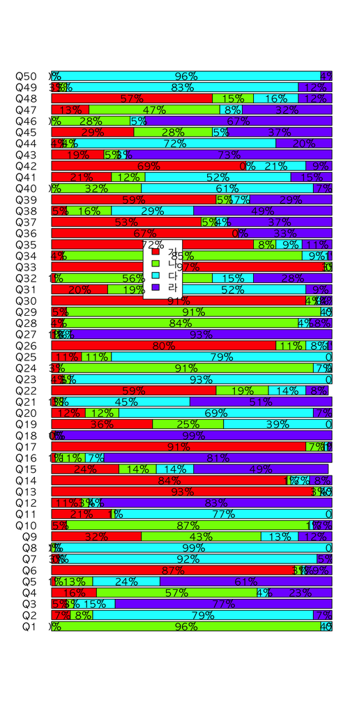

```r
text(x = midterm.tbl[1, ] / 2,
     y = b,
     labels = label.ptbl[1, ])
text(x = midterm.tbl[1, ] + midterm.tbl[2, ] / 2 ,
     y = b,
     labels = label.ptbl[2, ])
text(x = midterm.tbl[1, ] + midterm.tbl[2, ] + midterm.tbl[3, ] / 2,
     y = b,
     labels = label.ptbl[3, ])
text(x = midterm.tbl[1, ] + midterm.tbl[2, ] + midterm.tbl[3, ] + midterm.tbl[4, ]/ 2,
     y = b,
     labels = label.ptbl[4, ])
```

#### 점수

- 정답 맞춰보기
  - 정답 읽어들이기. `what = ""`로 설정하여 `char`취급.

```r
(ans <- scan("../data/statintro_midterm_ans.txt", what = "", encoding = "UTF-8"))
```

```
##  [1] "나" "다" "라" "6"  "라" "가" "다" "다" "나" "나" "다" "라" "가" "가" "라" "라" "가" "라" "가" "다" "라" "가" "다" "나" "다" "가" "라" "나" "나" "가" "다" "나" "가" "나" "가"
## [36] "가" "가" "라" "가" "다" "가" "가" "라" "다" "가" "나" "나" "가" "다" "다"
```

```r
ans[4] <- "나"
```

- 각 학생들의 답안과 맞춰보기 위하여 정답표 작성.
  - 문항별로 정답과 비교하기 위하여 각 문항을 리스트의 원소로 분리
  - `split()` 의 기능과 한계에 유의. `factor` 성격으로부터 `1, 10, 11, ..., 2, 20, ..., 3, 4, 5, ... , 9`로 순서를 잡게 되므로 다시 한번 정리할 필요.

```r
(ans.l <- split(ans,
                f = paste("A", 1:50, sep = "")))
```

```
## $A1
## [1] "나"
##
## $A10
## [1] "나"
##
## $A11
## [1] "다"
##
## $A12
## [1] "라"
##
## $A13
## [1] "가"
##
## $A14
## [1] "가"
##
## $A15
## [1] "라"
##
## $A16
## [1] "라"
##
## $A17
## [1] "가"
##
## $A18
## [1] "라"
##
## $A19
## [1] "가"
##
## $A2
## [1] "다"
##
## $A20
## [1] "다"
##
## $A21
```

[output cut: 94 more lines]

```
##
## $A50
## [1] "다"
##
## $A6
## [1] "가"
##
## $A7
## [1] "다"
##
## $A8
## [1] "다"
##
## $A9
## [1] "나"
```

```r
(ans.l.2 <- ans.l[paste("A", 1:50, sep = "")])
```

```
## $A1
## [1] "나"
##
## $A2
## [1] "다"
##
## $A3
## [1] "라"
##
## $A4
## [1] "나"
##
## $A5
## [1] "라"
##
## $A6
## [1] "가"
##
## $A7
## [1] "다"
##
## $A8
## [1] "다"
##
## $A9
## [1] "나"
##
## $A10
## [1] "나"
##
## $A11
## [1] "다"
##
## $A12
## [1] "라"
##
## $A13
## [1] "가"
##
## $A14
```

[output cut: 94 more lines]

```
##
## $A46
## [1] "나"
##
## $A47
## [1] "나"
##
## $A48
## [1] "가"
##
## $A49
## [1] "다"
##
## $A50
## [1] "다"
```

##### 정답과 대조하여 R(Right)/W(Wrong) 표시

- 채점표라는 의미의 `midterm.marks` 로 저장, (# 표시한 방식으로는 작동하지 않음)

```r
# midterm.marks.rw.q1_3 <- mapply(function(x, y) factor(ifelse(x == y, "R", "W")), y = ans.l.2[1:3], midterm[, 1:3])
midterm.marks.rw <- mapply(function(x, y) factor(ifelse(x == y, "R", "W")), y = ans.l.2, midterm)
# midterm.marks.rw <- mapply(function(x, y = ans.l.2) factor(ifelse(x == y, "R", "W")), midterm[, -26])
# midterm.marks.rw <- sapply(midterm, function(x, y = ans.l.2) factor(ifelse(x == y, "R", "W")))
kable(midterm.marks.rw[, 1:25])
```

| A1 | A2 | A3 | A4 | A5 | A6 | A7 | A8 | A9 | A10 | A11 | A12 | A13 | A14 | A15 | A16 | A17 | A18 | A19 | A20 | A21 | A22 | A23 | A24 | A25 |
| --- | --- | --- | --- | --- | --- | --- | --- | --- | --- | --- | --- | --- | --- | --- | --- | --- | --- | --- | --- | --- | --- | --- | --- | --- |
| R | W | W | W | W | W | R | R | R | R | W | W | W | W | R | W | R | R | W | W | W | W | R | W | W |
| R | R | R | R | R | R | R | R | R | R | R | R | R | R | W | R | R | R | W | R | W | W | R | R | R |
| R | W | W | R | W | R | R | R | W | R | R | R | R | R | R | R | R | R | W | W | W | W | W | R | W |
| R | R | R | W | W | R | R | R | W | R | R | R | R | W | W | R | R | R | W | R | R | R | R | R | R |
| R | R | R | W | W | R | R | R | W | R | W | R | R | R | W | R | R | R | W | W | W | R | R | W | W |
| R | R | R | R | R | R | R | R | W | W | R | R | R | R | R | W | R | R | R | R | R | R | R | R | R |
| R | W | W | W | W | R | R | R | R | R | R | W | R | R | W | R | R | R | R | W | W | R | R | R | W |
| R | R | W | R | R | R | R | R | W | R | R | R | R | W | R | R | R | R | W | R | R | R | R | R | R |
| R | R | R | R | R | W | R | R | R | R | R | W | R | R | R | R | R | R | W | R | R | R | R | R | R |
| R | R | R | R | R | R | R | R | R | R | R | R | R | R | R | R | R | R | W | R | R | R | R | R | R |
| R | R | R | R | R | R | R | R | W | R | R | R | R | R | R | W | R | R | W | R | R | W | R | R | R |
| R | R | R | R | R | R | R | R | R | R | R | W | R | R | R | R | R | R | R | R | R | R | R | R | R |
| R | R | R | R | R | R | R | R | W | R | R | R | R | R | R | R | R | R | W | R | R | R | R | R | R |
| R | W | R | R | W | R | R | R | R | R | R | R | R | R | R | R | R | R | R | R | R | R | R | R | R |
| R | R | R | W | R | R | R | R | R | R | W | R | R | R | R | R | R | R | W | R | R | R | R | R | W |
| R | R | R | W | W | R | W | R | R | R | R | R | R | W | R | R | R | R | W | R | R | W | R | R | R |
| R | R | R | R | R | R | R | R | W | R | R | R | R | W | R | R | R | R | W | R | R | W | R | R | R |
| R | R | R | R | R | R | R | R | R | R | R | W | W | R | W | R | R | R | R | R | R | R | R | R | R |
| R | R | R | W | W | R | R | R | W | R | R | R | R | W | R | R | R | R | W | R | R | R | R | R | R |
| R | W | W | W | W | R | R | R | R | R | R | R | R | R | W | R | R | R | R | R | W | W | W | R | W |
| R | R | W | R | R | R | R | R | W | R | R | W | R | R | W | R | R | R | R | W | W | R | R | R | R |
| R | R | R | R | R | R | R | R | W | R | R | R | R | R | R | R | R | R | W | R | W | R | R | R | R |
| NA | NA | NA | NA | NA | NA | NA | NA | NA | NA | NA | NA | NA | NA | NA | NA | NA | NA | NA | NA | NA | NA | NA | NA | NA |
| R | W | W | W | R | R | R | R | W | R | R | W | R | R | W | R | W | R | R | R | R | R | R | W | R |
| R | W | W | W | W | R | R | R | W | R | W | R | R | R | W | R | R | R | W | W | W | R | R | R | W |
| R | R | R | W | W | R | R | R | R | R | R | W | R | R | W | R | R | R | W | R | W | W | W | R | R |
| R | R | R | R | R | R | R | R | R | R | R | R | R | R | R | R | R | R | W | R | R | R | R | R | R |
| W | R | R | W | R | R | R | R | W | R | R | R | R | R | R | R | R | R | R | R | R | R | R | R | W |
| R | W | R | R | R | R | R | R | W | R | R | R | R | R | W | R | R | R | W | W | W | W | R | R | R |
| R | R | R | R | R | R | R | R | R | W | R | R | R | R | R | R | R | R | R | R | R | R | R | R | R |
| R | R | R | R | R | R | R | R | W | W | R | R | R | R | R | R | R | R | W | W | R | R | R | R | R |
| R | W | R | W | W | R | R | R | W | R | R | R | R | R | W | R | W | R | R | W | R | W | R | R | R |
| W | W | R | R | W | R | R | R | R | W | W | R | R | R | W | R | R | R | R | R | W | W | R | R | R |
| R | W | W | R | R | W | R | R | W | R | W | R | R | R | W | W | R | R | W | W | R | W | R | W | R |
| R | R | R | W | W | R | W | R | W | R | R | R | R | W | R | R | W | R | W | R | W | W | R | W | R |
| W | R | W | W | R | R | R | R | R | R | R | W | R | R | W | W | R | R | W | R | R | R | R | R | W |
| R | R | W | W | W | R | R | R | W | R | R | R | R | R | W | W | R | R | R | R | W | W | W | R | R |
| R | R | R | W | W | R | R | R | W | R | R | R | R | R | R | R | R | R | W | W | W | R | R | R | R |
| R | R | R | R | R | R | R | R | R | R | R | R | R | R | R | R | R | R | R | R | R | R | R | R | R |
| R | R | R | R | R | R | R | R | R | R | R | R | R | R | W | R | R | R | R | R | W | W | R | R | R |
| R | R | R | R | R | R | R | R | R | R | R | R | R | R | W | R | R | R | R | R | R | W | R | R | R |
| R | R | R | W | W | R | R | R | W | R | W | R | R | R | W | W | R | R | R | R | R | R | R | R | R |
| R | R | R | R | R | R | R | R | R | R | R | R | R | R | R | R | R | R | W | R | R | R | W | R | R |
| R | R | W | W | W | R | R | R | W | W | W | R | R | R | NA | R | R | R | W | R | R | R | R | R | W |
| R | R | R | R | R | W | R | R | R | W | W | R | R | R | W | R | R | W | W | R | W | R | R | R | R |
| R | R | R | R | R | R | R | R | W | R | R | R | R | R | W | R | R | R | R | R | R | W | R | R | R |
| R | W | R | R | R | R | R | R | W | R | R | R | R | R | W | R | W | R | R | R | R | R | R | R | R |
| R | W | W | W | W | R | R | R | R | R | R | W | R | W | R | R | W | R | W | R | W | W | R | R | R |
| R | R | R | R | R | R | R | R | W | W | R | R | R | R | R | W | R | R | R | R | W | W | R | R | R |
| R | R | W | R | R | R | R | R | R | R | R | R | R | R | R | W | R | R | W | W | W | R | R | R | W |
| R | R | R | W | R | R | W | R | R | R | R | R | R | R | R | R | R | R | W | W | W | R | R | R | R |
| R | R | R | R | R | R | R | R | W | R | R | R | R | R | R | R | R | R | W | R | R | R | R | R | R |
| R | R | W | W | R | R | R | R | R | R | R | R | R | W | W | R | R | R | R | R | W | W | R | W | W |
| R | W | R | W | W | R | R | R | R | R | W | R | R | R | W | R | W | R | W | W | R | R | R | R | R |
| R | R | R | R | R | W | R | R | W | R | R | W | R | R | W | R | R | R | W | R | W | R | R | R | W |
| R | R | R | R | W | R | R | R | W | R | R | R | W | R | W | R | R | R | W | R | W | R | R | R | R |
| R | W | W | R | W | W | R | W | R | W | W | R | R | R | W | W | R | R | W | W | W | W | R | R | W |
| R | R | R | R | R | R | R | R | R | R | W | R | R | R | R | R | R | R | R | W | R | W | R | R | R |
| R | R | R | W | W | W | R | R | W | R | R | W | R | R | W | R | R | R | W | W | W | W | R | R | R |
| R | R | R | W | W | W | R | R | R | R | R | R | R | W | W | W | R | R | W | W | W | W | R | W | R |
| R | R | R | R | R | R | W | R | W | R | R | R | R | R | R | R | R | R | R | R | R | R | R | R | R |
| R | R | R | R | R | R | W | R | W | R | W | R | R | R | R | W | R | R | W | R | W | W | R | R | R |
| R | R | R | R | R | R | R | R | W | R | R | R | R | R | W | R | R | R | R | R | W | R | R | R | R |
| R | R | R | R | R | R | R | R | W | R | R | R | R | R | W | R | R | R | W | R | R | R | R | R | R |
| R | R | W | R | W | R | R | R | W | R | R | R | R | R | R | R | R | R | R | R | W | W | R | R | R |
| R | R | R | R | R | R | R | R | R | R | R | R | W | R | W | R | R | R | W | R | W | R | R | R | R |
| R | R | R | W | W | R | W | R | W | R | R | R | R | R | R | R | R | R | W | W | W | NA | R | R | R |
| R | R | R | W | R | R | R | R | R | R | R | R | R | R | R | R | R | R | R | R | R | W | R | R | R |
| R | R | R | W | R | R | R | R | W | R | R | R | W | R | W | R | R | R | W | W | W | R | R | R | R |
| R | R | R | R | R | R | R | R | W | R | R | R | R | R | W | R | R | R | R | R | W | R | R | R | R |
| R | R | R | W | W | W | R | R | W | W | W | R | R | W | W | W | R | R | W | W | R | W | R | R | R |
| R | W | R | R | R | W | R | R | R | R | W | R | R | W | W | R | W | R | W | R | R | W | R | R | R |
| R | R | R | W | R | R | R | R | W | R | W | W | R | R | W | R | R | R | W | W | W | W | R | R | W |
| R | R | R | R | R | R | R | R | W | R | W | R | R | R | R | R | R | R | W | R | R | R | R | R | R |
| R | R | R | W | W | R | R | R | W | W | R | R | R | R | R | R | R | R | W | R | W | R | R | R | W |
| R | R | R | W | W | R | R | R | W | R | R | R | R | R | W | W | R | R | W | W | W | R | R | R | R |

```r
kable(midterm.marks.rw[, 26:50])
```

| A26 | A27 | A28 | A29 | A30 | A31 | A32 | A33 | A34 | A35 | A36 | A37 | A38 | A39 | A40 | A41 | A42 | A43 | A44 | A45 | A46 | A47 | A48 | A49 | A50 |
| --- | --- | --- | --- | --- | --- | --- | --- | --- | --- | --- | --- | --- | --- | --- | --- | --- | --- | --- | --- | --- | --- | --- | --- | --- |
| R | R | W | R | W | W | R | R | W | R | R | R | R | W | W | W | W | W | W | W | W | W | W | W | R |
| R | R | R | R | R | R | R | R | R | R | R | R | R | R | R | W | R | R | R | W | R | R | R | R | R |
| W | R | W | R | R | R | R | R | R | R | R | W | R | W | W | R | W | W | W | W | W | W | R | R | R |
| R | R | R | R | R | W | W | R | R | W | R | W | W | R | W | W | R | R | R | W | W | W | W | R | R |
| W | R | R | R | R | W | R | R | R | R | R | W | W | W | R | W | R | W | W | W | R | W | W | W | R |
| R | R | R | R | R | R | W | R | R | R | R | W | R | R | R | W | R | W | R | R | W | R | R | R | R |
| R | R | R | W | W | W | R | R | W | R | W | R | R | R | R | W | R | R | R | R | W | W | R | R | W |
| R | R | R | R | R | W | R | R | R | R | W | R | W | W | R | W | W | W | R | W | W | R | R | R | R |
| R | R | R | R | R | R | R | R | R | R | R | R | R | R | R | W | R | R | R | W | R | R | W | R | R |
| W | R | R | R | R | W | R | R | R | R | R | R | R | R | W | W | R | R | R | W | R | R | R | R | R |
| R | R | R | R | R | W | R | R | R | R | R | R | R | R | R | W | R | R | R | W | W | R | R | R | W |
| R | R | R | R | R | R | R | R | R | R | W | R | R | R | R | W | R | R | R | R | W | R | R | R | R |
| R | R | R | R | R | R | R | R | R | W | R | R | R | R | W | W | R | R | R | R | R | W | R | R | R |
| R | R | R | R | R | R | W | R | R | R | W | R | R | W | R | W | R | R | R | R | W | R | R | R | R |
| R | R | R | R | R | R | W | R | R | R | R | R | R | R | R | W | R | R | R | R | R | W | R | R | R |
| R | R | W | R | R | R | W | R | R | R | W | R | R | W | W | W | R | R | R | W | R | W | R | W | R |
| R | R | R | R | R | W | W | R | R | W | R | W | W | W | W | W | R | R | R | W | R | W | W | R | R |
| R | R | R | R | R | R | R | R | R | R | R | R | R | R | R | W | R | R | R | R | W | R | R | R | R |
| R | R | R | R | R | R | R | R | R | W | W | W | R | R | R | R | R | R | R | W | W | R | R | R | R |
| W | W | W | R | R | R | W | R | R | W | W | R | R | W | W | W | W | R | W | W | W | W | R | W | R |
| R | R | R | R | R | W | W | R | R | W | W | W | R | W | R | W | R | W | R | W | R | W | R | R | R |
| R | R | R | R | R | R | W | R | R | R | R | R | R | R | R | W | R | R | R | W | R | R | R | R | R |
| NA | NA | NA | NA | NA | NA | NA | NA | NA | NA | NA | NA | NA | NA | NA | NA | NA | NA | NA | NA | NA | NA | NA | NA | NA |
| R | W | R | R | W | W | W | R | R | R | W | R | W | R | W | W | R | R | R | W | W | R | W | R | R |
| W | R | R | W | W | W | R | R | R | W | R | R | W | W | W | W | W | R | R | W | R | W | W | W | R |
| R | R | R | R | R | R | R | R | W | W | W | W | R | W | R | W | R | R | R | W | W | R | R | W | R |
| R | R | R | R | R | R | W | R | R | R | R | R | W | R | R | R | R | R | R | R | W | R | R | R | R |
| R | R | R | R | R | W | R | R | W | R | W | R | W | W | R | W | R | R | R | R | R | W | W | R | R |
| R | R | R | R | R | R | R | R | R | R | W | W | W | R | R | W | R | R | R | W | W | W | W | R | R |
| R | R | R | R | R | R | R | R | R | R | W | R | W | R | R | W | R | R | R | R | W | W | R | R | R |
| R | R | R | R | R | W | R | R | R | R | R | W | W | W | R | W | R | R | R | R | W | R | R | R | R |
| W | R | R | R | R | W | R | W | W | R | W | R | W | R | W | W | W | W | W | W | W | R | W | W | R |
| R | R | R | R | R | W | W | R | R | R | R | W | W | R | W | W | R | R | R | R | W | W | W | R | R |
| R | R | R | R | R | W | W | R | R | W | R | R | W | R | W | W | W | W | W | W | W | W | W | W | R |
| R | R | W | R | R | W | R | R | W | R | R | W | W | W | R | W | R | R | R | W | W | R | R | R | R |
| W | R | R | R | R | R | W | W | R | W | R | W | W | W | R | R | R | W | R | W | W | W | W | R | R |
| W | R | R | W | R | R | R | R | W | W | R | R | R | W | W | W | W | W | R | W | W | W | W | R | R |
| R | R | R | R | R | W | W | R | R | R | W | R | R | W | R | R | W | R | R | W | W | R | W | R | R |
| R | R | R | R | R | W | R | R | R | R | R | W | R | R | R | W | R | R | R | R | R | R | R | R | R |
| R | R | W | R | R | R | R | R | R | R | R | W | R | R | R | W | R | R | R | W | W | R | W | R | R |
| R | R | R | R | R | R | R | R | R | R | R | R | R | R | R | R | R | R | R | R | R | R | R | R | R |
| W | R | W | R | R | W | W | R | W | W | R | W | W | R | R | R | R | W | W | R | W | W | R | R | R |
| W | R | W | R | R | R | W | R | R | W | W | W | R | R | R | W | R | R | R | W | W | W | W | R | R |
| W | R | R | R | R | R | W | R | R | W | R | R | R | R | R | R | R | W | R | R | W | R | W | W | R |
| R | W | R | R | R | W | W | R | R | W | W | W | W | W | W | W | R | W | W | W | W | R | R | R | R |
| R | R | R | R | R | W | R | R | R | R | R | R | R | W | R | W | W | R | W | W | R | R | R | W | R |
| W | R | R | R | R | R | R | R | W | R | R | W | W | W | W | R | W | R | W | R | W | W | W | R | R |
| R | R | R | R | W | W | R | R | R | R | W | R | R | R | W | W | R | R | R | W | W | R | W | W | R |
| R | R | R | W | R | W | W | R | R | R | R | W | W | R | R | W | R | R | R | W | W | W | R | R | R |
| R | R | R | R | R | W | R | R | W | R | R | R | W | R | W | W | W | R | R | W | W | W | W | R | R |
| R | R | R | R | R | W | R | R | R | R | R | W | W | R | R | W | R | W | R | W | W | W | R | R | R |
| R | R | R | R | R | R | W | R | R | R | W | R | R | R | R | W | R | R | R | R | W | W | R | R | R |
| R | R | R | W | W | W | W | R | R | W | R | R | W | W | W | R | R | W | W | W | W | R | W | W | R |
| R | R | W | W | R | R | R | R | R | R | W | W | W | R | R | R | W | R | W | W | W | W | W | W | R |
| R | R | W | W | R | R | R | R | R | R | R | R | R | W | W | W | W | R | R | R | R | W | W | R | R |
| R | R | R | R | R | W | W | R | R | R | R | W | W | W | R | R | W | W | W | R | W | W | W | R | R |
| W | W | W | R | R | R | R | R | R | R | W | W | W | W | R | W | W | W | W | W | R | W | W | R | R |
| R | R | R | R | R | W | R | R | R | R | W | R | R | R | W | W | W | R | R | W | W | W | R | R | R |
| R | R | R | R | R | W | R | R | R | R | W | W | R | R | R | W | R | R | W | W | W | R | R | R | R |
| R | R | W | R | R | W | W | R | W | R | R | W | W | W | R | R | W | R | W | W | W | W | W | R | W |
| R | R | R | R | R | R | W | R | R | R | R | R | R | R | R | R | R | R | R | R | R | R | R | R | R |
| R | R | R | R | R | R | R | R | R | W | R | W | W | W | W | W | R | R | R | W | W | W | R | R | R |
| R | R | R | R | R | R | R | R | R | R | R | W | W | W | R | W | R | R | R | W | R | W | R | R | R |
| R | R | R | R | R | R | R | R | R | R | R | W | R | R | W | W | W | W | R | W | W | R | W | R | R |
| R | W | R | R | R | R | R | R | R | W | R | R | R | W | R | W | R | R | W | W | R | R | R | R | R |
| R | R | R | R | R | R | R | R | R | R | R | R | W | R | W | R | W | R | R | W | R | R | W | R | R |
| R | R | R | R | W | R | W | R | R | R | R | W | W | W | W | W | R | R | R | W | W | R | W | R | R |
| R | R | R | R | R | W | W | R | R | R | W | R | R | W | R | R | R | R | R | W | W | R | R | R | R |
| R | R | R | R | R | R | W | R | R | R | R | W | W | R | R | W | R | W | R | W | W | R | R | R | R |
| W | R | R | R | R | W | R | R | R | R | R | R | W | R | R | W | W | R | R | R | W | W | R | R | R |
| R | R | R | R | R | R | R | R | R | W | R | W | W | R | W | W | W | W | W | W | W | W | R | R | R |
| R | R | R | R | R | W | W | R | R | R | R | R | W | W | W | W | R | R | R | W | W | R | R | R | R |
| W | R | R | R | R | W | W | R | R | W | R | R | W | R | W | W | W | R | W | W | W | W | W | R | R |
| R | R | R | R | R | R | W | R | R | R | W | W | W | R | R | W | R | R | W | W | W | W | R | R | R |
| R | R | R | R | R | W | W | R | R | W | R | W | W | R | W | W | R | R | W | W | W | W | W | R | R |
| R | R | R | R | R | R | W | R | R | R | R | W | R | R | R | W | R | R | R | W | W | W | R | R | R |

##### 학생별 점수 산출

```r
midterm.marks <- ifelse(midterm.marks.rw == "R", 1, 0)
kable(midterm.marks[, 1:25])
```

| A1 | A2 | A3 | A4 | A5 | A6 | A7 | A8 | A9 | A10 | A11 | A12 | A13 | A14 | A15 | A16 | A17 | A18 | A19 | A20 | A21 | A22 | A23 | A24 | A25 |
| --- | --- | --- | --- | --- | --- | --- | --- | --- | --- | --- | --- | --- | --- | --- | --- | --- | --- | --- | --- | --- | --- | --- | --- | --- |
| 1 | 0 | 0 | 0 | 0 | 0 | 1 | 1 | 1 | 1 | 0 | 0 | 0 | 0 | 1 | 0 | 1 | 1 | 0 | 0 | 0 | 0 | 1 | 0 | 0 |
| 1 | 1 | 1 | 1 | 1 | 1 | 1 | 1 | 1 | 1 | 1 | 1 | 1 | 1 | 0 | 1 | 1 | 1 | 0 | 1 | 0 | 0 | 1 | 1 | 1 |
| 1 | 0 | 0 | 1 | 0 | 1 | 1 | 1 | 0 | 1 | 1 | 1 | 1 | 1 | 1 | 1 | 1 | 1 | 0 | 0 | 0 | 0 | 0 | 1 | 0 |
| 1 | 1 | 1 | 0 | 0 | 1 | 1 | 1 | 0 | 1 | 1 | 1 | 1 | 0 | 0 | 1 | 1 | 1 | 0 | 1 | 1 | 1 | 1 | 1 | 1 |
| 1 | 1 | 1 | 0 | 0 | 1 | 1 | 1 | 0 | 1 | 0 | 1 | 1 | 1 | 0 | 1 | 1 | 1 | 0 | 0 | 0 | 1 | 1 | 0 | 0 |
| 1 | 1 | 1 | 1 | 1 | 1 | 1 | 1 | 0 | 0 | 1 | 1 | 1 | 1 | 1 | 0 | 1 | 1 | 1 | 1 | 1 | 1 | 1 | 1 | 1 |
| 1 | 0 | 0 | 0 | 0 | 1 | 1 | 1 | 1 | 1 | 1 | 0 | 1 | 1 | 0 | 1 | 1 | 1 | 1 | 0 | 0 | 1 | 1 | 1 | 0 |
| 1 | 1 | 0 | 1 | 1 | 1 | 1 | 1 | 0 | 1 | 1 | 1 | 1 | 0 | 1 | 1 | 1 | 1 | 0 | 1 | 1 | 1 | 1 | 1 | 1 |
| 1 | 1 | 1 | 1 | 1 | 0 | 1 | 1 | 1 | 1 | 1 | 0 | 1 | 1 | 1 | 1 | 1 | 1 | 0 | 1 | 1 | 1 | 1 | 1 | 1 |
| 1 | 1 | 1 | 1 | 1 | 1 | 1 | 1 | 1 | 1 | 1 | 1 | 1 | 1 | 1 | 1 | 1 | 1 | 0 | 1 | 1 | 1 | 1 | 1 | 1 |
| 1 | 1 | 1 | 1 | 1 | 1 | 1 | 1 | 0 | 1 | 1 | 1 | 1 | 1 | 1 | 0 | 1 | 1 | 0 | 1 | 1 | 0 | 1 | 1 | 1 |
| 1 | 1 | 1 | 1 | 1 | 1 | 1 | 1 | 1 | 1 | 1 | 0 | 1 | 1 | 1 | 1 | 1 | 1 | 1 | 1 | 1 | 1 | 1 | 1 | 1 |
| 1 | 1 | 1 | 1 | 1 | 1 | 1 | 1 | 0 | 1 | 1 | 1 | 1 | 1 | 1 | 1 | 1 | 1 | 0 | 1 | 1 | 1 | 1 | 1 | 1 |
| 1 | 0 | 1 | 1 | 0 | 1 | 1 | 1 | 1 | 1 | 1 | 1 | 1 | 1 | 1 | 1 | 1 | 1 | 1 | 1 | 1 | 1 | 1 | 1 | 1 |
| 1 | 1 | 1 | 0 | 1 | 1 | 1 | 1 | 1 | 1 | 0 | 1 | 1 | 1 | 1 | 1 | 1 | 1 | 0 | 1 | 1 | 1 | 1 | 1 | 0 |
| 1 | 1 | 1 | 0 | 0 | 1 | 0 | 1 | 1 | 1 | 1 | 1 | 1 | 0 | 1 | 1 | 1 | 1 | 0 | 1 | 1 | 0 | 1 | 1 | 1 |
| 1 | 1 | 1 | 1 | 1 | 1 | 1 | 1 | 0 | 1 | 1 | 1 | 1 | 0 | 1 | 1 | 1 | 1 | 0 | 1 | 1 | 0 | 1 | 1 | 1 |
| 1 | 1 | 1 | 1 | 1 | 1 | 1 | 1 | 1 | 1 | 1 | 0 | 0 | 1 | 0 | 1 | 1 | 1 | 1 | 1 | 1 | 1 | 1 | 1 | 1 |
| 1 | 1 | 1 | 0 | 0 | 1 | 1 | 1 | 0 | 1 | 1 | 1 | 1 | 0 | 1 | 1 | 1 | 1 | 0 | 1 | 1 | 1 | 1 | 1 | 1 |
| 1 | 0 | 0 | 0 | 0 | 1 | 1 | 1 | 1 | 1 | 1 | 1 | 1 | 1 | 0 | 1 | 1 | 1 | 1 | 1 | 0 | 0 | 0 | 1 | 0 |
| 1 | 1 | 0 | 1 | 1 | 1 | 1 | 1 | 0 | 1 | 1 | 0 | 1 | 1 | 0 | 1 | 1 | 1 | 1 | 0 | 0 | 1 | 1 | 1 | 1 |
| 1 | 1 | 1 | 1 | 1 | 1 | 1 | 1 | 0 | 1 | 1 | 1 | 1 | 1 | 1 | 1 | 1 | 1 | 0 | 1 | 0 | 1 | 1 | 1 | 1 |
| NA | NA | NA | NA | NA | NA | NA | NA | NA | NA | NA | NA | NA | NA | NA | NA | NA | NA | NA | NA | NA | NA | NA | NA | NA |
| 1 | 0 | 0 | 0 | 1 | 1 | 1 | 1 | 0 | 1 | 1 | 0 | 1 | 1 | 0 | 1 | 0 | 1 | 1 | 1 | 1 | 1 | 1 | 0 | 1 |
| 1 | 0 | 0 | 0 | 0 | 1 | 1 | 1 | 0 | 1 | 0 | 1 | 1 | 1 | 0 | 1 | 1 | 1 | 0 | 0 | 0 | 1 | 1 | 1 | 0 |
| 1 | 1 | 1 | 0 | 0 | 1 | 1 | 1 | 1 | 1 | 1 | 0 | 1 | 1 | 0 | 1 | 1 | 1 | 0 | 1 | 0 | 0 | 0 | 1 | 1 |
| 1 | 1 | 1 | 1 | 1 | 1 | 1 | 1 | 1 | 1 | 1 | 1 | 1 | 1 | 1 | 1 | 1 | 1 | 0 | 1 | 1 | 1 | 1 | 1 | 1 |
| 0 | 1 | 1 | 0 | 1 | 1 | 1 | 1 | 0 | 1 | 1 | 1 | 1 | 1 | 1 | 1 | 1 | 1 | 1 | 1 | 1 | 1 | 1 | 1 | 0 |
| 1 | 0 | 1 | 1 | 1 | 1 | 1 | 1 | 0 | 1 | 1 | 1 | 1 | 1 | 0 | 1 | 1 | 1 | 0 | 0 | 0 | 0 | 1 | 1 | 1 |
| 1 | 1 | 1 | 1 | 1 | 1 | 1 | 1 | 1 | 0 | 1 | 1 | 1 | 1 | 1 | 1 | 1 | 1 | 1 | 1 | 1 | 1 | 1 | 1 | 1 |
| 1 | 1 | 1 | 1 | 1 | 1 | 1 | 1 | 0 | 0 | 1 | 1 | 1 | 1 | 1 | 1 | 1 | 1 | 0 | 0 | 1 | 1 | 1 | 1 | 1 |
| 1 | 0 | 1 | 0 | 0 | 1 | 1 | 1 | 0 | 1 | 1 | 1 | 1 | 1 | 0 | 1 | 0 | 1 | 1 | 0 | 1 | 0 | 1 | 1 | 1 |
| 0 | 0 | 1 | 1 | 0 | 1 | 1 | 1 | 1 | 0 | 0 | 1 | 1 | 1 | 0 | 1 | 1 | 1 | 1 | 1 | 0 | 0 | 1 | 1 | 1 |
| 1 | 0 | 0 | 1 | 1 | 0 | 1 | 1 | 0 | 1 | 0 | 1 | 1 | 1 | 0 | 0 | 1 | 1 | 0 | 0 | 1 | 0 | 1 | 0 | 1 |
| 1 | 1 | 1 | 0 | 0 | 1 | 0 | 1 | 0 | 1 | 1 | 1 | 1 | 0 | 1 | 1 | 0 | 1 | 0 | 1 | 0 | 0 | 1 | 0 | 1 |
| 0 | 1 | 0 | 0 | 1 | 1 | 1 | 1 | 1 | 1 | 1 | 0 | 1 | 1 | 0 | 0 | 1 | 1 | 0 | 1 | 1 | 1 | 1 | 1 | 0 |
| 1 | 1 | 0 | 0 | 0 | 1 | 1 | 1 | 0 | 1 | 1 | 1 | 1 | 1 | 0 | 0 | 1 | 1 | 1 | 1 | 0 | 0 | 0 | 1 | 1 |
| 1 | 1 | 1 | 0 | 0 | 1 | 1 | 1 | 0 | 1 | 1 | 1 | 1 | 1 | 1 | 1 | 1 | 1 | 0 | 0 | 0 | 1 | 1 | 1 | 1 |
| 1 | 1 | 1 | 1 | 1 | 1 | 1 | 1 | 1 | 1 | 1 | 1 | 1 | 1 | 1 | 1 | 1 | 1 | 1 | 1 | 1 | 1 | 1 | 1 | 1 |
| 1 | 1 | 1 | 1 | 1 | 1 | 1 | 1 | 1 | 1 | 1 | 1 | 1 | 1 | 0 | 1 | 1 | 1 | 1 | 1 | 0 | 0 | 1 | 1 | 1 |
| 1 | 1 | 1 | 1 | 1 | 1 | 1 | 1 | 1 | 1 | 1 | 1 | 1 | 1 | 0 | 1 | 1 | 1 | 1 | 1 | 1 | 0 | 1 | 1 | 1 |
| 1 | 1 | 1 | 0 | 0 | 1 | 1 | 1 | 0 | 1 | 0 | 1 | 1 | 1 | 0 | 0 | 1 | 1 | 1 | 1 | 1 | 1 | 1 | 1 | 1 |
| 1 | 1 | 1 | 1 | 1 | 1 | 1 | 1 | 1 | 1 | 1 | 1 | 1 | 1 | 1 | 1 | 1 | 1 | 0 | 1 | 1 | 1 | 0 | 1 | 1 |
| 1 | 1 | 0 | 0 | 0 | 1 | 1 | 1 | 0 | 0 | 0 | 1 | 1 | 1 | NA | 1 | 1 | 1 | 0 | 1 | 1 | 1 | 1 | 1 | 0 |
| 1 | 1 | 1 | 1 | 1 | 0 | 1 | 1 | 1 | 0 | 0 | 1 | 1 | 1 | 0 | 1 | 1 | 0 | 0 | 1 | 0 | 1 | 1 | 1 | 1 |
| 1 | 1 | 1 | 1 | 1 | 1 | 1 | 1 | 0 | 1 | 1 | 1 | 1 | 1 | 0 | 1 | 1 | 1 | 1 | 1 | 1 | 0 | 1 | 1 | 1 |
| 1 | 0 | 1 | 1 | 1 | 1 | 1 | 1 | 0 | 1 | 1 | 1 | 1 | 1 | 0 | 1 | 0 | 1 | 1 | 1 | 1 | 1 | 1 | 1 | 1 |
| 1 | 0 | 0 | 0 | 0 | 1 | 1 | 1 | 1 | 1 | 1 | 0 | 1 | 0 | 1 | 1 | 0 | 1 | 0 | 1 | 0 | 0 | 1 | 1 | 1 |
| 1 | 1 | 1 | 1 | 1 | 1 | 1 | 1 | 0 | 0 | 1 | 1 | 1 | 1 | 1 | 0 | 1 | 1 | 1 | 1 | 0 | 0 | 1 | 1 | 1 |
| 1 | 1 | 0 | 1 | 1 | 1 | 1 | 1 | 1 | 1 | 1 | 1 | 1 | 1 | 1 | 0 | 1 | 1 | 0 | 0 | 0 | 1 | 1 | 1 | 0 |
| 1 | 1 | 1 | 0 | 1 | 1 | 0 | 1 | 1 | 1 | 1 | 1 | 1 | 1 | 1 | 1 | 1 | 1 | 0 | 0 | 0 | 1 | 1 | 1 | 1 |
| 1 | 1 | 1 | 1 | 1 | 1 | 1 | 1 | 0 | 1 | 1 | 1 | 1 | 1 | 1 | 1 | 1 | 1 | 0 | 1 | 1 | 1 | 1 | 1 | 1 |
| 1 | 1 | 0 | 0 | 1 | 1 | 1 | 1 | 1 | 1 | 1 | 1 | 1 | 0 | 0 | 1 | 1 | 1 | 1 | 1 | 0 | 0 | 1 | 0 | 0 |
| 1 | 0 | 1 | 0 | 0 | 1 | 1 | 1 | 1 | 1 | 0 | 1 | 1 | 1 | 0 | 1 | 0 | 1 | 0 | 0 | 1 | 1 | 1 | 1 | 1 |
| 1 | 1 | 1 | 1 | 1 | 0 | 1 | 1 | 0 | 1 | 1 | 0 | 1 | 1 | 0 | 1 | 1 | 1 | 0 | 1 | 0 | 1 | 1 | 1 | 0 |
| 1 | 1 | 1 | 1 | 0 | 1 | 1 | 1 | 0 | 1 | 1 | 1 | 0 | 1 | 0 | 1 | 1 | 1 | 0 | 1 | 0 | 1 | 1 | 1 | 1 |
| 1 | 0 | 0 | 1 | 0 | 0 | 1 | 0 | 1 | 0 | 0 | 1 | 1 | 1 | 0 | 0 | 1 | 1 | 0 | 0 | 0 | 0 | 1 | 1 | 0 |
| 1 | 1 | 1 | 1 | 1 | 1 | 1 | 1 | 1 | 1 | 0 | 1 | 1 | 1 | 1 | 1 | 1 | 1 | 1 | 0 | 1 | 0 | 1 | 1 | 1 |
| 1 | 1 | 1 | 0 | 0 | 0 | 1 | 1 | 0 | 1 | 1 | 0 | 1 | 1 | 0 | 1 | 1 | 1 | 0 | 0 | 0 | 0 | 1 | 1 | 1 |
| 1 | 1 | 1 | 0 | 0 | 0 | 1 | 1 | 1 | 1 | 1 | 1 | 1 | 0 | 0 | 0 | 1 | 1 | 0 | 0 | 0 | 0 | 1 | 0 | 1 |
| 1 | 1 | 1 | 1 | 1 | 1 | 0 | 1 | 0 | 1 | 1 | 1 | 1 | 1 | 1 | 1 | 1 | 1 | 1 | 1 | 1 | 1 | 1 | 1 | 1 |
| 1 | 1 | 1 | 1 | 1 | 1 | 0 | 1 | 0 | 1 | 0 | 1 | 1 | 1 | 1 | 0 | 1 | 1 | 0 | 1 | 0 | 0 | 1 | 1 | 1 |
| 1 | 1 | 1 | 1 | 1 | 1 | 1 | 1 | 0 | 1 | 1 | 1 | 1 | 1 | 0 | 1 | 1 | 1 | 1 | 1 | 0 | 1 | 1 | 1 | 1 |
| 1 | 1 | 1 | 1 | 1 | 1 | 1 | 1 | 0 | 1 | 1 | 1 | 1 | 1 | 0 | 1 | 1 | 1 | 0 | 1 | 1 | 1 | 1 | 1 | 1 |
| 1 | 1 | 0 | 1 | 0 | 1 | 1 | 1 | 0 | 1 | 1 | 1 | 1 | 1 | 1 | 1 | 1 | 1 | 1 | 1 | 0 | 0 | 1 | 1 | 1 |
| 1 | 1 | 1 | 1 | 1 | 1 | 1 | 1 | 1 | 1 | 1 | 1 | 0 | 1 | 0 | 1 | 1 | 1 | 0 | 1 | 0 | 1 | 1 | 1 | 1 |
| 1 | 1 | 1 | 0 | 0 | 1 | 0 | 1 | 0 | 1 | 1 | 1 | 1 | 1 | 1 | 1 | 1 | 1 | 0 | 0 | 0 | NA | 1 | 1 | 1 |
| 1 | 1 | 1 | 0 | 1 | 1 | 1 | 1 | 1 | 1 | 1 | 1 | 1 | 1 | 1 | 1 | 1 | 1 | 1 | 1 | 1 | 0 | 1 | 1 | 1 |
| 1 | 1 | 1 | 0 | 1 | 1 | 1 | 1 | 0 | 1 | 1 | 1 | 0 | 1 | 0 | 1 | 1 | 1 | 0 | 0 | 0 | 1 | 1 | 1 | 1 |
| 1 | 1 | 1 | 1 | 1 | 1 | 1 | 1 | 0 | 1 | 1 | 1 | 1 | 1 | 0 | 1 | 1 | 1 | 1 | 1 | 0 | 1 | 1 | 1 | 1 |
| 1 | 1 | 1 | 0 | 0 | 0 | 1 | 1 | 0 | 0 | 0 | 1 | 1 | 0 | 0 | 0 | 1 | 1 | 0 | 0 | 1 | 0 | 1 | 1 | 1 |
| 1 | 0 | 1 | 1 | 1 | 0 | 1 | 1 | 1 | 1 | 0 | 1 | 1 | 0 | 0 | 1 | 0 | 1 | 0 | 1 | 1 | 0 | 1 | 1 | 1 |
| 1 | 1 | 1 | 0 | 1 | 1 | 1 | 1 | 0 | 1 | 0 | 0 | 1 | 1 | 0 | 1 | 1 | 1 | 0 | 0 | 0 | 0 | 1 | 1 | 0 |
| 1 | 1 | 1 | 1 | 1 | 1 | 1 | 1 | 0 | 1 | 0 | 1 | 1 | 1 | 1 | 1 | 1 | 1 | 0 | 1 | 1 | 1 | 1 | 1 | 1 |
| 1 | 1 | 1 | 0 | 0 | 1 | 1 | 1 | 0 | 0 | 1 | 1 | 1 | 1 | 1 | 1 | 1 | 1 | 0 | 1 | 0 | 1 | 1 | 1 | 0 |
| 1 | 1 | 1 | 0 | 0 | 1 | 1 | 1 | 0 | 1 | 1 | 1 | 1 | 1 | 0 | 0 | 1 | 1 | 0 | 0 | 0 | 1 | 1 | 1 | 1 |

```r
kable(midterm.marks[, 26:50])
```

| A26 | A27 | A28 | A29 | A30 | A31 | A32 | A33 | A34 | A35 | A36 | A37 | A38 | A39 | A40 | A41 | A42 | A43 | A44 | A45 | A46 | A47 | A48 | A49 | A50 |
| --- | --- | --- | --- | --- | --- | --- | --- | --- | --- | --- | --- | --- | --- | --- | --- | --- | --- | --- | --- | --- | --- | --- | --- | --- |
| 1 | 1 | 0 | 1 | 0 | 0 | 1 | 1 | 0 | 1 | 1 | 1 | 1 | 0 | 0 | 0 | 0 | 0 | 0 | 0 | 0 | 0 | 0 | 0 | 1 |
| 1 | 1 | 1 | 1 | 1 | 1 | 1 | 1 | 1 | 1 | 1 | 1 | 1 | 1 | 1 | 0 | 1 | 1 | 1 | 0 | 1 | 1 | 1 | 1 | 1 |
| 0 | 1 | 0 | 1 | 1 | 1 | 1 | 1 | 1 | 1 | 1 | 0 | 1 | 0 | 0 | 1 | 0 | 0 | 0 | 0 | 0 | 0 | 1 | 1 | 1 |
| 1 | 1 | 1 | 1 | 1 | 0 | 0 | 1 | 1 | 0 | 1 | 0 | 0 | 1 | 0 | 0 | 1 | 1 | 1 | 0 | 0 | 0 | 0 | 1 | 1 |
| 0 | 1 | 1 | 1 | 1 | 0 | 1 | 1 | 1 | 1 | 1 | 0 | 0 | 0 | 1 | 0 | 1 | 0 | 0 | 0 | 1 | 0 | 0 | 0 | 1 |
| 1 | 1 | 1 | 1 | 1 | 1 | 0 | 1 | 1 | 1 | 1 | 0 | 1 | 1 | 1 | 0 | 1 | 0 | 1 | 1 | 0 | 1 | 1 | 1 | 1 |
| 1 | 1 | 1 | 0 | 0 | 0 | 1 | 1 | 0 | 1 | 0 | 1 | 1 | 1 | 1 | 0 | 1 | 1 | 1 | 1 | 0 | 0 | 1 | 1 | 0 |
| 1 | 1 | 1 | 1 | 1 | 0 | 1 | 1 | 1 | 1 | 0 | 1 | 0 | 0 | 1 | 0 | 0 | 0 | 1 | 0 | 0 | 1 | 1 | 1 | 1 |
| 1 | 1 | 1 | 1 | 1 | 1 | 1 | 1 | 1 | 1 | 1 | 1 | 1 | 1 | 1 | 0 | 1 | 1 | 1 | 0 | 1 | 1 | 0 | 1 | 1 |
| 0 | 1 | 1 | 1 | 1 | 0 | 1 | 1 | 1 | 1 | 1 | 1 | 1 | 1 | 0 | 0 | 1 | 1 | 1 | 0 | 1 | 1 | 1 | 1 | 1 |
| 1 | 1 | 1 | 1 | 1 | 0 | 1 | 1 | 1 | 1 | 1 | 1 | 1 | 1 | 1 | 0 | 1 | 1 | 1 | 0 | 0 | 1 | 1 | 1 | 0 |
| 1 | 1 | 1 | 1 | 1 | 1 | 1 | 1 | 1 | 1 | 0 | 1 | 1 | 1 | 1 | 0 | 1 | 1 | 1 | 1 | 0 | 1 | 1 | 1 | 1 |
| 1 | 1 | 1 | 1 | 1 | 1 | 1 | 1 | 1 | 0 | 1 | 1 | 1 | 1 | 0 | 0 | 1 | 1 | 1 | 1 | 1 | 0 | 1 | 1 | 1 |
| 1 | 1 | 1 | 1 | 1 | 1 | 0 | 1 | 1 | 1 | 0 | 1 | 1 | 0 | 1 | 0 | 1 | 1 | 1 | 1 | 0 | 1 | 1 | 1 | 1 |
| 1 | 1 | 1 | 1 | 1 | 1 | 0 | 1 | 1 | 1 | 1 | 1 | 1 | 1 | 1 | 0 | 1 | 1 | 1 | 1 | 1 | 0 | 1 | 1 | 1 |
| 1 | 1 | 0 | 1 | 1 | 1 | 0 | 1 | 1 | 1 | 0 | 1 | 1 | 0 | 0 | 0 | 1 | 1 | 1 | 0 | 1 | 0 | 1 | 0 | 1 |
| 1 | 1 | 1 | 1 | 1 | 0 | 0 | 1 | 1 | 0 | 1 | 0 | 0 | 0 | 0 | 0 | 1 | 1 | 1 | 0 | 1 | 0 | 0 | 1 | 1 |
| 1 | 1 | 1 | 1 | 1 | 1 | 1 | 1 | 1 | 1 | 1 | 1 | 1 | 1 | 1 | 0 | 1 | 1 | 1 | 1 | 0 | 1 | 1 | 1 | 1 |
| 1 | 1 | 1 | 1 | 1 | 1 | 1 | 1 | 1 | 0 | 0 | 0 | 1 | 1 | 1 | 1 | 1 | 1 | 1 | 0 | 0 | 1 | 1 | 1 | 1 |
| 0 | 0 | 0 | 1 | 1 | 1 | 0 | 1 | 1 | 0 | 0 | 1 | 1 | 0 | 0 | 0 | 0 | 1 | 0 | 0 | 0 | 0 | 1 | 0 | 1 |
| 1 | 1 | 1 | 1 | 1 | 0 | 0 | 1 | 1 | 0 | 0 | 0 | 1 | 0 | 1 | 0 | 1 | 0 | 1 | 0 | 1 | 0 | 1 | 1 | 1 |
| 1 | 1 | 1 | 1 | 1 | 1 | 0 | 1 | 1 | 1 | 1 | 1 | 1 | 1 | 1 | 0 | 1 | 1 | 1 | 0 | 1 | 1 | 1 | 1 | 1 |
| NA | NA | NA | NA | NA | NA | NA | NA | NA | NA | NA | NA | NA | NA | NA | NA | NA | NA | NA | NA | NA | NA | NA | NA | NA |
| 1 | 0 | 1 | 1 | 0 | 0 | 0 | 1 | 1 | 1 | 0 | 1 | 0 | 1 | 0 | 0 | 1 | 1 | 1 | 0 | 0 | 1 | 0 | 1 | 1 |
| 0 | 1 | 1 | 0 | 0 | 0 | 1 | 1 | 1 | 0 | 1 | 1 | 0 | 0 | 0 | 0 | 0 | 1 | 1 | 0 | 1 | 0 | 0 | 0 | 1 |
| 1 | 1 | 1 | 1 | 1 | 1 | 1 | 1 | 0 | 0 | 0 | 0 | 1 | 0 | 1 | 0 | 1 | 1 | 1 | 0 | 0 | 1 | 1 | 0 | 1 |
| 1 | 1 | 1 | 1 | 1 | 1 | 0 | 1 | 1 | 1 | 1 | 1 | 0 | 1 | 1 | 1 | 1 | 1 | 1 | 1 | 0 | 1 | 1 | 1 | 1 |
| 1 | 1 | 1 | 1 | 1 | 0 | 1 | 1 | 0 | 1 | 0 | 1 | 0 | 0 | 1 | 0 | 1 | 1 | 1 | 1 | 1 | 0 | 0 | 1 | 1 |
| 1 | 1 | 1 | 1 | 1 | 1 | 1 | 1 | 1 | 1 | 0 | 0 | 0 | 1 | 1 | 0 | 1 | 1 | 1 | 0 | 0 | 0 | 0 | 1 | 1 |
| 1 | 1 | 1 | 1 | 1 | 1 | 1 | 1 | 1 | 1 | 0 | 1 | 0 | 1 | 1 | 0 | 1 | 1 | 1 | 1 | 0 | 0 | 1 | 1 | 1 |
| 1 | 1 | 1 | 1 | 1 | 0 | 1 | 1 | 1 | 1 | 1 | 0 | 0 | 0 | 1 | 0 | 1 | 1 | 1 | 1 | 0 | 1 | 1 | 1 | 1 |
| 0 | 1 | 1 | 1 | 1 | 0 | 1 | 0 | 0 | 1 | 0 | 1 | 0 | 1 | 0 | 0 | 0 | 0 | 0 | 0 | 0 | 1 | 0 | 0 | 1 |
| 1 | 1 | 1 | 1 | 1 | 0 | 0 | 1 | 1 | 1 | 1 | 0 | 0 | 1 | 0 | 0 | 1 | 1 | 1 | 1 | 0 | 0 | 0 | 1 | 1 |
| 1 | 1 | 1 | 1 | 1 | 0 | 0 | 1 | 1 | 0 | 1 | 1 | 0 | 1 | 0 | 0 | 0 | 0 | 0 | 0 | 0 | 0 | 0 | 0 | 1 |
| 1 | 1 | 0 | 1 | 1 | 0 | 1 | 1 | 0 | 1 | 1 | 0 | 0 | 0 | 1 | 0 | 1 | 1 | 1 | 0 | 0 | 1 | 1 | 1 | 1 |
| 0 | 1 | 1 | 1 | 1 | 1 | 0 | 0 | 1 | 0 | 1 | 0 | 0 | 0 | 1 | 1 | 1 | 0 | 1 | 0 | 0 | 0 | 0 | 1 | 1 |
| 0 | 1 | 1 | 0 | 1 | 1 | 1 | 1 | 0 | 0 | 1 | 1 | 1 | 0 | 0 | 0 | 0 | 0 | 1 | 0 | 0 | 0 | 0 | 1 | 1 |
| 1 | 1 | 1 | 1 | 1 | 0 | 0 | 1 | 1 | 1 | 0 | 1 | 1 | 0 | 1 | 1 | 0 | 1 | 1 | 0 | 0 | 1 | 0 | 1 | 1 |
| 1 | 1 | 1 | 1 | 1 | 0 | 1 | 1 | 1 | 1 | 1 | 0 | 1 | 1 | 1 | 0 | 1 | 1 | 1 | 1 | 1 | 1 | 1 | 1 | 1 |
| 1 | 1 | 0 | 1 | 1 | 1 | 1 | 1 | 1 | 1 | 1 | 0 | 1 | 1 | 1 | 0 | 1 | 1 | 1 | 0 | 0 | 1 | 0 | 1 | 1 |
| 1 | 1 | 1 | 1 | 1 | 1 | 1 | 1 | 1 | 1 | 1 | 1 | 1 | 1 | 1 | 1 | 1 | 1 | 1 | 1 | 1 | 1 | 1 | 1 | 1 |
| 0 | 1 | 0 | 1 | 1 | 0 | 0 | 1 | 0 | 0 | 1 | 0 | 0 | 1 | 1 | 1 | 1 | 0 | 0 | 1 | 0 | 0 | 1 | 1 | 1 |
| 0 | 1 | 0 | 1 | 1 | 1 | 0 | 1 | 1 | 0 | 0 | 0 | 1 | 1 | 1 | 0 | 1 | 1 | 1 | 0 | 0 | 0 | 0 | 1 | 1 |
| 0 | 1 | 1 | 1 | 1 | 1 | 0 | 1 | 1 | 0 | 1 | 1 | 1 | 1 | 1 | 1 | 1 | 0 | 1 | 1 | 0 | 1 | 0 | 0 | 1 |
| 1 | 0 | 1 | 1 | 1 | 0 | 0 | 1 | 1 | 0 | 0 | 0 | 0 | 0 | 0 | 0 | 1 | 0 | 0 | 0 | 0 | 1 | 1 | 1 | 1 |
| 1 | 1 | 1 | 1 | 1 | 0 | 1 | 1 | 1 | 1 | 1 | 1 | 1 | 0 | 1 | 0 | 0 | 1 | 0 | 0 | 1 | 1 | 1 | 0 | 1 |
| 0 | 1 | 1 | 1 | 1 | 1 | 1 | 1 | 0 | 1 | 1 | 0 | 0 | 0 | 0 | 1 | 0 | 1 | 0 | 1 | 0 | 0 | 0 | 1 | 1 |
| 1 | 1 | 1 | 1 | 0 | 0 | 1 | 1 | 1 | 1 | 0 | 1 | 1 | 1 | 0 | 0 | 1 | 1 | 1 | 0 | 0 | 1 | 0 | 0 | 1 |
| 1 | 1 | 1 | 0 | 1 | 0 | 0 | 1 | 1 | 1 | 1 | 0 | 0 | 1 | 1 | 0 | 1 | 1 | 1 | 0 | 0 | 0 | 1 | 1 | 1 |
| 1 | 1 | 1 | 1 | 1 | 0 | 1 | 1 | 0 | 1 | 1 | 1 | 0 | 1 | 0 | 0 | 0 | 1 | 1 | 0 | 0 | 0 | 0 | 1 | 1 |
| 1 | 1 | 1 | 1 | 1 | 0 | 1 | 1 | 1 | 1 | 1 | 0 | 0 | 1 | 1 | 0 | 1 | 0 | 1 | 0 | 0 | 0 | 1 | 1 | 1 |
| 1 | 1 | 1 | 1 | 1 | 1 | 0 | 1 | 1 | 1 | 0 | 1 | 1 | 1 | 1 | 0 | 1 | 1 | 1 | 1 | 0 | 0 | 1 | 1 | 1 |
| 1 | 1 | 1 | 0 | 0 | 0 | 0 | 1 | 1 | 0 | 1 | 1 | 0 | 0 | 0 | 1 | 1 | 0 | 0 | 0 | 0 | 1 | 0 | 0 | 1 |
| 1 | 1 | 0 | 0 | 1 | 1 | 1 | 1 | 1 | 1 | 0 | 0 | 0 | 1 | 1 | 1 | 0 | 1 | 0 | 0 | 0 | 0 | 0 | 0 | 1 |
| 1 | 1 | 0 | 0 | 1 | 1 | 1 | 1 | 1 | 1 | 1 | 1 | 1 | 0 | 0 | 0 | 0 | 1 | 1 | 1 | 1 | 0 | 0 | 1 | 1 |
| 1 | 1 | 1 | 1 | 1 | 0 | 0 | 1 | 1 | 1 | 1 | 0 | 0 | 0 | 1 | 1 | 0 | 0 | 0 | 1 | 0 | 0 | 0 | 1 | 1 |
| 0 | 0 | 0 | 1 | 1 | 1 | 1 | 1 | 1 | 1 | 0 | 0 | 0 | 0 | 1 | 0 | 0 | 0 | 0 | 0 | 1 | 0 | 0 | 1 | 1 |
| 1 | 1 | 1 | 1 | 1 | 0 | 1 | 1 | 1 | 1 | 0 | 1 | 1 | 1 | 0 | 0 | 0 | 1 | 1 | 0 | 0 | 0 | 1 | 1 | 1 |
| 1 | 1 | 1 | 1 | 1 | 0 | 1 | 1 | 1 | 1 | 0 | 0 | 1 | 1 | 1 | 0 | 1 | 1 | 0 | 0 | 0 | 1 | 1 | 1 | 1 |
| 1 | 1 | 0 | 1 | 1 | 0 | 0 | 1 | 0 | 1 | 1 | 0 | 0 | 0 | 1 | 1 | 0 | 1 | 0 | 0 | 0 | 0 | 0 | 1 | 0 |
| 1 | 1 | 1 | 1 | 1 | 1 | 0 | 1 | 1 | 1 | 1 | 1 | 1 | 1 | 1 | 1 | 1 | 1 | 1 | 1 | 1 | 1 | 1 | 1 | 1 |
| 1 | 1 | 1 | 1 | 1 | 1 | 1 | 1 | 1 | 0 | 1 | 0 | 0 | 0 | 0 | 0 | 1 | 1 | 1 | 0 | 0 | 0 | 1 | 1 | 1 |
| 1 | 1 | 1 | 1 | 1 | 1 | 1 | 1 | 1 | 1 | 1 | 0 | 0 | 0 | 1 | 0 | 1 | 1 | 1 | 0 | 1 | 0 | 1 | 1 | 1 |
| 1 | 1 | 1 | 1 | 1 | 1 | 1 | 1 | 1 | 1 | 1 | 0 | 1 | 1 | 0 | 0 | 0 | 0 | 1 | 0 | 0 | 1 | 0 | 1 | 1 |
| 1 | 0 | 1 | 1 | 1 | 1 | 1 | 1 | 1 | 0 | 1 | 1 | 1 | 0 | 1 | 0 | 1 | 1 | 0 | 0 | 1 | 1 | 1 | 1 | 1 |
| 1 | 1 | 1 | 1 | 1 | 1 | 1 | 1 | 1 | 1 | 1 | 1 | 0 | 1 | 0 | 1 | 0 | 1 | 1 | 0 | 1 | 1 | 0 | 1 | 1 |
| 1 | 1 | 1 | 1 | 0 | 1 | 0 | 1 | 1 | 1 | 1 | 0 | 0 | 0 | 0 | 0 | 1 | 1 | 1 | 0 | 0 | 1 | 0 | 1 | 1 |
| 1 | 1 | 1 | 1 | 1 | 0 | 0 | 1 | 1 | 1 | 0 | 1 | 1 | 0 | 1 | 1 | 1 | 1 | 1 | 0 | 0 | 1 | 1 | 1 | 1 |
| 1 | 1 | 1 | 1 | 1 | 1 | 0 | 1 | 1 | 1 | 1 | 0 | 0 | 1 | 1 | 0 | 1 | 0 | 1 | 0 | 0 | 1 | 1 | 1 | 1 |
| 0 | 1 | 1 | 1 | 1 | 0 | 1 | 1 | 1 | 1 | 1 | 1 | 0 | 1 | 1 | 0 | 0 | 1 | 1 | 1 | 0 | 0 | 1 | 1 | 1 |
| 1 | 1 | 1 | 1 | 1 | 1 | 1 | 1 | 1 | 0 | 1 | 0 | 0 | 1 | 0 | 0 | 0 | 0 | 0 | 0 | 0 | 0 | 1 | 1 | 1 |
| 1 | 1 | 1 | 1 | 1 | 0 | 0 | 1 | 1 | 1 | 1 | 1 | 0 | 0 | 0 | 0 | 1 | 1 | 1 | 0 | 0 | 1 | 1 | 1 | 1 |
| 0 | 1 | 1 | 1 | 1 | 0 | 0 | 1 | 1 | 0 | 1 | 1 | 0 | 1 | 0 | 0 | 0 | 1 | 0 | 0 | 0 | 0 | 0 | 1 | 1 |
| 1 | 1 | 1 | 1 | 1 | 1 | 0 | 1 | 1 | 1 | 0 | 0 | 0 | 1 | 1 | 0 | 1 | 1 | 0 | 0 | 0 | 0 | 1 | 1 | 1 |
| 1 | 1 | 1 | 1 | 1 | 0 | 0 | 1 | 1 | 0 | 1 | 0 | 0 | 1 | 0 | 0 | 1 | 1 | 0 | 0 | 0 | 0 | 0 | 1 | 1 |
| 1 | 1 | 1 | 1 | 1 | 1 | 0 | 1 | 1 | 1 | 1 | 0 | 1 | 1 | 1 | 0 | 1 | 1 | 1 | 0 | 0 | 0 | 1 | 1 | 1 |

```r
midterm.score <- midterm.marks * 2
kable(data.frame("순번" = 1:nrow(midterm), midterm.score)[1:25])
```

| 순번 | A1 | A2 | A3 | A4 | A5 | A6 | A7 | A8 | A9 | A10 | A11 | A12 | A13 | A14 | A15 | A16 | A17 | A18 | A19 | A20 | A21 | A22 | A23 | A24 |
| --- | --- | --- | --- | --- | --- | --- | --- | --- | --- | --- | --- | --- | --- | --- | --- | --- | --- | --- | --- | --- | --- | --- | --- | --- |
| 1 | 2 | 0 | 0 | 0 | 0 | 0 | 2 | 2 | 2 | 2 | 0 | 0 | 0 | 0 | 2 | 0 | 2 | 2 | 0 | 0 | 0 | 0 | 2 | 0 |
| 2 | 2 | 2 | 2 | 2 | 2 | 2 | 2 | 2 | 2 | 2 | 2 | 2 | 2 | 2 | 0 | 2 | 2 | 2 | 0 | 2 | 0 | 0 | 2 | 2 |
| 3 | 2 | 0 | 0 | 2 | 0 | 2 | 2 | 2 | 0 | 2 | 2 | 2 | 2 | 2 | 2 | 2 | 2 | 2 | 0 | 0 | 0 | 0 | 0 | 2 |
| 4 | 2 | 2 | 2 | 0 | 0 | 2 | 2 | 2 | 0 | 2 | 2 | 2 | 2 | 0 | 0 | 2 | 2 | 2 | 0 | 2 | 2 | 2 | 2 | 2 |
| 5 | 2 | 2 | 2 | 0 | 0 | 2 | 2 | 2 | 0 | 2 | 0 | 2 | 2 | 2 | 0 | 2 | 2 | 2 | 0 | 0 | 0 | 2 | 2 | 0 |
| 6 | 2 | 2 | 2 | 2 | 2 | 2 | 2 | 2 | 0 | 0 | 2 | 2 | 2 | 2 | 2 | 0 | 2 | 2 | 2 | 2 | 2 | 2 | 2 | 2 |
| 7 | 2 | 0 | 0 | 0 | 0 | 2 | 2 | 2 | 2 | 2 | 2 | 0 | 2 | 2 | 0 | 2 | 2 | 2 | 2 | 0 | 0 | 2 | 2 | 2 |
| 8 | 2 | 2 | 0 | 2 | 2 | 2 | 2 | 2 | 0 | 2 | 2 | 2 | 2 | 0 | 2 | 2 | 2 | 2 | 0 | 2 | 2 | 2 | 2 | 2 |
| 9 | 2 | 2 | 2 | 2 | 2 | 0 | 2 | 2 | 2 | 2 | 2 | 0 | 2 | 2 | 2 | 2 | 2 | 2 | 0 | 2 | 2 | 2 | 2 | 2 |
| 10 | 2 | 2 | 2 | 2 | 2 | 2 | 2 | 2 | 2 | 2 | 2 | 2 | 2 | 2 | 2 | 2 | 2 | 2 | 0 | 2 | 2 | 2 | 2 | 2 |
| 11 | 2 | 2 | 2 | 2 | 2 | 2 | 2 | 2 | 0 | 2 | 2 | 2 | 2 | 2 | 2 | 0 | 2 | 2 | 0 | 2 | 2 | 0 | 2 | 2 |
| 12 | 2 | 2 | 2 | 2 | 2 | 2 | 2 | 2 | 2 | 2 | 2 | 0 | 2 | 2 | 2 | 2 | 2 | 2 | 2 | 2 | 2 | 2 | 2 | 2 |
| 13 | 2 | 2 | 2 | 2 | 2 | 2 | 2 | 2 | 0 | 2 | 2 | 2 | 2 | 2 | 2 | 2 | 2 | 2 | 0 | 2 | 2 | 2 | 2 | 2 |
| 14 | 2 | 0 | 2 | 2 | 0 | 2 | 2 | 2 | 2 | 2 | 2 | 2 | 2 | 2 | 2 | 2 | 2 | 2 | 2 | 2 | 2 | 2 | 2 | 2 |
| 15 | 2 | 2 | 2 | 0 | 2 | 2 | 2 | 2 | 2 | 2 | 0 | 2 | 2 | 2 | 2 | 2 | 2 | 2 | 0 | 2 | 2 | 2 | 2 | 2 |
| 16 | 2 | 2 | 2 | 0 | 0 | 2 | 0 | 2 | 2 | 2 | 2 | 2 | 2 | 0 | 2 | 2 | 2 | 2 | 0 | 2 | 2 | 0 | 2 | 2 |
| 17 | 2 | 2 | 2 | 2 | 2 | 2 | 2 | 2 | 0 | 2 | 2 | 2 | 2 | 0 | 2 | 2 | 2 | 2 | 0 | 2 | 2 | 0 | 2 | 2 |
| 18 | 2 | 2 | 2 | 2 | 2 | 2 | 2 | 2 | 2 | 2 | 2 | 0 | 0 | 2 | 0 | 2 | 2 | 2 | 2 | 2 | 2 | 2 | 2 | 2 |
| 19 | 2 | 2 | 2 | 0 | 0 | 2 | 2 | 2 | 0 | 2 | 2 | 2 | 2 | 0 | 2 | 2 | 2 | 2 | 0 | 2 | 2 | 2 | 2 | 2 |
| 20 | 2 | 0 | 0 | 0 | 0 | 2 | 2 | 2 | 2 | 2 | 2 | 2 | 2 | 2 | 0 | 2 | 2 | 2 | 2 | 2 | 0 | 0 | 0 | 2 |
| 21 | 2 | 2 | 0 | 2 | 2 | 2 | 2 | 2 | 0 | 2 | 2 | 0 | 2 | 2 | 0 | 2 | 2 | 2 | 2 | 0 | 0 | 2 | 2 | 2 |
| 22 | 2 | 2 | 2 | 2 | 2 | 2 | 2 | 2 | 0 | 2 | 2 | 2 | 2 | 2 | 2 | 2 | 2 | 2 | 0 | 2 | 0 | 2 | 2 | 2 |
| 23 | NA | NA | NA | NA | NA | NA | NA | NA | NA | NA | NA | NA | NA | NA | NA | NA | NA | NA | NA | NA | NA | NA | NA | NA |
| 24 | 2 | 0 | 0 | 0 | 2 | 2 | 2 | 2 | 0 | 2 | 2 | 0 | 2 | 2 | 0 | 2 | 0 | 2 | 2 | 2 | 2 | 2 | 2 | 0 |
| 25 | 2 | 0 | 0 | 0 | 0 | 2 | 2 | 2 | 0 | 2 | 0 | 2 | 2 | 2 | 0 | 2 | 2 | 2 | 0 | 0 | 0 | 2 | 2 | 2 |
| 26 | 2 | 2 | 2 | 0 | 0 | 2 | 2 | 2 | 2 | 2 | 2 | 0 | 2 | 2 | 0 | 2 | 2 | 2 | 0 | 2 | 0 | 0 | 0 | 2 |
| 27 | 2 | 2 | 2 | 2 | 2 | 2 | 2 | 2 | 2 | 2 | 2 | 2 | 2 | 2 | 2 | 2 | 2 | 2 | 0 | 2 | 2 | 2 | 2 | 2 |
| 28 | 0 | 2 | 2 | 0 | 2 | 2 | 2 | 2 | 0 | 2 | 2 | 2 | 2 | 2 | 2 | 2 | 2 | 2 | 2 | 2 | 2 | 2 | 2 | 2 |
| 29 | 2 | 0 | 2 | 2 | 2 | 2 | 2 | 2 | 0 | 2 | 2 | 2 | 2 | 2 | 0 | 2 | 2 | 2 | 0 | 0 | 0 | 0 | 2 | 2 |
| 30 | 2 | 2 | 2 | 2 | 2 | 2 | 2 | 2 | 2 | 0 | 2 | 2 | 2 | 2 | 2 | 2 | 2 | 2 | 2 | 2 | 2 | 2 | 2 | 2 |
| 31 | 2 | 2 | 2 | 2 | 2 | 2 | 2 | 2 | 0 | 0 | 2 | 2 | 2 | 2 | 2 | 2 | 2 | 2 | 0 | 0 | 2 | 2 | 2 | 2 |
| 32 | 2 | 0 | 2 | 0 | 0 | 2 | 2 | 2 | 0 | 2 | 2 | 2 | 2 | 2 | 0 | 2 | 0 | 2 | 2 | 0 | 2 | 0 | 2 | 2 |
| 33 | 0 | 0 | 2 | 2 | 0 | 2 | 2 | 2 | 2 | 0 | 0 | 2 | 2 | 2 | 0 | 2 | 2 | 2 | 2 | 2 | 0 | 0 | 2 | 2 |
| 34 | 2 | 0 | 0 | 2 | 2 | 0 | 2 | 2 | 0 | 2 | 0 | 2 | 2 | 2 | 0 | 0 | 2 | 2 | 0 | 0 | 2 | 0 | 2 | 0 |
| 35 | 2 | 2 | 2 | 0 | 0 | 2 | 0 | 2 | 0 | 2 | 2 | 2 | 2 | 0 | 2 | 2 | 0 | 2 | 0 | 2 | 0 | 0 | 2 | 0 |
| 36 | 0 | 2 | 0 | 0 | 2 | 2 | 2 | 2 | 2 | 2 | 2 | 0 | 2 | 2 | 0 | 0 | 2 | 2 | 0 | 2 | 2 | 2 | 2 | 2 |
| 37 | 2 | 2 | 0 | 0 | 0 | 2 | 2 | 2 | 0 | 2 | 2 | 2 | 2 | 2 | 0 | 0 | 2 | 2 | 2 | 2 | 0 | 0 | 0 | 2 |
| 38 | 2 | 2 | 2 | 0 | 0 | 2 | 2 | 2 | 0 | 2 | 2 | 2 | 2 | 2 | 2 | 2 | 2 | 2 | 0 | 0 | 0 | 2 | 2 | 2 |
| 39 | 2 | 2 | 2 | 2 | 2 | 2 | 2 | 2 | 2 | 2 | 2 | 2 | 2 | 2 | 2 | 2 | 2 | 2 | 2 | 2 | 2 | 2 | 2 | 2 |
| 40 | 2 | 2 | 2 | 2 | 2 | 2 | 2 | 2 | 2 | 2 | 2 | 2 | 2 | 2 | 0 | 2 | 2 | 2 | 2 | 2 | 0 | 0 | 2 | 2 |
| 41 | 2 | 2 | 2 | 2 | 2 | 2 | 2 | 2 | 2 | 2 | 2 | 2 | 2 | 2 | 0 | 2 | 2 | 2 | 2 | 2 | 2 | 0 | 2 | 2 |
| 42 | 2 | 2 | 2 | 0 | 0 | 2 | 2 | 2 | 0 | 2 | 0 | 2 | 2 | 2 | 0 | 0 | 2 | 2 | 2 | 2 | 2 | 2 | 2 | 2 |
| 43 | 2 | 2 | 2 | 2 | 2 | 2 | 2 | 2 | 2 | 2 | 2 | 2 | 2 | 2 | 2 | 2 | 2 | 2 | 0 | 2 | 2 | 2 | 0 | 2 |
| 44 | 2 | 2 | 0 | 0 | 0 | 2 | 2 | 2 | 0 | 0 | 0 | 2 | 2 | 2 | NA | 2 | 2 | 2 | 0 | 2 | 2 | 2 | 2 | 2 |
| 45 | 2 | 2 | 2 | 2 | 2 | 0 | 2 | 2 | 2 | 0 | 0 | 2 | 2 | 2 | 0 | 2 | 2 | 0 | 0 | 2 | 0 | 2 | 2 | 2 |
| 46 | 2 | 2 | 2 | 2 | 2 | 2 | 2 | 2 | 0 | 2 | 2 | 2 | 2 | 2 | 0 | 2 | 2 | 2 | 2 | 2 | 2 | 0 | 2 | 2 |
| 47 | 2 | 0 | 2 | 2 | 2 | 2 | 2 | 2 | 0 | 2 | 2 | 2 | 2 | 2 | 0 | 2 | 0 | 2 | 2 | 2 | 2 | 2 | 2 | 2 |
| 48 | 2 | 0 | 0 | 0 | 0 | 2 | 2 | 2 | 2 | 2 | 2 | 0 | 2 | 0 | 2 | 2 | 0 | 2 | 0 | 2 | 0 | 0 | 2 | 2 |
| 49 | 2 | 2 | 2 | 2 | 2 | 2 | 2 | 2 | 0 | 0 | 2 | 2 | 2 | 2 | 2 | 0 | 2 | 2 | 2 | 2 | 0 | 0 | 2 | 2 |
| 50 | 2 | 2 | 0 | 2 | 2 | 2 | 2 | 2 | 2 | 2 | 2 | 2 | 2 | 2 | 2 | 0 | 2 | 2 | 0 | 0 | 0 | 2 | 2 | 2 |
| 51 | 2 | 2 | 2 | 0 | 2 | 2 | 0 | 2 | 2 | 2 | 2 | 2 | 2 | 2 | 2 | 2 | 2 | 2 | 0 | 0 | 0 | 2 | 2 | 2 |
| 52 | 2 | 2 | 2 | 2 | 2 | 2 | 2 | 2 | 0 | 2 | 2 | 2 | 2 | 2 | 2 | 2 | 2 | 2 | 0 | 2 | 2 | 2 | 2 | 2 |
| 53 | 2 | 2 | 0 | 0 | 2 | 2 | 2 | 2 | 2 | 2 | 2 | 2 | 2 | 0 | 0 | 2 | 2 | 2 | 2 | 2 | 0 | 0 | 2 | 0 |
| 54 | 2 | 0 | 2 | 0 | 0 | 2 | 2 | 2 | 2 | 2 | 0 | 2 | 2 | 2 | 0 | 2 | 0 | 2 | 0 | 0 | 2 | 2 | 2 | 2 |
| 55 | 2 | 2 | 2 | 2 | 2 | 0 | 2 | 2 | 0 | 2 | 2 | 0 | 2 | 2 | 0 | 2 | 2 | 2 | 0 | 2 | 0 | 2 | 2 | 2 |
| 56 | 2 | 2 | 2 | 2 | 0 | 2 | 2 | 2 | 0 | 2 | 2 | 2 | 0 | 2 | 0 | 2 | 2 | 2 | 0 | 2 | 0 | 2 | 2 | 2 |
| 57 | 2 | 0 | 0 | 2 | 0 | 0 | 2 | 0 | 2 | 0 | 0 | 2 | 2 | 2 | 0 | 0 | 2 | 2 | 0 | 0 | 0 | 0 | 2 | 2 |
| 58 | 2 | 2 | 2 | 2 | 2 | 2 | 2 | 2 | 2 | 2 | 0 | 2 | 2 | 2 | 2 | 2 | 2 | 2 | 2 | 0 | 2 | 0 | 2 | 2 |
| 59 | 2 | 2 | 2 | 0 | 0 | 0 | 2 | 2 | 0 | 2 | 2 | 0 | 2 | 2 | 0 | 2 | 2 | 2 | 0 | 0 | 0 | 0 | 2 | 2 |
| 60 | 2 | 2 | 2 | 0 | 0 | 0 | 2 | 2 | 2 | 2 | 2 | 2 | 2 | 0 | 0 | 0 | 2 | 2 | 0 | 0 | 0 | 0 | 2 | 0 |
| 61 | 2 | 2 | 2 | 2 | 2 | 2 | 0 | 2 | 0 | 2 | 2 | 2 | 2 | 2 | 2 | 2 | 2 | 2 | 2 | 2 | 2 | 2 | 2 | 2 |
| 62 | 2 | 2 | 2 | 2 | 2 | 2 | 0 | 2 | 0 | 2 | 0 | 2 | 2 | 2 | 2 | 0 | 2 | 2 | 0 | 2 | 0 | 0 | 2 | 2 |
| 63 | 2 | 2 | 2 | 2 | 2 | 2 | 2 | 2 | 0 | 2 | 2 | 2 | 2 | 2 | 0 | 2 | 2 | 2 | 2 | 2 | 0 | 2 | 2 | 2 |
| 64 | 2 | 2 | 2 | 2 | 2 | 2 | 2 | 2 | 0 | 2 | 2 | 2 | 2 | 2 | 0 | 2 | 2 | 2 | 0 | 2 | 2 | 2 | 2 | 2 |
| 65 | 2 | 2 | 0 | 2 | 0 | 2 | 2 | 2 | 0 | 2 | 2 | 2 | 2 | 2 | 2 | 2 | 2 | 2 | 2 | 2 | 0 | 0 | 2 | 2 |
| 66 | 2 | 2 | 2 | 2 | 2 | 2 | 2 | 2 | 2 | 2 | 2 | 2 | 0 | 2 | 0 | 2 | 2 | 2 | 0 | 2 | 0 | 2 | 2 | 2 |
| 67 | 2 | 2 | 2 | 0 | 0 | 2 | 0 | 2 | 0 | 2 | 2 | 2 | 2 | 2 | 2 | 2 | 2 | 2 | 0 | 0 | 0 | NA | 2 | 2 |
| 68 | 2 | 2 | 2 | 0 | 2 | 2 | 2 | 2 | 2 | 2 | 2 | 2 | 2 | 2 | 2 | 2 | 2 | 2 | 2 | 2 | 2 | 0 | 2 | 2 |
| 69 | 2 | 2 | 2 | 0 | 2 | 2 | 2 | 2 | 0 | 2 | 2 | 2 | 0 | 2 | 0 | 2 | 2 | 2 | 0 | 0 | 0 | 2 | 2 | 2 |
| 70 | 2 | 2 | 2 | 2 | 2 | 2 | 2 | 2 | 0 | 2 | 2 | 2 | 2 | 2 | 0 | 2 | 2 | 2 | 2 | 2 | 0 | 2 | 2 | 2 |
| 71 | 2 | 2 | 2 | 0 | 0 | 0 | 2 | 2 | 0 | 0 | 0 | 2 | 2 | 0 | 0 | 0 | 2 | 2 | 0 | 0 | 2 | 0 | 2 | 2 |
| 72 | 2 | 0 | 2 | 2 | 2 | 0 | 2 | 2 | 2 | 2 | 0 | 2 | 2 | 0 | 0 | 2 | 0 | 2 | 0 | 2 | 2 | 0 | 2 | 2 |
| 73 | 2 | 2 | 2 | 0 | 2 | 2 | 2 | 2 | 0 | 2 | 0 | 0 | 2 | 2 | 0 | 2 | 2 | 2 | 0 | 0 | 0 | 0 | 2 | 2 |
| 74 | 2 | 2 | 2 | 2 | 2 | 2 | 2 | 2 | 0 | 2 | 0 | 2 | 2 | 2 | 2 | 2 | 2 | 2 | 0 | 2 | 2 | 2 | 2 | 2 |
| 75 | 2 | 2 | 2 | 0 | 0 | 2 | 2 | 2 | 0 | 0 | 2 | 2 | 2 | 2 | 2 | 2 | 2 | 2 | 0 | 2 | 0 | 2 | 2 | 2 |
| 76 | 2 | 2 | 2 | 0 | 0 | 2 | 2 | 2 | 0 | 2 | 2 | 2 | 2 | 2 | 0 | 0 | 2 | 2 | 0 | 0 | 0 | 2 | 2 | 2 |

```r
# kable(data.frame("학번" = midterm.roll$id, midterm.score)[1:20])
kable(data.frame("순번" = 1:nrow(midterm), midterm.score)[26:50])
```

| A25 | A26 | A27 | A28 | A29 | A30 | A31 | A32 | A33 | A34 | A35 | A36 | A37 | A38 | A39 | A40 | A41 | A42 | A43 | A44 | A45 | A46 | A47 | A48 | A49 |
| --- | --- | --- | --- | --- | --- | --- | --- | --- | --- | --- | --- | --- | --- | --- | --- | --- | --- | --- | --- | --- | --- | --- | --- | --- |
| 0 | 2 | 2 | 0 | 2 | 0 | 0 | 2 | 2 | 0 | 2 | 2 | 2 | 2 | 0 | 0 | 0 | 0 | 0 | 0 | 0 | 0 | 0 | 0 | 0 |
| 2 | 2 | 2 | 2 | 2 | 2 | 2 | 2 | 2 | 2 | 2 | 2 | 2 | 2 | 2 | 2 | 0 | 2 | 2 | 2 | 0 | 2 | 2 | 2 | 2 |
| 0 | 0 | 2 | 0 | 2 | 2 | 2 | 2 | 2 | 2 | 2 | 2 | 0 | 2 | 0 | 0 | 2 | 0 | 0 | 0 | 0 | 0 | 0 | 2 | 2 |
| 2 | 2 | 2 | 2 | 2 | 2 | 0 | 0 | 2 | 2 | 0 | 2 | 0 | 0 | 2 | 0 | 0 | 2 | 2 | 2 | 0 | 0 | 0 | 0 | 2 |
| 0 | 0 | 2 | 2 | 2 | 2 | 0 | 2 | 2 | 2 | 2 | 2 | 0 | 0 | 0 | 2 | 0 | 2 | 0 | 0 | 0 | 2 | 0 | 0 | 0 |
| 2 | 2 | 2 | 2 | 2 | 2 | 2 | 0 | 2 | 2 | 2 | 2 | 0 | 2 | 2 | 2 | 0 | 2 | 0 | 2 | 2 | 0 | 2 | 2 | 2 |
| 0 | 2 | 2 | 2 | 0 | 0 | 0 | 2 | 2 | 0 | 2 | 0 | 2 | 2 | 2 | 2 | 0 | 2 | 2 | 2 | 2 | 0 | 0 | 2 | 2 |
| 2 | 2 | 2 | 2 | 2 | 2 | 0 | 2 | 2 | 2 | 2 | 0 | 2 | 0 | 0 | 2 | 0 | 0 | 0 | 2 | 0 | 0 | 2 | 2 | 2 |
| 2 | 2 | 2 | 2 | 2 | 2 | 2 | 2 | 2 | 2 | 2 | 2 | 2 | 2 | 2 | 2 | 0 | 2 | 2 | 2 | 0 | 2 | 2 | 0 | 2 |
| 2 | 0 | 2 | 2 | 2 | 2 | 0 | 2 | 2 | 2 | 2 | 2 | 2 | 2 | 2 | 0 | 0 | 2 | 2 | 2 | 0 | 2 | 2 | 2 | 2 |
| 2 | 2 | 2 | 2 | 2 | 2 | 0 | 2 | 2 | 2 | 2 | 2 | 2 | 2 | 2 | 2 | 0 | 2 | 2 | 2 | 0 | 0 | 2 | 2 | 2 |
| 2 | 2 | 2 | 2 | 2 | 2 | 2 | 2 | 2 | 2 | 2 | 0 | 2 | 2 | 2 | 2 | 0 | 2 | 2 | 2 | 2 | 0 | 2 | 2 | 2 |
| 2 | 2 | 2 | 2 | 2 | 2 | 2 | 2 | 2 | 2 | 0 | 2 | 2 | 2 | 2 | 0 | 0 | 2 | 2 | 2 | 2 | 2 | 0 | 2 | 2 |
| 2 | 2 | 2 | 2 | 2 | 2 | 2 | 0 | 2 | 2 | 2 | 0 | 2 | 2 | 0 | 2 | 0 | 2 | 2 | 2 | 2 | 0 | 2 | 2 | 2 |
| 0 | 2 | 2 | 2 | 2 | 2 | 2 | 0 | 2 | 2 | 2 | 2 | 2 | 2 | 2 | 2 | 0 | 2 | 2 | 2 | 2 | 2 | 0 | 2 | 2 |
| 2 | 2 | 2 | 0 | 2 | 2 | 2 | 0 | 2 | 2 | 2 | 0 | 2 | 2 | 0 | 0 | 0 | 2 | 2 | 2 | 0 | 2 | 0 | 2 | 0 |
| 2 | 2 | 2 | 2 | 2 | 2 | 0 | 0 | 2 | 2 | 0 | 2 | 0 | 0 | 0 | 0 | 0 | 2 | 2 | 2 | 0 | 2 | 0 | 0 | 2 |
| 2 | 2 | 2 | 2 | 2 | 2 | 2 | 2 | 2 | 2 | 2 | 2 | 2 | 2 | 2 | 2 | 0 | 2 | 2 | 2 | 2 | 0 | 2 | 2 | 2 |
| 2 | 2 | 2 | 2 | 2 | 2 | 2 | 2 | 2 | 2 | 0 | 0 | 0 | 2 | 2 | 2 | 2 | 2 | 2 | 2 | 0 | 0 | 2 | 2 | 2 |
| 0 | 0 | 0 | 0 | 2 | 2 | 2 | 0 | 2 | 2 | 0 | 0 | 2 | 2 | 0 | 0 | 0 | 0 | 2 | 0 | 0 | 0 | 0 | 2 | 0 |
| 2 | 2 | 2 | 2 | 2 | 2 | 0 | 0 | 2 | 2 | 0 | 0 | 0 | 2 | 0 | 2 | 0 | 2 | 0 | 2 | 0 | 2 | 0 | 2 | 2 |
| 2 | 2 | 2 | 2 | 2 | 2 | 2 | 0 | 2 | 2 | 2 | 2 | 2 | 2 | 2 | 2 | 0 | 2 | 2 | 2 | 0 | 2 | 2 | 2 | 2 |
| NA | NA | NA | NA | NA | NA | NA | NA | NA | NA | NA | NA | NA | NA | NA | NA | NA | NA | NA | NA | NA | NA | NA | NA | NA |
| 2 | 2 | 0 | 2 | 2 | 0 | 0 | 0 | 2 | 2 | 2 | 0 | 2 | 0 | 2 | 0 | 0 | 2 | 2 | 2 | 0 | 0 | 2 | 0 | 2 |
| 0 | 0 | 2 | 2 | 0 | 0 | 0 | 2 | 2 | 2 | 0 | 2 | 2 | 0 | 0 | 0 | 0 | 0 | 2 | 2 | 0 | 2 | 0 | 0 | 0 |
| 2 | 2 | 2 | 2 | 2 | 2 | 2 | 2 | 2 | 0 | 0 | 0 | 0 | 2 | 0 | 2 | 0 | 2 | 2 | 2 | 0 | 0 | 2 | 2 | 0 |
| 2 | 2 | 2 | 2 | 2 | 2 | 2 | 0 | 2 | 2 | 2 | 2 | 2 | 0 | 2 | 2 | 2 | 2 | 2 | 2 | 2 | 0 | 2 | 2 | 2 |
| 0 | 2 | 2 | 2 | 2 | 2 | 0 | 2 | 2 | 0 | 2 | 0 | 2 | 0 | 0 | 2 | 0 | 2 | 2 | 2 | 2 | 2 | 0 | 0 | 2 |
| 2 | 2 | 2 | 2 | 2 | 2 | 2 | 2 | 2 | 2 | 2 | 0 | 0 | 0 | 2 | 2 | 0 | 2 | 2 | 2 | 0 | 0 | 0 | 0 | 2 |
| 2 | 2 | 2 | 2 | 2 | 2 | 2 | 2 | 2 | 2 | 2 | 0 | 2 | 0 | 2 | 2 | 0 | 2 | 2 | 2 | 2 | 0 | 0 | 2 | 2 |
| 2 | 2 | 2 | 2 | 2 | 2 | 0 | 2 | 2 | 2 | 2 | 2 | 0 | 0 | 0 | 2 | 0 | 2 | 2 | 2 | 2 | 0 | 2 | 2 | 2 |
| 2 | 0 | 2 | 2 | 2 | 2 | 0 | 2 | 0 | 0 | 2 | 0 | 2 | 0 | 2 | 0 | 0 | 0 | 0 | 0 | 0 | 0 | 2 | 0 | 0 |
| 2 | 2 | 2 | 2 | 2 | 2 | 0 | 0 | 2 | 2 | 2 | 2 | 0 | 0 | 2 | 0 | 0 | 2 | 2 | 2 | 2 | 0 | 0 | 0 | 2 |
| 2 | 2 | 2 | 2 | 2 | 2 | 0 | 0 | 2 | 2 | 0 | 2 | 2 | 0 | 2 | 0 | 0 | 0 | 0 | 0 | 0 | 0 | 0 | 0 | 0 |
| 2 | 2 | 2 | 0 | 2 | 2 | 0 | 2 | 2 | 0 | 2 | 2 | 0 | 0 | 0 | 2 | 0 | 2 | 2 | 2 | 0 | 0 | 2 | 2 | 2 |
| 0 | 0 | 2 | 2 | 2 | 2 | 2 | 0 | 0 | 2 | 0 | 2 | 0 | 0 | 0 | 2 | 2 | 2 | 0 | 2 | 0 | 0 | 0 | 0 | 2 |
| 2 | 0 | 2 | 2 | 0 | 2 | 2 | 2 | 2 | 0 | 0 | 2 | 2 | 2 | 0 | 0 | 0 | 0 | 0 | 2 | 0 | 0 | 0 | 0 | 2 |
| 2 | 2 | 2 | 2 | 2 | 2 | 0 | 0 | 2 | 2 | 2 | 0 | 2 | 2 | 0 | 2 | 2 | 0 | 2 | 2 | 0 | 0 | 2 | 0 | 2 |
| 2 | 2 | 2 | 2 | 2 | 2 | 0 | 2 | 2 | 2 | 2 | 2 | 0 | 2 | 2 | 2 | 0 | 2 | 2 | 2 | 2 | 2 | 2 | 2 | 2 |
| 2 | 2 | 2 | 0 | 2 | 2 | 2 | 2 | 2 | 2 | 2 | 2 | 0 | 2 | 2 | 2 | 0 | 2 | 2 | 2 | 0 | 0 | 2 | 0 | 2 |
| 2 | 2 | 2 | 2 | 2 | 2 | 2 | 2 | 2 | 2 | 2 | 2 | 2 | 2 | 2 | 2 | 2 | 2 | 2 | 2 | 2 | 2 | 2 | 2 | 2 |
| 2 | 0 | 2 | 0 | 2 | 2 | 0 | 0 | 2 | 0 | 0 | 2 | 0 | 0 | 2 | 2 | 2 | 2 | 0 | 0 | 2 | 0 | 0 | 2 | 2 |
| 2 | 0 | 2 | 0 | 2 | 2 | 2 | 0 | 2 | 2 | 0 | 0 | 0 | 2 | 2 | 2 | 0 | 2 | 2 | 2 | 0 | 0 | 0 | 0 | 2 |
| 0 | 0 | 2 | 2 | 2 | 2 | 2 | 0 | 2 | 2 | 0 | 2 | 2 | 2 | 2 | 2 | 2 | 2 | 0 | 2 | 2 | 0 | 2 | 0 | 0 |
| 2 | 2 | 0 | 2 | 2 | 2 | 0 | 0 | 2 | 2 | 0 | 0 | 0 | 0 | 0 | 0 | 0 | 2 | 0 | 0 | 0 | 0 | 2 | 2 | 2 |
| 2 | 2 | 2 | 2 | 2 | 2 | 0 | 2 | 2 | 2 | 2 | 2 | 2 | 2 | 0 | 2 | 0 | 0 | 2 | 0 | 0 | 2 | 2 | 2 | 0 |
| 2 | 0 | 2 | 2 | 2 | 2 | 2 | 2 | 2 | 0 | 2 | 2 | 0 | 0 | 0 | 0 | 2 | 0 | 2 | 0 | 2 | 0 | 0 | 0 | 2 |
| 2 | 2 | 2 | 2 | 2 | 0 | 0 | 2 | 2 | 2 | 2 | 0 | 2 | 2 | 2 | 0 | 0 | 2 | 2 | 2 | 0 | 0 | 2 | 0 | 0 |
| 2 | 2 | 2 | 2 | 0 | 2 | 0 | 0 | 2 | 2 | 2 | 2 | 0 | 0 | 2 | 2 | 0 | 2 | 2 | 2 | 0 | 0 | 0 | 2 | 2 |
| 0 | 2 | 2 | 2 | 2 | 2 | 0 | 2 | 2 | 0 | 2 | 2 | 2 | 0 | 2 | 0 | 0 | 0 | 2 | 2 | 0 | 0 | 0 | 0 | 2 |
| 2 | 2 | 2 | 2 | 2 | 2 | 0 | 2 | 2 | 2 | 2 | 2 | 0 | 0 | 2 | 2 | 0 | 2 | 0 | 2 | 0 | 0 | 0 | 2 | 2 |
| 2 | 2 | 2 | 2 | 2 | 2 | 2 | 0 | 2 | 2 | 2 | 0 | 2 | 2 | 2 | 2 | 0 | 2 | 2 | 2 | 2 | 0 | 0 | 2 | 2 |
| 0 | 2 | 2 | 2 | 0 | 0 | 0 | 0 | 2 | 2 | 0 | 2 | 2 | 0 | 0 | 0 | 2 | 2 | 0 | 0 | 0 | 0 | 2 | 0 | 0 |
| 2 | 2 | 2 | 0 | 0 | 2 | 2 | 2 | 2 | 2 | 2 | 0 | 0 | 0 | 2 | 2 | 2 | 0 | 2 | 0 | 0 | 0 | 0 | 0 | 0 |
| 0 | 2 | 2 | 0 | 0 | 2 | 2 | 2 | 2 | 2 | 2 | 2 | 2 | 2 | 0 | 0 | 0 | 0 | 2 | 2 | 2 | 2 | 0 | 0 | 2 |
| 2 | 2 | 2 | 2 | 2 | 2 | 0 | 0 | 2 | 2 | 2 | 2 | 0 | 0 | 0 | 2 | 2 | 0 | 0 | 0 | 2 | 0 | 0 | 0 | 2 |
| 0 | 0 | 0 | 0 | 2 | 2 | 2 | 2 | 2 | 2 | 2 | 0 | 0 | 0 | 0 | 2 | 0 | 0 | 0 | 0 | 0 | 2 | 0 | 0 | 2 |
| 2 | 2 | 2 | 2 | 2 | 2 | 0 | 2 | 2 | 2 | 2 | 0 | 2 | 2 | 2 | 0 | 0 | 0 | 2 | 2 | 0 | 0 | 0 | 2 | 2 |
| 2 | 2 | 2 | 2 | 2 | 2 | 0 | 2 | 2 | 2 | 2 | 0 | 0 | 2 | 2 | 2 | 0 | 2 | 2 | 0 | 0 | 0 | 2 | 2 | 2 |
| 2 | 2 | 2 | 0 | 2 | 2 | 0 | 0 | 2 | 0 | 2 | 2 | 0 | 0 | 0 | 2 | 2 | 0 | 2 | 0 | 0 | 0 | 0 | 0 | 2 |
| 2 | 2 | 2 | 2 | 2 | 2 | 2 | 0 | 2 | 2 | 2 | 2 | 2 | 2 | 2 | 2 | 2 | 2 | 2 | 2 | 2 | 2 | 2 | 2 | 2 |
| 2 | 2 | 2 | 2 | 2 | 2 | 2 | 2 | 2 | 2 | 0 | 2 | 0 | 0 | 0 | 0 | 0 | 2 | 2 | 2 | 0 | 0 | 0 | 2 | 2 |
| 2 | 2 | 2 | 2 | 2 | 2 | 2 | 2 | 2 | 2 | 2 | 2 | 0 | 0 | 0 | 2 | 0 | 2 | 2 | 2 | 0 | 2 | 0 | 2 | 2 |
| 2 | 2 | 2 | 2 | 2 | 2 | 2 | 2 | 2 | 2 | 2 | 2 | 0 | 2 | 2 | 0 | 0 | 0 | 0 | 2 | 0 | 0 | 2 | 0 | 2 |
| 2 | 2 | 0 | 2 | 2 | 2 | 2 | 2 | 2 | 2 | 0 | 2 | 2 | 2 | 0 | 2 | 0 | 2 | 2 | 0 | 0 | 2 | 2 | 2 | 2 |
| 2 | 2 | 2 | 2 | 2 | 2 | 2 | 2 | 2 | 2 | 2 | 2 | 2 | 0 | 2 | 0 | 2 | 0 | 2 | 2 | 0 | 2 | 2 | 0 | 2 |
| 2 | 2 | 2 | 2 | 2 | 0 | 2 | 0 | 2 | 2 | 2 | 2 | 0 | 0 | 0 | 0 | 0 | 2 | 2 | 2 | 0 | 0 | 2 | 0 | 2 |
| 2 | 2 | 2 | 2 | 2 | 2 | 0 | 0 | 2 | 2 | 2 | 0 | 2 | 2 | 0 | 2 | 2 | 2 | 2 | 2 | 0 | 0 | 2 | 2 | 2 |
| 2 | 2 | 2 | 2 | 2 | 2 | 2 | 0 | 2 | 2 | 2 | 2 | 0 | 0 | 2 | 2 | 0 | 2 | 0 | 2 | 0 | 0 | 2 | 2 | 2 |
| 2 | 0 | 2 | 2 | 2 | 2 | 0 | 2 | 2 | 2 | 2 | 2 | 2 | 0 | 2 | 2 | 0 | 0 | 2 | 2 | 2 | 0 | 0 | 2 | 2 |
| 2 | 2 | 2 | 2 | 2 | 2 | 2 | 2 | 2 | 2 | 0 | 2 | 0 | 0 | 2 | 0 | 0 | 0 | 0 | 0 | 0 | 0 | 0 | 2 | 2 |
| 2 | 2 | 2 | 2 | 2 | 2 | 0 | 0 | 2 | 2 | 2 | 2 | 2 | 0 | 0 | 0 | 0 | 2 | 2 | 2 | 0 | 0 | 2 | 2 | 2 |
| 0 | 0 | 2 | 2 | 2 | 2 | 0 | 0 | 2 | 2 | 0 | 2 | 2 | 0 | 2 | 0 | 0 | 0 | 2 | 0 | 0 | 0 | 0 | 0 | 2 |
| 2 | 2 | 2 | 2 | 2 | 2 | 2 | 0 | 2 | 2 | 2 | 0 | 0 | 0 | 2 | 2 | 0 | 2 | 2 | 0 | 0 | 0 | 0 | 2 | 2 |
| 0 | 2 | 2 | 2 | 2 | 2 | 0 | 0 | 2 | 2 | 0 | 2 | 0 | 0 | 2 | 0 | 0 | 2 | 2 | 0 | 0 | 0 | 0 | 0 | 2 |
| 2 | 2 | 2 | 2 | 2 | 2 | 2 | 0 | 2 | 2 | 2 | 2 | 0 | 2 | 2 | 2 | 0 | 2 | 2 | 2 | 0 | 0 | 0 | 2 | 2 |

```r
# kable(data.frame("학번" = midterm.roll$id, midterm.score)[21:40])
midterm.score <- apply(midterm.marks, 1, sum, na.rm = TRUE) * 2
midterm.score[midterm.score == 0] <- NA
which(midterm.score < 60)
```

```
##  [1]  1  3  5 20 25 32 34 37 45 53 57 60 71 73
```

```r
kable(data.frame("순번" = 1:nrow(midterm), "점수" = midterm.score))
```

| 순번 | 점수 |
| --- | --- |
| 1 | 38 |
| 2 | 88 |
| 3 | 58 |
| 4 | 66 |
| 5 | 56 |
| 6 | 84 |
| 7 | 64 |
| 8 | 74 |
| 9 | 88 |
| 10 | 88 |
| 11 | 82 |
| 12 | 92 |
| 13 | 88 |
| 14 | 86 |
| 15 | 86 |
| 16 | 70 |
| 17 | 70 |
| 18 | 90 |
| 19 | 80 |
| 20 | 52 |
| 21 | 68 |
| 22 | 88 |
| 23 | NA |
| 24 | 62 |
| 25 | 50 |
| 26 | 66 |
| 27 | 92 |
| 28 | 76 |
| 29 | 70 |
| 30 | 88 |
| 31 | 80 |
| 32 | 54 |
| 33 | 66 |
| 34 | 50 |
| 35 | 62 |
| 36 | 60 |
| 37 | 56 |
| 38 | 72 |
| 39 | 94 |
| 40 | 82 |
| 41 | 96 |
| 42 | 64 |
| 43 | 74 |
| 44 | 68 |
| 45 | 58 |
| 46 | 80 |
| 47 | 70 |
| 48 | 62 |
| 49 | 72 |
| 50 | 68 |
| 51 | 74 |
| 52 | 86 |
| 53 | 56 |
| 54 | 60 |
| 55 | 70 |
| 56 | 66 |
| 57 | 44 |
| 58 | 78 |
| 59 | 66 |
| 60 | 50 |
| 61 | 94 |
| 62 | 68 |
| 63 | 82 |
| 64 | 78 |
| 65 | 78 |
| 66 | 82 |
| 67 | 64 |
| 68 | 84 |
| 69 | 72 |
| 70 | 80 |
| 71 | 54 |
| 72 | 68 |
| 73 | 54 |
| 74 | 76 |
| 75 | 62 |
| 76 | 72 |

##### 문항별 정답률

- 결석한 경우와 일부 문항에 답을 내지 않은 경우를 구분하는 것이 핵심.
  - `midterm.marks`를 그대로 이용하면 쉽게 계산되나, `is.na`학습 목적으로 `midterm.mark.rw`에서 출발
  - 모든 문항에 NA로 답한 결석한 학생들의 인덱스를 먼저 찾아내고,

```r
apply(midterm.marks.rw, 1, function(x) all(is.na(x)))
```

```
##  [1] FALSE FALSE FALSE FALSE FALSE FALSE FALSE FALSE FALSE FALSE FALSE FALSE FALSE FALSE FALSE FALSE FALSE FALSE FALSE FALSE FALSE FALSE  TRUE FALSE FALSE FALSE FALSE FALSE FALSE
## [30] FALSE FALSE FALSE FALSE FALSE FALSE FALSE FALSE FALSE FALSE FALSE FALSE FALSE FALSE FALSE FALSE FALSE FALSE FALSE FALSE FALSE FALSE FALSE FALSE FALSE FALSE FALSE FALSE FALSE
## [59] FALSE FALSE FALSE FALSE FALSE FALSE FALSE FALSE FALSE FALSE FALSE FALSE FALSE FALSE FALSE FALSE FALSE FALSE
```

```r
na.all <- which(apply(midterm.marks.rw, 1, function(x) all(is.na(x))))
```

- 정답률 계산
  - NA를 모두 오답처리한 후, 결석한 학생들만 다시 NA로 정정.
  - TRUE의 갯수를 합하여 평균.

```r
midterm.marks.2 <- midterm.marks.rw
midterm.marks.2[is.na(midterm.marks.2)] <- "W"
midterm.marks.2[na.all, ] <- NA
midterm.marks.2 <- ifelse(midterm.marks.2 == "R", 1, 0)
rate.by.item <- apply(midterm.marks.2, 2, mean, na.rm = TRUE) * 100
str(rate.by.item)
```

```
##  Named num [1:50] 96 78.7 77.3 57.3 61.3 ...
##  - attr(*, "names")= chr [1:50] "A1" "A2" "A3" "A4" ...
```

```r
rate.by.item <- as.matrix(rate.by.item, 50)
dimnames(rate.by.item) <- list("문항" =  paste("문", 1:50, sep = ""), "정답률" = "정답률")
colnames(rate.by.item) <- "정답률"
```

```r
kable(rate.by.item, digits = 3)
```

|  | 정답률 |
| --- | --- |
| 문1 | 96.000 |
| 문2 | 78.667 |
| 문3 | 77.333 |
| 문4 | 57.333 |
| 문5 | 61.333 |
| 문6 | 86.667 |
| 문7 | 92.000 |
| 문8 | 98.667 |
| 문9 | 42.667 |
| 문10 | 86.667 |
| 문11 | 77.333 |
| 문12 | 82.667 |
| 문13 | 93.333 |
| 문14 | 84.000 |
| 문15 | 48.000 |
| 문16 | 81.333 |
| 문17 | 90.667 |
| 문18 | 98.667 |
| 문19 | 36.000 |
| 문20 | 69.333 |
| 문21 | 50.667 |
| 문22 | 58.667 |
| 문23 | 93.333 |
| 문24 | 90.667 |
| 문25 | 78.667 |
| 문26 | 80.000 |
| 문27 | 93.333 |
| 문28 | 84.000 |
| 문29 | 90.667 |
| 문30 | 90.667 |
| 문31 | 52.000 |
| 문32 | 56.000 |
| 문33 | 97.333 |
| 문34 | 85.333 |
| 문35 | 72.000 |
| 문36 | 66.667 |
| 문37 | 53.333 |
| 문38 | 49.333 |
| 문39 | 58.667 |
| 문40 | 61.333 |
| 문41 | 21.333 |
| 문42 | 69.333 |
| 문43 | 73.333 |
| 문44 | 72.000 |
| 문45 | 29.333 |
| 문46 | 28.000 |
| 문47 | 46.667 |
| 문48 | 57.333 |
| 문49 | 82.667 |
| 문50 | 96.000 |

#### 어려운 문제?

##### 정답률 60% 이하

```r
kable(t(rate.by.item[which(rate.by.item <= 60), , drop = FALSE]))
```

|  | 문4 | 문9 | 문15 | 문19 | 문21 | 문22 | 문31 | 문32 | 문37 | 문38 | 문39 | 문41 | 문45 | 문46 | 문47 | 문48 |
| --- | --- | --- | --- | --- | --- | --- | --- | --- | --- | --- | --- | --- | --- | --- | --- | --- |
| 정답률 | 57.33333 | 42.66667 | 48 | 36 | 50.66667 | 58.66667 | 52 | 56 | 53.33333 | 49.33333 | 58.66667 | 21.33333 | 29.33333 | 28 | 46.66667 | 57.33333 |

##### 정답률 50% 이하

```r
kable(t(rate.by.item[which(rate.by.item <= 50), , drop = FALSE]))
```

|  | 문9 | 문15 | 문19 | 문38 | 문41 | 문45 | 문46 | 문47 |
| --- | --- | --- | --- | --- | --- | --- | --- | --- |
| 정답률 | 42.66667 | 48 | 36 | 49.33333 | 21.33333 | 29.33333 | 28 | 46.66667 |

##### 정답률 40% 이하

```r
kable(t(rate.by.item[which(rate.by.item <= 40), , drop = FALSE]))
```

|  | 문19 | 문41 | 문45 | 문46 |
| --- | --- | --- | --- | --- |
| 정답률 | 36 | 21.33333 | 29.33333 | 28 |

##### 정답률 30% 이하

```r
kable(t(rate.by.item[which(rate.by.item <= 30), , drop = FALSE]))
```

|  | 문41 | 문45 | 문46 |
| --- | --- | --- | --- |
| 정답률 | 21.33333 | 29.33333 | 28 |